# INF 721 : Projet Kit Start Data

##### Auteur : Hugo Michel MS BGD

## Analyse de données issus du vendée globe

### Etape 1 : Importation des librairies

```python
import os
import pandas as pd
import numpy as np
import re
from datetime import datetime

import hashlib
import glob
import matplotlib.pyplot as plt
import seaborn as sns

import tempfile
from zipfile import ZipFile
import shutil
import os
from fnmatch import fnmatch
import re
import math

!pip install Unidecode
import unidecode

import statsmodels.formula.api as smf
import statsmodels.api as sm

from sklearn import cluster
from sklearn.cluster import KMeans
from sklearn.linear_model import LogisticRegression

import geopandas as gpd # plot datapoints on a world map
```

### Etape 2 : Importation da la fonction de prepocessing des classements excels de la course du Vendée Globe

## Les fonctions de préprocessing pour les fichiers excels

#### Fonction pour la lecture du fichier zip contenant les excels

```python
def change_in_zip(file_name, name_filter, change):
    tempdir = tempfile.mkdtemp()
    try:
        tempname = os.path.join(tempdir, 'new.zip')
        with ZipFile(file_name, 'r') as r, ZipFile(tempname, 'w') as w:
            for item in r.infolist():
                data = r.read(item.filename)
                data = change(data)
                w.writestr(item, data)
        shutil.move(tempname, file_name)
    finally:
        shutil.rmtree(tempdir)
```

#### Fonction pour le traitement des colonnes "Longitude" et "Latitude"

Conversion des variables **_Latitude_Enregistrement*Classement*** et **_Longitude_Enregistrement*Classement*** en coordonnées *X* et *Y*

```python
def conversion_gps(coordonnee):

    if isinstance(coordonnee, str):
        coordonnee_ = coordonnee.replace("°", ",").replace(".", ",").replace("'", ",").split(",")

        degre = int(coordonnee_[0])
        minute = int(coordonnee_[1])
        seconde = int(coordonnee_[2])
        orientation = coordonnee_[3]

        if orientation == "N":
            orientation = 1
        elif orientation == "S":
            orientation = -1
        elif orientation == "E":
            orientation = 1
        elif orientation == "W":
            orientation = -1

        position = (degre + minute / 60.0 + seconde / 3600.0) * orientation

    else:
        position = np.nan

    return position
```

#### Fonctions pour le traitement Traitement de la colonne Nat_Voile

Cette colonne contient 2 informations dans une :

- La nationnalité du bâteau
- Le numéro du bâteau

Il convient de séaprer ces informations notamment en extrayant les chiffres de la colonne **Nat_Voile** à l'aide d'une Regex

```python
# Fonction qui extrait les chiffres contenu dans une chaine de caractères
def extract_numbers(text):
    num = " ".join(re.findall(r"\d+", text))
    return num

# Fonction qui extrait les caractères alphanumérique uniquement contenu dans une chaine de caractères
def extract_characters(text):
    sentence = " ".join(re.findall("[a-zA-Z]+", text))
    return sentence
```

## Initilialisation des DataFrames pour chaque bâteau

```python
df_louis_burton        = pd.DataFrame(columns= ["Rang", "Numero_voile", "Nat_Voile", "Skipper_Bateau", "Heure_Enregistrement_Classement", "Latitude_Enregistrement_Classement", "Longitude_Enregistrement_Classement", "DP_30_min_Cap_degre", "DP_30_min_Vitesse_kts", "DP_30_min_VMG_kts", "DP_30_min_Distance_nm", "DP_Dernier_Classement_Vitesse_kts", "DP_Dernier_Classement_VMG_kts", "DP_Dernier_Classement_Distance_nm", "DP_24H_Cap_degre", "DP_24H_Vitesse_kts", "DP_24H_VMG_kts", "DP_24H_Distance_nm", "Distance_To_Finish_nm", "Distance_To_Leader_nm"])
df_boris_herrmann      = pd.DataFrame(columns= ["Rang", "Numero_voile", "Nat_Voile", "Skipper_Bateau", "Heure_Enregistrement_Classement", "Latitude_Enregistrement_Classement", "Longitude_Enregistrement_Classement", "DP_30_min_Cap_degre", "DP_30_min_Vitesse_kts", "DP_30_min_VMG_kts", "DP_30_min_Distance_nm", "DP_Dernier_Classement_Vitesse_kts", "DP_Dernier_Classement_VMG_kts", "DP_Dernier_Classement_Distance_nm", "DP_24H_Cap_degre", "DP_24H_Vitesse_kts", "DP_24H_VMG_kts", "DP_24H_Distance_nm", "Distance_To_Finish_nm", "Distance_To_Leader_nm"])
df_jeremie_beyou       = pd.DataFrame(columns= ["Rang", "Numero_voile", "Nat_Voile", "Skipper_Bateau", "Heure_Enregistrement_Classement", "Latitude_Enregistrement_Classement", "Longitude_Enregistrement_Classement", "DP_30_min_Cap_degre", "DP_30_min_Vitesse_kts", "DP_30_min_VMG_kts", "DP_30_min_Distance_nm", "DP_Dernier_Classement_Vitesse_kts", "DP_Dernier_Classement_VMG_kts", "DP_Dernier_Classement_Distance_nm", "DP_24H_Cap_degre", "DP_24H_Vitesse_kts", "DP_24H_VMG_kts", "DP_24H_Distance_nm", "Distance_To_Finish_nm", "Distance_To_Leader_nm"])
df_thomas_ruyant       = pd.DataFrame(columns= ["Rang", "Numero_voile", "Nat_Voile", "Skipper_Bateau", "Heure_Enregistrement_Classement", "Latitude_Enregistrement_Classement", "Longitude_Enregistrement_Classement", "DP_30_min_Cap_degre", "DP_30_min_Vitesse_kts", "DP_30_min_VMG_kts", "DP_30_min_Distance_nm", "DP_Dernier_Classement_Vitesse_kts", "DP_Dernier_Classement_VMG_kts", "DP_Dernier_Classement_Distance_nm", "DP_24H_Cap_degre", "DP_24H_Vitesse_kts", "DP_24H_VMG_kts", "DP_24H_Distance_nm", "Distance_To_Finish_nm", "Distance_To_Leader_nm"])
df_maxime_sorel        = pd.DataFrame(columns= ["Rang", "Numero_voile", "Nat_Voile", "Skipper_Bateau", "Heure_Enregistrement_Classement", "Latitude_Enregistrement_Classement", "Longitude_Enregistrement_Classement", "DP_30_min_Cap_degre", "DP_30_min_Vitesse_kts", "DP_30_min_VMG_kts", "DP_30_min_Distance_nm", "DP_Dernier_Classement_Vitesse_kts", "DP_Dernier_Classement_VMG_kts", "DP_Dernier_Classement_Distance_nm", "DP_24H_Cap_degre", "DP_24H_Vitesse_kts", "DP_24H_VMG_kts", "DP_24H_Distance_nm", "Distance_To_Finish_nm", "Distance_To_Leader_nm"])
df_fabrice_amedeo      = pd.DataFrame(columns= ["Rang", "Numero_voile", "Nat_Voile", "Skipper_Bateau", "Heure_Enregistrement_Classement", "Latitude_Enregistrement_Classement", "Longitude_Enregistrement_Classement", "DP_30_min_Cap_degre", "DP_30_min_Vitesse_kts", "DP_30_min_VMG_kts", "DP_30_min_Distance_nm", "DP_Dernier_Classement_Vitesse_kts", "DP_Dernier_Classement_VMG_kts", "DP_Dernier_Classement_Distance_nm", "DP_24H_Cap_degre", "DP_24H_Vitesse_kts", "DP_24H_VMG_kts", "DP_24H_Distance_nm", "Distance_To_Finish_nm", "Distance_To_Leader_nm"])
df_jean_le             = pd.DataFrame(columns= ["Rang", "Numero_voile", "Nat_Voile", "Skipper_Bateau", "Heure_Enregistrement_Classement", "Latitude_Enregistrement_Classement", "Longitude_Enregistrement_Classement", "DP_30_min_Cap_degre", "DP_30_min_Vitesse_kts", "DP_30_min_VMG_kts", "DP_30_min_Distance_nm", "DP_Dernier_Classement_Vitesse_kts", "DP_Dernier_Classement_VMG_kts", "DP_Dernier_Classement_Distance_nm", "DP_24H_Cap_degre", "DP_24H_Vitesse_kts", "DP_24H_VMG_kts", "DP_24H_Distance_nm", "Distance_To_Finish_nm", "Distance_To_Leader_nm"])
df_alex_thomson        = pd.DataFrame(columns= ["Rang", "Numero_voile", "Nat_Voile", "Skipper_Bateau", "Heure_Enregistrement_Classement", "Latitude_Enregistrement_Classement", "Longitude_Enregistrement_Classement", "DP_30_min_Cap_degre", "DP_30_min_Vitesse_kts", "DP_30_min_VMG_kts", "DP_30_min_Distance_nm", "DP_Dernier_Classement_Vitesse_kts", "DP_Dernier_Classement_VMG_kts", "DP_Dernier_Classement_Distance_nm", "DP_24H_Cap_degre", "DP_24H_Vitesse_kts", "DP_24H_VMG_kts", "DP_24H_Distance_nm", "Distance_To_Finish_nm", "Distance_To_Leader_nm"])
df_sebastien_destremau = pd.DataFrame(columns= ["Rang", "Numero_voile", "Nat_Voile", "Skipper_Bateau", "Heure_Enregistrement_Classement", "Latitude_Enregistrement_Classement", "Longitude_Enregistrement_Classement", "DP_30_min_Cap_degre", "DP_30_min_Vitesse_kts", "DP_30_min_VMG_kts", "DP_30_min_Distance_nm", "DP_Dernier_Classement_Vitesse_kts", "DP_Dernier_Classement_VMG_kts", "DP_Dernier_Classement_Distance_nm", "DP_24H_Cap_degre", "DP_24H_Vitesse_kts", "DP_24H_VMG_kts", "DP_24H_Distance_nm", "Distance_To_Finish_nm", "Distance_To_Leader_nm"])
df_pip_hare            = pd.DataFrame(columns= ["Rang", "Numero_voile", "Nat_Voile", "Skipper_Bateau", "Heure_Enregistrement_Classement", "Latitude_Enregistrement_Classement", "Longitude_Enregistrement_Classement", "DP_30_min_Cap_degre", "DP_30_min_Vitesse_kts", "DP_30_min_VMG_kts", "DP_30_min_Distance_nm", "DP_Dernier_Classement_Vitesse_kts", "DP_Dernier_Classement_VMG_kts", "DP_Dernier_Classement_Distance_nm", "DP_24H_Cap_degre", "DP_24H_Vitesse_kts", "DP_24H_VMG_kts", "DP_24H_Distance_nm", "Distance_To_Finish_nm", "Distance_To_Leader_nm"])
df_kevin_escoffier     = pd.DataFrame(columns= ["Rang", "Numero_voile", "Nat_Voile", "Skipper_Bateau", "Heure_Enregistrement_Classement", "Latitude_Enregistrement_Classement", "Longitude_Enregistrement_Classement", "DP_30_min_Cap_degre", "DP_30_min_Vitesse_kts", "DP_30_min_VMG_kts", "DP_30_min_Distance_nm", "DP_Dernier_Classement_Vitesse_kts", "DP_Dernier_Classement_VMG_kts", "DP_Dernier_Classement_Distance_nm", "DP_24H_Cap_degre", "DP_24H_Vitesse_kts", "DP_24H_VMG_kts", "DP_24H_Distance_nm", "Distance_To_Finish_nm", "Distance_To_Leader_nm"])
df_stephane_le         = pd.DataFrame(columns= ["Rang", "Numero_voile", "Nat_Voile", "Skipper_Bateau", "Heure_Enregistrement_Classement", "Latitude_Enregistrement_Classement", "Longitude_Enregistrement_Classement", "DP_30_min_Cap_degre", "DP_30_min_Vitesse_kts", "DP_30_min_VMG_kts", "DP_30_min_Distance_nm", "DP_Dernier_Classement_Vitesse_kts", "DP_Dernier_Classement_VMG_kts", "DP_Dernier_Classement_Distance_nm", "DP_24H_Cap_degre", "DP_24H_Vitesse_kts", "DP_24H_VMG_kts", "DP_24H_Distance_nm", "Distance_To_Finish_nm", "Distance_To_Leader_nm"])
df_romain_attanasio    = pd.DataFrame(columns= ["Rang", "Numero_voile", "Nat_Voile", "Skipper_Bateau", "Heure_Enregistrement_Classement", "Latitude_Enregistrement_Classement", "Longitude_Enregistrement_Classement", "DP_30_min_Cap_degre", "DP_30_min_Vitesse_kts", "DP_30_min_VMG_kts", "DP_30_min_Distance_nm", "DP_Dernier_Classement_Vitesse_kts", "DP_Dernier_Classement_VMG_kts", "DP_Dernier_Classement_Distance_nm", "DP_24H_Cap_degre", "DP_24H_Vitesse_kts", "DP_24H_VMG_kts", "DP_24H_Distance_nm", "Distance_To_Finish_nm", "Distance_To_Leader_nm"])
df_damien_seguin       = pd.DataFrame(columns= ["Rang", "Numero_voile", "Nat_Voile", "Skipper_Bateau", "Heure_Enregistrement_Classement", "Latitude_Enregistrement_Classement", "Longitude_Enregistrement_Classement", "DP_30_min_Cap_degre", "DP_30_min_Vitesse_kts", "DP_30_min_VMG_kts", "DP_30_min_Distance_nm", "DP_Dernier_Classement_Vitesse_kts", "DP_Dernier_Classement_VMG_kts", "DP_Dernier_Classement_Distance_nm", "DP_24H_Cap_degre", "DP_24H_Vitesse_kts", "DP_24H_VMG_kts", "DP_24H_Distance_nm", "Distance_To_Finish_nm", "Distance_To_Leader_nm"])
df_clement_giraud      = pd.DataFrame(columns= ["Rang", "Numero_voile", "Nat_Voile", "Skipper_Bateau", "Heure_Enregistrement_Classement", "Latitude_Enregistrement_Classement", "Longitude_Enregistrement_Classement", "DP_30_min_Cap_degre", "DP_30_min_Vitesse_kts", "DP_30_min_VMG_kts", "DP_30_min_Distance_nm", "DP_Dernier_Classement_Vitesse_kts", "DP_Dernier_Classement_VMG_kts", "DP_Dernier_Classement_Distance_nm", "DP_24H_Cap_degre", "DP_24H_Vitesse_kts", "DP_24H_VMG_kts", "DP_24H_Distance_nm", "Distance_To_Finish_nm", "Distance_To_Leader_nm"])
df_samantha_davies     = pd.DataFrame(columns= ["Rang", "Numero_voile", "Nat_Voile", "Skipper_Bateau", "Heure_Enregistrement_Classement", "Latitude_Enregistrement_Classement", "Longitude_Enregistrement_Classement", "DP_30_min_Cap_degre", "DP_30_min_Vitesse_kts", "DP_30_min_VMG_kts", "DP_30_min_Distance_nm", "DP_Dernier_Classement_Vitesse_kts", "DP_Dernier_Classement_VMG_kts", "DP_Dernier_Classement_Distance_nm", "DP_24H_Cap_degre", "DP_24H_Vitesse_kts", "DP_24H_VMG_kts", "DP_24H_Distance_nm", "Distance_To_Finish_nm", "Distance_To_Leader_nm"])
df_yannick_bestaven    = pd.DataFrame(columns= ["Rang", "Numero_voile", "Nat_Voile", "Skipper_Bateau", "Heure_Enregistrement_Classement", "Latitude_Enregistrement_Classement", "Longitude_Enregistrement_Classement", "DP_30_min_Cap_degre", "DP_30_min_Vitesse_kts", "DP_30_min_VMG_kts", "DP_30_min_Distance_nm", "DP_Dernier_Classement_Vitesse_kts", "DP_Dernier_Classement_VMG_kts", "DP_Dernier_Classement_Distance_nm", "DP_24H_Cap_degre", "DP_24H_Vitesse_kts", "DP_24H_VMG_kts", "DP_24H_Distance_nm", "Distance_To_Finish_nm", "Distance_To_Leader_nm"])
df_giancarlo_pedote    = pd.DataFrame(columns= ["Rang", "Numero_voile", "Nat_Voile", "Skipper_Bateau", "Heure_Enregistrement_Classement", "Latitude_Enregistrement_Classement", "Longitude_Enregistrement_Classement", "DP_30_min_Cap_degre", "DP_30_min_Vitesse_kts", "DP_30_min_VMG_kts", "DP_30_min_Distance_nm", "DP_Dernier_Classement_Vitesse_kts", "DP_Dernier_Classement_VMG_kts", "DP_Dernier_Classement_Distance_nm", "DP_24H_Cap_degre", "DP_24H_Vitesse_kts", "DP_24H_VMG_kts", "DP_24H_Distance_nm", "Distance_To_Finish_nm", "Distance_To_Leader_nm"])
df_kojiro_shiraishi    = pd.DataFrame(columns= ["Rang", "Numero_voile", "Nat_Voile", "Skipper_Bateau", "Heure_Enregistrement_Classement", "Latitude_Enregistrement_Classement", "Longitude_Enregistrement_Classement", "DP_30_min_Cap_degre", "DP_30_min_Vitesse_kts", "DP_30_min_VMG_kts", "DP_30_min_Distance_nm", "DP_Dernier_Classement_Vitesse_kts", "DP_Dernier_Classement_VMG_kts", "DP_Dernier_Classement_Distance_nm", "DP_24H_Cap_degre", "DP_24H_Vitesse_kts", "DP_24H_VMG_kts", "DP_24H_Distance_nm", "Distance_To_Finish_nm", "Distance_To_Leader_nm"])
df_nicolas_troussel    = pd.DataFrame(columns= ["Rang", "Numero_voile", "Nat_Voile", "Skipper_Bateau", "Heure_Enregistrement_Classement", "Latitude_Enregistrement_Classement", "Longitude_Enregistrement_Classement", "DP_30_min_Cap_degre", "DP_30_min_Vitesse_kts", "DP_30_min_VMG_kts", "DP_30_min_Distance_nm", "DP_Dernier_Classement_Vitesse_kts", "DP_Dernier_Classement_VMG_kts", "DP_Dernier_Classement_Distance_nm", "DP_24H_Cap_degre", "DP_24H_Vitesse_kts", "DP_24H_VMG_kts", "DP_24H_Distance_nm", "Distance_To_Finish_nm", "Distance_To_Leader_nm"])
df_manuel_cousin       = pd.DataFrame(columns= ["Rang", "Numero_voile", "Nat_Voile", "Skipper_Bateau", "Heure_Enregistrement_Classement", "Latitude_Enregistrement_Classement", "Longitude_Enregistrement_Classement", "DP_30_min_Cap_degre", "DP_30_min_Vitesse_kts", "DP_30_min_VMG_kts", "DP_30_min_Distance_nm", "DP_Dernier_Classement_Vitesse_kts", "DP_Dernier_Classement_VMG_kts", "DP_Dernier_Classement_Distance_nm", "DP_24H_Cap_degre", "DP_24H_Vitesse_kts", "DP_24H_VMG_kts", "DP_24H_Distance_nm", "Distance_To_Finish_nm", "Distance_To_Leader_nm"])
df_clarisse_cremer     = pd.DataFrame(columns= ["Rang", "Numero_voile", "Nat_Voile", "Skipper_Bateau", "Heure_Enregistrement_Classement", "Latitude_Enregistrement_Classement", "Longitude_Enregistrement_Classement", "DP_30_min_Cap_degre", "DP_30_min_Vitesse_kts", "DP_30_min_VMG_kts", "DP_30_min_Distance_nm", "DP_Dernier_Classement_Vitesse_kts", "DP_Dernier_Classement_VMG_kts", "DP_Dernier_Classement_Distance_nm", "DP_24H_Cap_degre", "DP_24H_Vitesse_kts", "DP_24H_VMG_kts", "DP_24H_Distance_nm", "Distance_To_Finish_nm", "Distance_To_Leader_nm"])
```

```python
df_alan_roura          = pd.DataFrame(columns= ["Rang", "Numero_voile", "Nat_Voile", "Skipper_Bateau", "Heure_Enregistrement_Classement", "Latitude_Enregistrement_Classement", "Longitude_Enregistrement_Classement", "DP_30_min_Cap_degre", "DP_30_min_Vitesse_kts", "DP_30_min_VMG_kts", "DP_30_min_Distance_nm", "DP_Dernier_Classement_Vitesse_kts", "DP_Dernier_Classement_VMG_kts", "DP_Dernier_Classement_Distance_nm", "DP_24H_Cap_degre", "DP_24H_Vitesse_kts", "DP_24H_VMG_kts", "DP_24H_Distance_nm", "Distance_To_Finish_nm", "Distance_To_Leader_nm"])
df_didac_costa         = pd.DataFrame(columns= ["Rang", "Numero_voile", "Nat_Voile", "Skipper_Bateau", "Heure_Enregistrement_Classement", "Latitude_Enregistrement_Classement", "Longitude_Enregistrement_Classement", "DP_30_min_Cap_degre", "DP_30_min_Vitesse_kts", "DP_30_min_VMG_kts", "DP_30_min_Distance_nm", "DP_Dernier_Classement_Vitesse_kts", "DP_Dernier_Classement_VMG_kts", "DP_Dernier_Classement_Distance_nm", "DP_24H_Cap_degre", "DP_24H_Vitesse_kts", "DP_24H_VMG_kts", "DP_24H_Distance_nm", "Distance_To_Finish_nm", "Distance_To_Leader_nm"])
df_benjamin_dutreux    = pd.DataFrame(columns= ["Rang", "Numero_voile", "Nat_Voile", "Skipper_Bateau", "Heure_Enregistrement_Classement", "Latitude_Enregistrement_Classement", "Longitude_Enregistrement_Classement", "DP_30_min_Cap_degre", "DP_30_min_Vitesse_kts", "DP_30_min_VMG_kts", "DP_30_min_Distance_nm", "DP_Dernier_Classement_Vitesse_kts", "DP_Dernier_Classement_VMG_kts", "DP_Dernier_Classement_Distance_nm", "DP_24H_Cap_degre", "DP_24H_Vitesse_kts", "DP_24H_VMG_kts", "DP_24H_Distance_nm", "Distance_To_Finish_nm", "Distance_To_Leader_nm"])
df_armel_tripon        = pd.DataFrame(columns= ["Rang", "Numero_voile", "Nat_Voile", "Skipper_Bateau", "Heure_Enregistrement_Classement", "Latitude_Enregistrement_Classement", "Longitude_Enregistrement_Classement", "DP_30_min_Cap_degre", "DP_30_min_Vitesse_kts", "DP_30_min_VMG_kts", "DP_30_min_Distance_nm", "DP_Dernier_Classement_Vitesse_kts", "DP_Dernier_Classement_VMG_kts", "DP_Dernier_Classement_Distance_nm", "DP_24H_Cap_degre", "DP_24H_Vitesse_kts", "DP_24H_VMG_kts", "DP_24H_Distance_nm", "Distance_To_Finish_nm", "Distance_To_Leader_nm"])
df_alexia_barrier      = pd.DataFrame(columns= ["Rang", "Numero_voile", "Nat_Voile", "Skipper_Bateau", "Heure_Enregistrement_Classement", "Latitude_Enregistrement_Classement", "Longitude_Enregistrement_Classement", "DP_30_min_Cap_degre", "DP_30_min_Vitesse_kts", "DP_30_min_VMG_kts", "DP_30_min_Distance_nm", "DP_Dernier_Classement_Vitesse_kts", "DP_Dernier_Classement_VMG_kts", "DP_Dernier_Classement_Distance_nm", "DP_24H_Cap_degre", "DP_24H_Vitesse_kts", "DP_24H_VMG_kts", "DP_24H_Distance_nm", "Distance_To_Finish_nm", "Distance_To_Leader_nm"])
df_isabelle_joschke    = pd.DataFrame(columns= ["Rang", "Numero_voile", "Nat_Voile", "Skipper_Bateau", "Heure_Enregistrement_Classement", "Latitude_Enregistrement_Classement", "Longitude_Enregistrement_Classement", "DP_30_min_Cap_degre", "DP_30_min_Vitesse_kts", "DP_30_min_VMG_kts", "DP_30_min_Distance_nm", "DP_Dernier_Classement_Vitesse_kts", "DP_Dernier_Classement_VMG_kts", "DP_Dernier_Classement_Distance_nm", "DP_24H_Cap_degre", "DP_24H_Vitesse_kts", "DP_24H_VMG_kts", "DP_24H_Distance_nm", "Distance_To_Finish_nm", "Distance_To_Leader_nm"])
df_sebastien_simon     = pd.DataFrame(columns= ["Rang", "Numero_voile", "Nat_Voile", "Skipper_Bateau", "Heure_Enregistrement_Classement", "Latitude_Enregistrement_Classement", "Longitude_Enregistrement_Classement", "DP_30_min_Cap_degre", "DP_30_min_Vitesse_kts", "DP_30_min_VMG_kts", "DP_30_min_Distance_nm", "DP_Dernier_Classement_Vitesse_kts", "DP_Dernier_Classement_VMG_kts", "DP_Dernier_Classement_Distance_nm", "DP_24H_Cap_degre", "DP_24H_Vitesse_kts", "DP_24H_VMG_kts", "DP_24H_Distance_nm", "Distance_To_Finish_nm", "Distance_To_Leader_nm"])
df_miranda_merron      = pd.DataFrame(columns= ["Rang", "Numero_voile", "Nat_Voile", "Skipper_Bateau", "Heure_Enregistrement_Classement", "Latitude_Enregistrement_Classement", "Longitude_Enregistrement_Classement", "DP_30_min_Cap_degre", "DP_30_min_Vitesse_kts", "DP_30_min_VMG_kts", "DP_30_min_Distance_nm", "DP_Dernier_Classement_Vitesse_kts", "DP_Dernier_Classement_VMG_kts", "DP_Dernier_Classement_Distance_nm", "DP_24H_Cap_degre", "DP_24H_Vitesse_kts", "DP_24H_VMG_kts", "DP_24H_Distance_nm", "Distance_To_Finish_nm", "Distance_To_Leader_nm"])
df_ari_huusela         = pd.DataFrame(columns= ["Rang", "Numero_voile", "Nat_Voile", "Skipper_Bateau", "Heure_Enregistrement_Classement", "Latitude_Enregistrement_Classement", "Longitude_Enregistrement_Classement", "DP_30_min_Cap_degre", "DP_30_min_Vitesse_kts", "DP_30_min_VMG_kts", "DP_30_min_Distance_nm", "DP_Dernier_Classement_Vitesse_kts", "DP_Dernier_Classement_VMG_kts", "DP_Dernier_Classement_Distance_nm", "DP_24H_Cap_degre", "DP_24H_Vitesse_kts", "DP_24H_VMG_kts", "DP_24H_Distance_nm", "Distance_To_Finish_nm", "Distance_To_Leader_nm"])
df_charlie_dalin       = pd.DataFrame(columns= ["Rang", "Numero_voile", "Nat_Voile", "Skipper_Bateau", "Heure_Enregistrement_Classement", "Latitude_Enregistrement_Classement", "Longitude_Enregistrement_Classement", "DP_30_min_Cap_degre", "DP_30_min_Vitesse_kts", "DP_30_min_VMG_kts", "DP_30_min_Distance_nm", "DP_Dernier_Classement_Vitesse_kts", "DP_Dernier_Classement_VMG_kts", "DP_Dernier_Classement_Distance_nm", "DP_24H_Cap_degre", "DP_24H_Vitesse_kts", "DP_24H_VMG_kts", "DP_24H_Distance_nm", "Distance_To_Finish_nm", "Distance_To_Leader_nm"])
df_arnaud_boissieres   = pd.DataFrame(columns= ["Rang", "Numero_voile", "Nat_Voile", "Skipper_Bateau", "Heure_Enregistrement_Classement", "Latitude_Enregistrement_Classement", "Longitude_Enregistrement_Classement", "DP_30_min_Cap_degre", "DP_30_min_Vitesse_kts", "DP_30_min_VMG_kts", "DP_30_min_Distance_nm", "DP_Dernier_Classement_Vitesse_kts", "DP_Dernier_Classement_VMG_kts", "DP_Dernier_Classement_Distance_nm", "DP_24H_Cap_degre", "DP_24H_Vitesse_kts", "DP_24H_VMG_kts", "DP_24H_Distance_nm", "Distance_To_Finish_nm", "Distance_To_Leader_nm"])
```

### Préprocessing des fichiers excels "classement"

```python
file_list = glob.glob("data/*.xlsx")

for i in file_list:

    ############################### LECTURE DES FICHIERS EXCEL CLASSEMENT ###############################

    i = i.split('\\')[1].split('.')[0]

    change_in_zip("./data/"+str(i)+".xlsx", name_filter='xl/styles.xml', change=lambda d: re.sub(b'xxid="\d*"', b"", d))

    data = pd.read_excel("./data/"+str(i)+".xlsx", skiprows=3)

    data_cleaned = data.copy()

    ############################### PREPROCESSING DU DATAFRAME CLASSEMENT ###############################

    # Suprression de la colonne "Unamed: 0"
    data_cleaned.pop("Unnamed: 0")

    # Suppression des 4 dernières lignes d'informations inutiles contenu dans le dataframe
    data_cleaned.drop(data_cleaned.index[-4:], inplace=True)

    # On renomme les colonnes

    data_cleaned_renamed = data_cleaned.rename({"Rang\nRank": "Rang",
                                      "Nat. / Voile\nNat. / Sail": "Nat_Voile",
                                      "Skipper / Bateau\nSkipper / crew": "Skipper_Bateau",
                                     "Unnamed: 4": "Heure_Enregistrement_Classement",
                                      "Unnamed: 5": "Latitude_Enregistrement_Classement",
                                     "Unnamed: 6": "Longitude_Enregistrement_Classement",
                                     "Depuis 30 minutes\nSince 30 minutes": "DP_30_min_Cap_degre",
                                     "Unnamed: 8": "DP_30_min_Vitesse_kts",
                                     "Unnamed: 9": "DP_30_min_VMG_kts",
                                     "Unnamed: 10": "DP_30_min_Distance_nm",
                                     "Depuis le dernier classement\nSince the the last report": "DP_Dernier_Classement_Cap_degre",
                                     "Unnamed: 12": "DP_Dernier_Classement_Vitesse_kts",
                                     "Unnamed: 13": "DP_Dernier_Classement_VMG_kts",
                                     "Unnamed: 14": "DP_Dernier_Classement_Distance_nm",
                                     "Depuis 24 heures\nSince 24 hours": "DP_24H_Cap_degre",
                                     "Unnamed: 16": "DP_24H_Vitesse_kts",
                                     "Unnamed: 17": "DP_24H_VMG_kts",
                                     "Unnamed: 18": "DP_24H_Distance_nm",
                                     "DTF": "Distance_To_Finish_nm",
                                     "DTL": "Distance_To_Leader_nm"}, axis='columns')

    # On supprime la 1ère ligne du tableaux contenant les anciens noms de colonnes
    data_cleaned_renamed.drop(index=data_cleaned_renamed.index[0], axis=0, inplace=True)

    # On cherche l'indice à partir du quel le premier skippeur à abandonné
    index = data_cleaned_renamed.index
    condition = data_cleaned_renamed["Rang"] == "RET"
    rank_RET_indices = index[condition]
    rank_RET_indices_list = rank_RET_indices.tolist()
    if not rank_RET_indices_list:
        rank_RET = data_cleaned_renamed.shape[0] + 1
    else:
        rank_RET = rank_RET_indices_list[0]



    # Remove "\n" des colonnes "Nat_Voile", "Skipper_Bateau", "Heure_Enregistrement_Classement"
    data_cleaned_bis = data_cleaned_renamed

    data_cleaned_bis["Nat_Voile"] = data_cleaned_bis["Nat_Voile"].astype(str)
    data_cleaned_bis["Nat_Voile"] = data_cleaned_bis["Nat_Voile"].apply(lambda x : x.replace("\n",""))

    data_cleaned_bis["Skipper_Bateau"] = data_cleaned_bis["Skipper_Bateau"].astype(str)
    data_cleaned_bis["Skipper_Bateau"] = data_cleaned_bis["Skipper_Bateau"].apply(lambda x : x.replace("\n"," "))

    data_cleaned_bis["Heure_Enregistrement_Classement"] = data_cleaned_bis["Heure_Enregistrement_Classement"].astype(str)
    data_cleaned_bis["Heure_Enregistrement_Classement"] = data_cleaned_bis["Heure_Enregistrement_Classement"].apply(lambda x : x.replace("\n", ""))

    # Revome "FR" de la colonne "Heure_Enregistrement_Classement"
    data_cleaned_bis["Heure_Enregistrement_Classement"] = data_cleaned_bis["Heure_Enregistrement_Classement"].apply(lambda x : x.split(" ")[0])
    data_cleaned_bis

    # Convert str to Datetime de la colonne "Heure_Enregistrement_Classement"
    data_cleaned_bis["Heure_Enregistrement_Classement"] = pd.to_datetime(data_cleaned_bis["Heure_Enregistrement_Classement"][0:rank_RET-1], format='%H:%M').dt.time

    # Traitement des variables :
        # DP_30_min_Cap_degre
        # DP_30_min_Vitesse_kts
        # DP_30_min_VMG_kts
        # DP_30_min_Distance_nm
        # DP_Dernier_Classement_Cap_degre
        # DP_Dernier_Classement_Vitesse_kts
        # DP_Dernier_Classement_VMG_kts
        # DP_Dernier_Classement_Distance_nm
        # DP_24H_Cap_degre
        # DP_24H_Vitesse_kts
        # DP_24H_VMG_kts
        # DP_24H_Distance_nm
        # DTF_nm
        # DTL_nm
    # Pour ces variables on enlève l'unité de mesure (i.e 'kts', 'nm',...) et on converti les variables qui sont par défaut au format str en valeur numériques (float)

    # DP_30_min_Cap_degre
    data_cleaned_bis["DP_30_min_Cap_degre"] = data_cleaned_bis["DP_30_min_Cap_degre"].astype(str)
    data_cleaned_bis["DP_30_min_Cap_degre"] = data_cleaned_bis["DP_30_min_Cap_degre"].apply(lambda x : x.split("°")[0])
    data_cleaned_bis["DP_30_min_Cap_degre"] = data_cleaned_bis["DP_30_min_Cap_degre"][0:rank_RET-1].astype(float)


    # DP_30_min_Vitesse_kts
    data_cleaned_bis["DP_30_min_Vitesse_kts"] = data_cleaned_bis["DP_30_min_Vitesse_kts"].astype(str)
    data_cleaned_bis["DP_30_min_Vitesse_kts"] = data_cleaned_bis["DP_30_min_Vitesse_kts"].apply(lambda x : x.split(" ")[0])
    data_cleaned_bis["DP_30_min_Vitesse_kts"] = data_cleaned_bis["DP_30_min_Vitesse_kts"][0:rank_RET-1].astype(float)


    # DP_30_min_VMG_kts
    data_cleaned_bis["DP_30_min_VMG_kts"] = data_cleaned_bis["DP_30_min_VMG_kts"].astype(str)
    data_cleaned_bis["DP_30_min_VMG_kts"] = data_cleaned_bis["DP_30_min_VMG_kts"].apply(lambda x : x.split(" ")[0])
    data_cleaned_bis["DP_30_min_VMG_kts"] = data_cleaned_bis["DP_30_min_VMG_kts"][0:rank_RET-1].astype(float)
```

```python
    # DP_30_min_Distance_nm
    data_cleaned_bis["DP_30_min_Distance_nm"] = data_cleaned_bis["DP_30_min_Distance_nm"].astype(str)
    data_cleaned_bis["DP_30_min_Distance_nm"] = data_cleaned_bis["DP_30_min_Distance_nm"].apply(lambda x : x.split(" ")[0])
    data_cleaned_bis["DP_30_min_Distance_nm"] = data_cleaned_bis["DP_30_min_Distance_nm"][0:rank_RET-1].astype(float)




    # DP_Dernier_Classement_Cap_degre
    data_cleaned_bis["DP_Dernier_Classement_Cap_degre"] = data_cleaned_bis["DP_Dernier_Classement_Cap_degre"].astype(str)
    data_cleaned_bis["DP_Dernier_Classement_Cap_degre"] = data_cleaned_bis["DP_Dernier_Classement_Cap_degre"].apply(lambda x : x.split("°")[0])
    data_cleaned_bis["DP_Dernier_Classement_Cap_degre"] = data_cleaned_bis["DP_Dernier_Classement_Cap_degre"][0:rank_RET-1].astype(float)


    # DP_Dernier_Classement_Vitesse_kts
    data_cleaned_bis["DP_Dernier_Classement_Vitesse_kts"] = data_cleaned_bis["DP_Dernier_Classement_Vitesse_kts"].astype(str)
    data_cleaned_bis["DP_Dernier_Classement_Vitesse_kts"] = data_cleaned_bis["DP_Dernier_Classement_Vitesse_kts"].apply(lambda x : x.split(" ")[0])
    data_cleaned_bis["DP_Dernier_Classement_Vitesse_kts"] = data_cleaned_bis["DP_Dernier_Classement_Vitesse_kts"][0:rank_RET-1].astype(float)


    # DP_Dernier_Classement_VMG_kts
    data_cleaned_bis["DP_Dernier_Classement_VMG_kts"] = data_cleaned_bis["DP_Dernier_Classement_VMG_kts"].astype(str)
    data_cleaned_bis["DP_Dernier_Classement_VMG_kts"] = data_cleaned_bis["DP_Dernier_Classement_VMG_kts"].apply(lambda x : x.split(" ")[0])
    data_cleaned_bis["DP_Dernier_Classement_VMG_kts"] = data_cleaned_bis["DP_Dernier_Classement_VMG_kts"][0:rank_RET-1].astype(float)


    # DP_Dernier_Classement_Distance_nm
    data_cleaned_bis["DP_Dernier_Classement_Distance_nm"] = data_cleaned_bis["DP_Dernier_Classement_Distance_nm"].astype(str)
    data_cleaned_bis["DP_Dernier_Classement_Distance_nm"] = data_cleaned_bis["DP_Dernier_Classement_Distance_nm"].apply(lambda x : x.split(" ")[0])
    data_cleaned_bis["DP_Dernier_Classement_Distance_nm"] = data_cleaned_bis["DP_Dernier_Classement_Distance_nm"][0:rank_RET-1].astype(float)





    # DP_24H_Cap_degre
    data_cleaned_bis["DP_24H_Cap_degre"] = data_cleaned_bis["DP_24H_Cap_degre"].astype(str)
    data_cleaned_bis["DP_24H_Cap_degre"] = data_cleaned_bis["DP_24H_Cap_degre"].apply(lambda x : x.split("°")[0])
    data_cleaned_bis["DP_24H_Cap_degre"] = data_cleaned_bis["DP_24H_Cap_degre"][0:rank_RET-1].astype(float)


    # DP_24H_Vitesse_kts
    data_cleaned_bis["DP_24H_Vitesse_kts"] = data_cleaned_bis["DP_24H_Vitesse_kts"].astype(str)
    data_cleaned_bis["DP_24H_Vitesse_kts"] = data_cleaned_bis["DP_24H_Vitesse_kts"].apply(lambda x : x.split(" ")[0])
    data_cleaned_bis["DP_24H_Vitesse_kts"] = data_cleaned_bis["DP_24H_Vitesse_kts"][0:rank_RET-1].astype(float)


    # DP_24H_VMG_kts
    data_cleaned_bis["DP_24H_VMG_kts"] = data_cleaned_bis["DP_24H_VMG_kts"].astype(str)
    data_cleaned_bis["DP_24H_VMG_kts"] = data_cleaned_bis["DP_24H_VMG_kts"].apply(lambda x : x.split(" ")[0])
    data_cleaned_bis["DP_24H_VMG_kts"] = data_cleaned_bis["DP_24H_VMG_kts"][0:rank_RET-1].astype(float)


    # DP_24H_Distance_nm
    data_cleaned_bis["DP_24H_Distance_nm"] = data_cleaned_bis["DP_24H_Distance_nm"].astype(str)
    data_cleaned_bis["DP_24H_Distance_nm"] = data_cleaned_bis["DP_24H_Distance_nm"].apply(lambda x : x.split(" ")[0])
    data_cleaned_bis["DP_24H_Distance_nm"] = data_cleaned_bis["DP_24H_Distance_nm"][0:rank_RET-1].astype(float)




    # Distance_To_Finish_nm
    data_cleaned_bis["Distance_To_Finish_nm"] = data_cleaned_bis["Distance_To_Finish_nm"].astype(str)
    data_cleaned_bis["Distance_To_Finish_nm"] = data_cleaned_bis["Distance_To_Finish_nm"].apply(lambda x : x.split(" ")[0])
    data_cleaned_bis["Distance_To_Finish_nm"] = data_cleaned_bis["Distance_To_Finish_nm"][0:rank_RET-1].astype(float)

    # Distance_To_Leader_nm
    data_cleaned_bis["Distance_To_Leader_nm"] = data_cleaned_bis["Distance_To_Leader_nm"].astype(str)
    data_cleaned_bis["Distance_To_Leader_nm"] = data_cleaned_bis["Distance_To_Leader_nm"].apply(lambda x : x.split(" ")[0])
    data_cleaned_bis["Distance_To_Leader_nm"] = data_cleaned_bis["Distance_To_Leader_nm"][0:rank_RET-1].astype(float)


    # Conversion des variables _Latitude_Enregistrement_Classement et
    # Longitude_Enregistrement_Classement en coordonnées X et Y

    data_cleaned_bis["Latitude_Enregistrement_Classement"] = data_cleaned_bis["Latitude_Enregistrement_Classement"][0:rank_RET-1].apply(lambda x : conversion_gps(x))
    data_cleaned_bis["Longitude_Enregistrement_Classement"] = data_cleaned_bis["Longitude_Enregistrement_Classement"][0:rank_RET-1].apply(lambda x : conversion_gps(x))

    # Traitement de la colonne "Nat_voile"
    # On extrait le numéro de la voile et la nationnalité de la voile
    data_cleaned_bis['Numero_voile'] = data_cleaned_bis['Nat_Voile'].apply(lambda x : extract_numbers(x))
    data_cleaned_bis['Nat_Voile'] = data_cleaned_bis['Nat_Voile'].apply(lambda x : extract_characters(x))

    # On constate encore des erreurs de format pour la colonne Nat_voile en effet, on remarque le caractère "FRFRA".
    # Cela est dû à un erreur de saisie des personnes en charge du site internet du Vendée Globle.
    #Il convient donc d'uniformiser le format des valeurs de la colonne.
    # Pour ce faire, il convient de remplacer "FRFRA" => "FRA".
    data_cleaned_bis['Nat_Voile'] = data_cleaned_bis['Nat_Voile'].apply(lambda x : x.replace("FRFRA", "FRA"))

    # On crée un colonne contenant le nom du "Skipper" à partir de la colonne "Skipper_Bateau"
    data_cleaned_bis['Skipper'] = data_cleaned_bis['Skipper_Bateau'].apply(lambda x : unidecode.unidecode((' '.join(x.split(' ')[0:2])).lower()))

    # On crée une colonne qui contient la date du tableau excel (date d'enregistrement du classement)
    data_cleaned_bis['date_excel'] = i
    data_cleaned_bis['date_excel_datetime'] = datetime.strptime(i, '%Y%m%d_%H%M%S')
```

```python
    # On ré-organise l'ordre des colonnes du DataFrame
    column_names = ["Rang", "Numero_voile", "Nat_Voile", "Skipper","Skipper_Bateau", "Heure_Enregistrement_Classement", "Latitude_Enregistrement_Classement", "Longitude_Enregistrement_Classement", "DP_30_min_Cap_degre", "DP_30_min_Vitesse_kts", "DP_30_min_VMG_kts", "DP_30_min_Distance_nm", "DP_Dernier_Classement_Vitesse_kts", "DP_Dernier_Classement_VMG_kts", "DP_Dernier_Classement_Distance_nm", "DP_24H_Cap_degre", "DP_24H_Vitesse_kts", "DP_24H_VMG_kts", "DP_24H_Distance_nm", "Distance_To_Finish_nm", "Distance_To_Leader_nm", "date_excel", "date_excel_datetime"]
    data_cleaned_bis = data_cleaned_bis.reindex(columns=column_names)


    # On construit les DataFrames de chaque bâteau à partir des execls qui ont été préalablement nettoyés
    df_louis_burton        = pd.concat([df_louis_burton,        data_cleaned_bis.loc[data_cleaned_bis.Skipper == 'louis burton'       ]], axis=0)
    df_boris_herrmann      = pd.concat([df_boris_herrmann,      data_cleaned_bis.loc[data_cleaned_bis.Skipper == 'boris herrmann'     ]], axis=0)
    df_jeremie_beyou       = pd.concat([df_jeremie_beyou,       data_cleaned_bis.loc[data_cleaned_bis.Skipper == 'jeremie beyou'      ]], axis=0)
    df_thomas_ruyant       = pd.concat([df_thomas_ruyant,       data_cleaned_bis.loc[data_cleaned_bis.Skipper == 'thomas ruyant'      ]], axis=0)
    df_maxime_sorel        = pd.concat([df_maxime_sorel,        data_cleaned_bis.loc[data_cleaned_bis.Skipper == 'maxime sorel'       ]], axis=0)
    df_fabrice_amedeo      = pd.concat([df_fabrice_amedeo,      data_cleaned_bis.loc[data_cleaned_bis.Skipper == 'fabrice amedeo'     ]], axis=0)
    df_jean_le             = pd.concat([df_jean_le,             data_cleaned_bis.loc[data_cleaned_bis.Skipper == 'jean le'            ]], axis=0)
    df_alex_thomson        = pd.concat([df_alex_thomson,        data_cleaned_bis.loc[data_cleaned_bis.Skipper == 'alex thomson'       ]], axis=0)
    df_sebastien_destremau = pd.concat([df_sebastien_destremau, data_cleaned_bis.loc[data_cleaned_bis.Skipper == 'sebastien destremau']], axis=0)
    df_pip_hare            = pd.concat([df_pip_hare,            data_cleaned_bis.loc[data_cleaned_bis.Skipper == 'pip hare'           ]], axis=0)
    df_kevin_escoffier     = pd.concat([df_kevin_escoffier,     data_cleaned_bis.loc[data_cleaned_bis.Skipper == 'kevin escoffier'    ]], axis=0)
    df_stephane_le         = pd.concat([df_stephane_le,         data_cleaned_bis.loc[data_cleaned_bis.Skipper == 'stephane le'        ]], axis=0)
    df_romain_attanasio    = pd.concat([df_romain_attanasio,    data_cleaned_bis.loc[data_cleaned_bis.Skipper == 'romain attanasio'   ]], axis=0)
    df_damien_seguin       = pd.concat([df_damien_seguin,       data_cleaned_bis.loc[data_cleaned_bis.Skipper == 'damien seguin'      ]], axis=0)
    df_clement_giraud      = pd.concat([df_clement_giraud,      data_cleaned_bis.loc[data_cleaned_bis.Skipper == 'clement giraud'     ]], axis=0)
    df_samantha_davies     = pd.concat([df_samantha_davies,     data_cleaned_bis.loc[data_cleaned_bis.Skipper == 'samantha davies'    ]], axis=0)
    df_yannick_bestaven    = pd.concat([df_yannick_bestaven,    data_cleaned_bis.loc[data_cleaned_bis.Skipper == 'yannick bestaven'   ]], axis=0)
    df_giancarlo_pedote    = pd.concat([df_giancarlo_pedote,    data_cleaned_bis.loc[data_cleaned_bis.Skipper == 'giancarlo pedote'   ]], axis=0)
    df_kojiro_shiraishi    = pd.concat([df_kojiro_shiraishi,    data_cleaned_bis.loc[data_cleaned_bis.Skipper == 'kojiro shiraishi'   ]], axis=0)
    df_nicolas_troussel    = pd.concat([df_nicolas_troussel,    data_cleaned_bis.loc[data_cleaned_bis.Skipper == 'nicolas troussel'   ]], axis=0)
    df_manuel_cousin       = pd.concat([df_manuel_cousin,       data_cleaned_bis.loc[data_cleaned_bis.Skipper == 'manuel cousin'      ]], axis=0)
    df_clarisse_cremer     = pd.concat([df_clarisse_cremer,     data_cleaned_bis.loc[data_cleaned_bis.Skipper == 'clarisse cremer'    ]], axis=0)
    df_alan_roura          = pd.concat([df_alan_roura,          data_cleaned_bis.loc[data_cleaned_bis.Skipper == 'alan roura'         ]], axis=0)
    df_didac_costa         = pd.concat([df_didac_costa,         data_cleaned_bis.loc[data_cleaned_bis.Skipper == 'didac costa'        ]], axis=0)
    df_benjamin_dutreux    = pd.concat([df_benjamin_dutreux,    data_cleaned_bis.loc[data_cleaned_bis.Skipper == 'benjamin dutreux'   ]], axis=0)
    df_armel_tripon        = pd.concat([df_armel_tripon,        data_cleaned_bis.loc[data_cleaned_bis.Skipper == 'armel tripon'       ]], axis=0)
    df_alexia_barrier      = pd.concat([df_alexia_barrier,      data_cleaned_bis.loc[data_cleaned_bis.Skipper == 'alexia barrier'     ]], axis=0)
    df_isabelle_joschke    = pd.concat([df_isabelle_joschke,    data_cleaned_bis.loc[data_cleaned_bis.Skipper == 'isabelle joschke'   ]], axis=0)
    df_sebastien_simon     = pd.concat([df_sebastien_simon,     data_cleaned_bis.loc[data_cleaned_bis.Skipper == 'sebastien simon'    ]], axis=0)
    df_miranda_merron      = pd.concat([df_miranda_merron,      data_cleaned_bis.loc[data_cleaned_bis.Skipper == 'miranda merron'     ]], axis=0)
    df_ari_huusela         = pd.concat([df_ari_huusela,         data_cleaned_bis.loc[data_cleaned_bis.Skipper == 'ari huusela'        ]], axis=0)
    df_charlie_dalin       = pd.concat([df_charlie_dalin,       data_cleaned_bis.loc[data_cleaned_bis.Skipper == 'charlie dalin'      ]], axis=0)
    df_arnaud_boissieres   = pd.concat([df_arnaud_boissieres,   data_cleaned_bis.loc[data_cleaned_bis.Skipper == 'arnaud boissieres'  ]], axis=0)

# On suprimme les doublons
df_louis_burton        = df_louis_burton.drop_duplicates().reset_index(drop= True)
df_boris_herrmann      = df_boris_herrmann.drop_duplicates().reset_index(drop= True)
df_jeremie_beyou       = df_jeremie_beyou.drop_duplicates().reset_index(drop= True)
df_thomas_ruyant       = df_thomas_ruyant.drop_duplicates().reset_index(drop= True)
df_maxime_sorel        = df_maxime_sorel.drop_duplicates().reset_index(drop= True)
df_fabrice_amedeo      = df_fabrice_amedeo.drop_duplicates().reset_index(drop= True)
df_jean_le             = df_jean_le.drop_duplicates().reset_index(drop= True)
df_alex_thomson        = df_alex_thomson.drop_duplicates().reset_index(drop= True)
df_sebastien_destremau = df_sebastien_destremau.drop_duplicates().reset_index(drop= True)
df_pip_hare            = df_pip_hare.drop_duplicates().reset_index(drop= True)
df_kevin_escoffier     = df_kevin_escoffier.drop_duplicates().reset_index(drop= True)
df_stephane_le         = df_stephane_le.drop_duplicates().reset_index(drop= True)
df_romain_attanasio    = df_romain_attanasio.drop_duplicates().reset_index(drop= True)
df_damien_seguin       = df_damien_seguin.drop_duplicates().reset_index(drop= True)
df_clement_giraud      = df_clement_giraud.drop_duplicates().reset_index(drop= True)
df_samantha_davies     = df_samantha_davies.drop_duplicates().reset_index(drop= True)
df_yannick_bestaven    = df_yannick_bestaven.drop_duplicates().reset_index(drop= True)
df_giancarlo_pedote    = df_giancarlo_pedote.drop_duplicates().reset_index(drop= True)
df_kojiro_shiraishi    = df_kojiro_shiraishi.drop_duplicates().reset_index(drop= True)
df_nicolas_troussel    = df_nicolas_troussel.drop_duplicates().reset_index(drop= True)
df_manuel_cousin       = df_manuel_cousin.drop_duplicates().reset_index(drop= True)
df_clarisse_cremer     = df_clarisse_cremer.drop_duplicates().reset_index(drop= True)
df_alan_roura          = df_alan_roura.drop_duplicates().reset_index(drop= True)
df_didac_costa         = df_didac_costa.drop_duplicates().reset_index(drop= True)
df_benjamin_dutreux    = df_benjamin_dutreux.drop_duplicates().reset_index(drop= True)
df_armel_tripon        = df_armel_tripon.drop_duplicates().reset_index(drop= True)
df_alexia_barrier      = df_alexia_barrier.drop_duplicates().reset_index(drop= True)
df_isabelle_joschke    = df_isabelle_joschke.drop_duplicates().reset_index(drop= True)
df_sebastien_simon     = df_sebastien_simon.drop_duplicates().reset_index(drop= True)
df_miranda_merron      = df_miranda_merron.drop_duplicates().reset_index(drop= True)
df_ari_huusela         = df_ari_huusela.drop_duplicates().reset_index(drop= True)
df_charlie_dalin       = df_charlie_dalin.drop_duplicates().reset_index(drop= True)
df_arnaud_boissieres   = df_arnaud_boissieres.drop_duplicates().reset_index(drop= True)
```

### Visualisation du DataFrame du bâteau de "Arnaud Boissieres"

```python
df_arnaud_boissieres
```

|  | Rang | Numero_voile | Nat_Voile | Skipper_Bateau | Heure_Enregistrement_Classement | Latitude_Enregistrement_Classement | Longitude_Enregistrement_Classement | DP_30_min_Cap_degre | DP_30_min_Vitesse_kts | DP_30_min_VMG_kts | ... | DP_Dernier_Classement_Distance_nm | DP_24H_Cap_degre | DP_24H_Vitesse_kts | DP_24H_VMG_kts | DP_24H_Distance_nm | Distance_To_Finish_nm | Distance_To_Leader_nm | Skipper | date_excel | date_excel_datetime |
| --- | --- | --- | --- | --- | --- | --- | --- | --- | --- | --- | --- | --- | --- | --- | --- | --- | --- | --- | --- | --- | --- |
| 0 | 28 | 14 | FRA | Arnaud Boissieres La Mie Câline - Artisans Art... | 22:30:00 | 46.411944 | -4.288333 | 264.0 | 9.5 | 7.8 | ... | 2795.5 | 266.0 | 4.4 | 4.0 | 103.4 | 24210.7 | 31.8 | arnaud boissieres | 20201108_210000 | 2020-11-08 21:00:00 |
| 1 | 26 | 14 | FRA | Arnaud Boissieres La Mie Câline - Artisans Art... | 05:30:00 | 46.304167 | -6.047222 | 276.0 | 11.2 | 5.7 | ... | 73.0 | 264.0 | 7.5 | 6.8 | 176.5 | 24156.0 | 23.0 | arnaud boissieres | 20201109_040000 | 2020-11-09 04:00:00 |
| 2 | 20 | 14 | FRA | Arnaud Boissieres La Mie Câline - Artisans Art... | 09:00:00 | 46.450278 | -6.942222 | 289.0 | 11.6 | 1.6 | ... | 37.9 | 267.0 | 8.9 | 7.9 | 212.6 | 24144.0 | 33.0 | arnaud boissieres | 20201109_080000 | 2020-11-09 08:00:00 |
| 3 | 30 | 14 | FRA | Arnaud Boissieres La Mie Câline - Artisans Art... | 12:00:00 | 46.687778 | -7.558056 | 312.0 | 8.1 | -2.6 | ... | 29.3 | 272.0 | 10.0 | 4.8 | 238.9 | 24146.8 | 51.5 | arnaud boissieres | 20201109_110000 | 2020-11-09 11:00:00 |
| 4 | 30 | 14 | FRA | Arnaud Boissieres La Mie Câline - Artisans Art... | 15:00:00 | 46.562222 | -7.867500 | 190.0 | 10.2 | 9.9 | ... | 15.3 | 269.0 | 10.6 | 5.5 | 253.2 | 24134.5 | 64.0 | arnaud boissieres | 20201109_140000 | 2020-11-09 14:00:00 |
| ... | ... | ... | ... | ... | ... | ... | ... | ... | ... | ... | ... | ... | ... | ... | ... | ... | ... | ... | ... | ... | ... |
| 474 | 15 | 14 | FRA | Arnaud Boissieres La Mie Câline - Artisans Art... | 21:30:00 | -1.891389 | -31.921667 | 354.0 | 14.6 | 13.0 | ... | 59.6 | 0.0 | 14.6 | 13.8 | 351.6 | 3342.6 | 3004.7 | arnaud boissieres | 20210126_210000 | 2021-01-26 21:00:00 |
| 475 | 15 | 14 | FRA | Arnaud Boissieres La Mie Câline - Artisans Art... | 04:30:00 | -0.268889 | -31.914444 | 4.0 | 12.8 | 12.2 | ... | 97.3 | 0.0 | 14.5 | 13.6 | 348.8 | 3252.3 | 2991.2 | arnaud boissieres | 20210127_040000 | 2021-01-27 04:00:00 |
| 476 | 15 | 14 | FRA | Arnaud Boissieres La Mie Câline - Artisans Art... | 08:30:00 | 0.739722 | -31.781389 | 1.0 | 15.8 | 14.7 | ... | 60.1 | 1.0 | 14.7 | 13.8 | 352.5 | 3194.2 | 3009.3 | arnaud boissieres | 20210127_080000 | 2021-01-27 08:00:00 |
| 477 | 15 | 14 | FRA | Arnaud Boissieres La Mie Câline - Artisans Art... | 11:30:00 | 1.504722 | -31.784722 | 358.0 | 17.7 | 16.1 | ... | 46.0 | 1.0 | 14.6 | 13.7 | 350.3 | 3151.8 | 3022.9 | arnaud boissieres | 20210127_110000 | 2021-01-27 11:00:00 |
| 478 | 15 | 14 | FRA | Arnaud Boissieres La Mie Câline - Artisans Art... | 14:30:00 | 2.081111 | -31.792500 | 356.0 | 11.0 | 9.8 | ... | 34.8 | 1.0 | 14.1 | 13.3 | 339.4 | 3119.9 | 3039.3 | arnaud boissieres | 20210127_140000 | 2021-01-27 14:00:00 |

479 rows × 23 columns

### Etape 3 : Importation du DataFrame nettoyé "data_boat_carac" contenant les informations techniques de chaque bâteau.

##### Note : Pour le préprocessing de ce tableau cf le notebook data_boat_carac_preprocessing.ipynb

```python
%store -r data_boat_carac_share

boat_carac = data_boat_carac_share.copy()
boat_carac
```

| Nom Bateau | Numero_voile | Nationnalite | Skipper | Architecte | Chantier | Date_lancement | Longueur_m | Largeur_m | Tirant_eau_m | Deplacement_poids_tonnes | Presence_foils | Hauteur_mat_m | Voile_quille | Surface_voiles_au_pres_m2 | Surface_voiles_au_portant_m2 |
| --- | --- | --- | --- | --- | --- | --- | --- | --- | --- | --- | --- | --- | --- | --- | --- |
| NEWREST - ART & FENÊTRES | 56 | FRA | fabrice amedeo | VPLP/Verdier | Persico Marine | 2015-08-01 | 18.28 | 5.85 | 4.5 | 7.0 | 1 | 29.0 | monotype | 320.0 | 570.0 |
| PURE - Best Western® | 49 | FRA | romain attanasio | Bruce Farr Design | Southern Ocean Marine (Nouvelle Zélande) | 2007-03-08 | 18.28 | 5.80 | 4.5 | 9.0 | 0 | 28.0 | acier | 280.0 | 560.0 |
| TSE - 4MYPLANET | 72 | FRA | alexia barrier | Marc Lombard | MAG France | 1998-03-01 | 18.28 | 5.54 | 4.5 | 9.0 | 0 | 29.0 | acier | 260.0 | 580.0 |
| Maître CoQ IV | 17 | FRA | yannick bestaven | Verdier - VPLP | CDK Technologies | 2015-03-12 | 18.28 | 5.80 | 4.5 | 8.0 | 1 | 29.0 | acier | 310.0 | 550.0 |
| CHARAL | 8 | FRA | jeremie beyou | VPLP | CDK Technologies | 2018-08-18 | 18.28 | 5.85 | 4.5 | 8.0 | 1 | 29.0 | acier | 320.0 | 600.0 |
| LA MIE CÂLINE - ARTISANS ARTIPÔLE | 14 | FRA | arnaud boissieres | Owen Clarke Design LLP - Clay Oliver | Hakes Marine - Mer Agitée | 2007-08-03 | 18.28 | 5.65 | 4.5 | 7.9 | 1 | 29.0 | basculante avec vérin | 300.0 | 610.0 |
| BUREAU VALLEE 2 | 18 | FRA | louis burton | Verdier - VPLP | CDK Technologies | 2015-06-09 | 18.28 | 5.80 | 4.5 | 7.6 | 1 | 28.0 | acier | 300.0 | 600.0 |
| ONE PLANET ONE OCEAN | 33 | ESP | didac costa | Owen Clarke Design | Martens Yachts | 2000-02-02 | 18.28 | 5.30 | 4.5 | 8.9 | 0 | 26.0 | acier | 240.0 | 470.0 |
| GROUPE SÉTIN | 71 | FRA | manuel cousin | Bruce Farr Yacht Design | Southern Ocean Marine (Nouvelle-Zélande) | 2007-02-02 | 18.28 | 5.80 | 4.5 | 9.0 | 0 | 28.5 | basculante avec vérin | 270.0 | 560.0 |
| BANQUE POPULAIRE X | 30 | FRA | clarisse cremer | Verdier - VPLP | CDK - Mer Agitée | 2011-03-01 | 18.28 | 5.70 | 4.5 | 7.7 | 0 | 29.0 | acier | 340.0 | 570.0 |
| APIVIA | 79 | FRA | charlie dalin | Verdier | CDK technologies - MerConcept | 2019-08-05 | 18.28 | 5.85 | 4.5 | 8.0 | 1 | 29.0 | acier | 350.0 | 560.0 |
| INITIATIVES-COEUR | 109 | FRA | samantha davies | VPLP - Verdier | CDK Technologies | 2010-09-20 | 18.28 | 5.70 | 4.5 | 7.8 | 1 | 27.0 | acier | 300.0 | 600.0 |
| MERCI | 69 | FRA | sebastien destremau | Lavanos | Artech do Brasil | 2005-01-15 | 18.28 | 5.60 | 4.5 | 8.5 | 0 | 29.0 | acier | 250.0 | 650.0 |
| OMIA - WATER FAMILY | 09 | FRA | benjamin dutreux | Bruce Farr Design | Offshore Challenge - Cowes | 2007-07-03 | 18.28 | 5.85 | 4.5 | 8.0 | 0 | 29.0 | acier | 300.0 | 700.0 |
| PRB | 85 | FRA | kevin escoffier | Verdier - VPLP | CDK Technologies | 2010-03-08 | 18.28 | 5.50 | 4.5 | 8.1 | 1 | 27.4 | acier | 300.0 | 600.0 |
| Compagnie du Lit / Jiliti | 83 | FRA | clement giraud | Bruce Farr design | JMV Cherbourg | 2006-07-26 | 18.28 | 5.75 | 4.5 | 8.5 | 0 | 29.0 | acier | 300.0 | 620.0 |
| MEDALLIA | 777 | GBR | pip hare | Pierre Rolland | Bernard Stamm | 1999-07-03 | 18.28 | 5.70 | 4.5 | 9.0 | 0 | 29.0 | carbone | 300.0 | 580.0 |
| SEAEXPLORER - YACHT CLUB DE MONACO | 10 | MON | boris herrmann | Verdier - VPLP | Multiplast | 2015-08-07 | 18.28 | 5.70 | 4.5 | 7.6 | 1 | 29.0 | acier | 290.0 | 490.0 |
| STARK | 222 | FIN | ari huusela | Owen Clarke Design | Hakes Marine - Wellington (Nouvelle-Zélande) | 2007-08-06 | 18.28 | 5.80 | 4.5 | 8.5 | 0 | 28.0 | acier | 270.0 | 580.0 |
| MACSF | 27 | FRA | isabelle joschke | Verdier - VPLP | Chantier Naval de Larros | 2007-07-04 | 18.28 | 5.60 | 4.5 | 7.7 | 1 | 27.0 | acier | 300.0 | 650.0 |
| Yes We Cam! | 01 | FRA | jean le cam | Bruce Farr design | CDK Technologies | 2007-01-03 | 18.28 | 5.90 | 4.5 | 8.0 | 0 | 28.0 | acier | 300.0 | 620.0 |
| TIME FOR OCEANS | 92 | FRA | stephane le diraison | Finot-Conq Design | Neville Hutton | 2007-06-01 | 18.28 | 5.84 | 4.5 | 8.5 | 1 | 28.0 | monotype | 300.0 | 550.0 |
| CAMPAGNE DE FRANCE | 50 | FRA | miranda merron | Owen Clarke | Southern Ocean Marine, Tauranga | 2006-05-04 | 18.28 | 5.50 | 4.5 | 8.5 | 0 | 28.0 | carbone | 330.0 | 600.0 |
| PRYSMIAN GROUP | 34 | ITA | giancarlo pedote | VPLP - Verdier | Multiplast | 2015-04-02 | 18.28 | 5.80 | 4.5 | 8.0 | 1 | 29.0 | acier | 300.0 | 600.0 |
| LA FABRIQUE | 7 | SUI | alan roura | Groupe Finot-Conq | Multiplast | 2007-08-01 | 18.28 | 5.90 | 4.5 | 8.5 | 1 | 27.0 | carbone | 290.0 | 580.0 |
| LinkedOut | 59 | FRA | thomas ruyant | Verdier | Persico | 2019-09-03 | 18.28 | 5.85 | 4.5 | 8.0 | 1 | 29.0 | acier | 350.0 | 560.0 |
| GROUPE APICIL | 1000 | FRA | damien seguin | Groupe Finot-Conq | Multiplast | 2008-08-10 | 18.28 | 5.85 | 4.5 | 8.5 | 0 | 29.0 | acier | 350.0 | 610.0 |
| DMG MORI Global One | 11 | JPN | kojiro shiraishi | VPLP | Multiplast | 2019-09-05 | 18.28 | 5.85 | 4.5 | 8.0 | 1 | 29.0 | acier | 320.0 | 580.0 |
| ARKEA PAPREC | 4 | FRA | sebastien simon | Juan Kouyoumdjian | CDK Technologies / Assemblage | 2019-07-19 | 18.28 | 5.70 | 4.5 | 8.0 | 0 | 29.0 | Inox usiné | 260.0 | 600.0 |
| V and B-MAYENNE | 53 | FRA | maxime sorel | Verdier - VPLP | Indiana Yachting (Scarlino, Italie) | 2007-09-07 | 18.28 | 5.50 | 4.5 | 7.7 | 0 | 29.0 | acier | 365.0 | 700.0 |
| HUGO BOSS | 99 | GBR | alex thomson | VPLP - Alex Thomson Racing (led by Pete Hobson) | Carrington Boats | 2019-08-15 | 18.28 | 5.40 | 4.5 | 7.7 | 1 | 29.0 | acier | 330.0 | 630.0 |
| L'OCCITANE EN PROVENCE | 02 | FRA | armel tripon | Samuel Manuard | Black Pepper© | 2020-01-31 | 18.28 | 5.50 | 4.5 | 7.8 | 1 | 28.0 | acier | 270.0 | 535.0 |
| CORUM L'EPARGNE | 6 | FRA | nicolas troussel | Juan Kouyoumdjian | CDK technologies - Mer Agitée | 2020-05-15 | 18.28 | 5.70 | 4.5 | 7.9 | 1 | 27.3 | carbone | 270.0 | 535.0 |

### Etape 4 : Importation du DataFrame nettoyé "data_last_classement" contenant le classement final (i.e le rang) de chaque skipper

##### Note : Pour le préprocessing de ce tableau cf le notebook data_last_classement_preprocessing.ipynb

```python
%store -r data_last_classement_share

boat_last_classement = data_last_classement_share.copy()
boat_last_classement
```

|  | Last_Rang | Numero_voile | Nat_Voile | Skipper | Skipper_Bateau | Date_Arrivee | Temps_Course_s | Ecart_Premier_s | Ecart_Precedent_s | Ortho_Vitesse_kts | Ortho_Distance_nm | Rapport_Ortho_Fond_% | Fond_Vitesse_kts | Fond_Distance_nm | date_excel | date_excel_datetime |
| --- | --- | --- | --- | --- | --- | --- | --- | --- | --- | --- | --- | --- | --- | --- | --- | --- |
| 1 | 1 | 17 | FRA | yannick bestaven | Yannick Bestaven Maître Coq IV | 2021-01-28 04:19:46 | 6925486.0 | NaN | NaN | 12.6 | 24365.7 | 117.3 | 14.8 | 28583.8 | 20210305_080000 | 2021-03-05 08:00:00 |
| 2 | 2 | 79 | FRA | charlie dalin | Charlie Dalin APIVIA | 2021-01-27 20:35:47 | 6934547.0 | 9061.0 | 9061.0 | 12.6 | 24365.7 | 119.6 | 15.1 | 29135.0 | 20210305_080000 | 2021-03-05 08:00:00 |
| 3 | 3 | 18 | FRA | louis burton | Louis Burton Bureau Vallée 2 | 2021-01-28 00:45:12 | 6949512.0 | 24026.0 | 14965.0 | 12.6 | 24365.7 | 117.6 | 14.8 | 28650.0 | 20210305_080000 | 2021-03-05 08:00:00 |
| 4 | 4 | 01 | FRA | jean le | Jean Le Cam Yes we Cam ! | 2021-01-28 20:19:55 | 6961495.0 | 36009.0 | 11983.0 | 12.5 | 24365.7 | 112.9 | 14.1 | 27501.5 | 20210305_080000 | 2021-03-05 08:00:00 |
| 5 | 5 | 10 | MON | boris herrmann | Boris Herrmann Seaexplorer - Yacht Club De Monaco | 2021-01-28 11:19:45 | 6965985.0 | 40499.0 | 4490.0 | 12.6 | 24365.7 | 116.8 | 14.7 | 28448.5 | 20210305_080000 | 2021-03-05 08:00:00 |
| 6 | 6 | 59 | FRA | thomas ruyant | Thomas Ruyant LinkedOut | 2021-01-28 05:42:01 | 6967321.0 | 41835.0 | 1336.0 | 12.6 | 24365.7 | 119.7 | 15.1 | 29175.5 | 20210305_080000 | 2021-03-05 08:00:00 |
| 7 | 7 | 1000 | FRA | damien seguin | Damien Seguin Groupe APICIL | 2021-01-28 12:18:20 | 6991100.0 | 65614.0 | 23779.0 | 12.5 | 24365.7 | 112.9 | 14.2 | 27512.3 | 20210305_080000 | 2021-03-05 08:00:00 |
| 8 | 8 | 34 | ITA | giancarlo pedote | Giancarlo Pedote Prysmian Group | 2021-01-28 13:02:20 | 6993740.0 | 68254.0 | 2640.0 | 12.5 | 24365.7 | 116.9 | 14.7 | 28489.9 | 20210305_080000 | 2021-03-05 08:00:00 |
| 9 | 9 | 09 | FRA | benjamin dutreux | Benjamin Dutreux OMIA - Water Family | 2021-01-29 10:05:20 | 7069520.0 | 144034.0 | 75780.0 | 12.4 | 24365.7 | 114.2 | 14.2 | 27832.5 | 20210305_080000 | 2021-03-05 08:00:00 |
| 10 | 10 | 53 | FRA | maxime sorel | Maxime Sorel V And B Mayenne | 2021-01-30 04:50:15 | 7137015.0 | 211529.0 | 67495.0 | 12.3 | 24365.7 | 112.2 | 13.8 | 27346.9 | 20210305_080000 | 2021-03-05 08:00:00 |
| 11 | 11 | 02 | FRA | armel tripon | Armel Tripon L'Occitane en Provence | 2021-02-01 07:27:50 | 7326470.0 | 400984.0 | 189455.0 | 12.0 | 24365.7 | 116.2 | 13.9 | 28315.2 | 20210305_080000 | 2021-03-05 08:00:00 |
| 12 | 12 | 30 | FRA | clarisse cremer | Clarisse Cremer Banque Populaire X | 2021-02-03 16:44:25 | 7525465.0 | 599979.0 | 198995.0 | 11.7 | 24365.7 | 113.7 | 13.2 | 27697.1 | 20210305_080000 | 2021-03-05 08:00:00 |
| 13 | 13 | 8 | FRA | jeremie beyou | Jérémie Beyou Charal | 2021-02-06 09:15:58 | 7757758.0 | 832272.0 | 232293.0 | 11.3 | 24365.7 | 122.0 | 13.8 | 29728.5 | 20210305_080000 | 2021-03-05 08:00:00 |
| 14 | 14 | 49 | FRA | romain attanasio | Romain Attanasio Pure - Best Western Hotels an... | 2021-02-06 17:06:02 | 7785962.0 | 860476.0 | 28204.0 | 11.3 | 24365.7 | 113.3 | 12.8 | 27597.0 | 20210305_080000 | 2021-03-05 08:00:00 |
| 15 | 15 | 14 | FRA | arnaud boissieres | Arnaud Boissieres La Mie Câline - Artisans Art... | 2021-02-11 08:56:06 | 8188566.0 | 1263080.0 | 402604.0 | 10.7 | 24365.7 | 116.8 | 12.5 | 28456.7 | 20210305_080000 | 2021-03-05 08:00:00 |
| 16 | 16 | 11 | JPN | kojiro shiraishi | Kojiro Shiraishi DMG MORI Global One | 2021-02-11 11:52:56 | 8199176.0 | 1273690.0 | 10610.0 | 10.7 | 24365.7 | 119.3 | 12.8 | 29067.7 | 20210305_080000 | 2021-03-05 08:00:00 |
| 17 | 17 | 7 | SUI | alan roura | Alan Roura La Fabrique | 2021-02-11 20:29:56 | 8230196.0 | 1304710.0 | 31020.0 | 10.7 | 24365.7 | 117.4 | 12.5 | 28603.3 | 20210305_080000 | 2021-03-05 08:00:00 |
| 18 | 18 | 92 | FRA | stephane le | Stéphane Le Diraison Time For Oceans | 2021-02-11 22:36:00 | 8237760.0 | 1312274.0 | 7564.0 | 10.6 | 24365.7 | 117.6 | 12.5 | 28663.5 | 20210305_080000 | 2021-03-05 08:00:00 |
| 19 | 19 | 777 | GBR | pip hare | Pip Hare Medallia | 2021-02-12 01:57:30 | 8249850.0 | 1324364.0 | 12090.0 | 10.6 | 24365.7 | 114.8 | 12.2 | 27976.9 | 20210305_080000 | 2021-03-05 08:00:00 |
| 20 | 20 | 33 | ESP | didac costa | Didac Costa One Planet One Ocean | 2021-02-13 20:47:03 | 8404023.0 | 1478537.0 | 154173.0 | 10.4 | 24365.7 | 115.6 | 12.1 | 28172.7 | 20210305_080000 | 2021-03-05 08:00:00 |
| 21 | 21 | 83 | FRA | clement giraud | Clément Giraud Compagnie du lit - Jiliti | 2021-02-16 10:28:31 | 8626111.0 | 1700625.0 | 222088.0 | 10.2 | 24365.7 | 115.5 | 11.7 | 28137.8 | 20210305_080000 | 2021-03-05 08:00:00 |
| 22 | 22 | 50 | FRA | miranda merron | Miranda Merron Campagne de France | 2021-02-17 23:16:51 | 8758611.0 | 1833125.0 | 132500.0 | 10.0 | 24365.7 | 113.5 | 11.4 | 27656.2 | 20210305_080000 | 2021-03-05 08:00:00 |
| 23 | 23 | 71 | FRA | manuel cousin | Manuel Cousin Groupe Sétin | 2021-02-20 08:35:40 | 8964940.0 | 2039454.0 | 206329.0 | 9.8 | 24365.7 | 119.5 | 11.7 | 29115.7 | 20210305_080000 | 2021-03-05 08:00:00 |
| 24 | 24 | 72 | FRA | alexia barrier | Alexia Barrier TSE - 4myplanet | 2021-02-28 07:23:44 | 9651824.0 | 2726338.0 | 686884.0 | 9.1 | 24365.7 | 115.6 | 10.5 | 28170.7 | 20210305_080000 | 2021-03-05 08:00:00 |
| 25 | 25 | 222 | FIN | ari huusela | Ari Huusela Stark | 2021-03-05 08:35:46 | 10088146.0 | 3162660.0 | 436322.0 | 8.7 | 24365.7 | 119.5 | 10.4 | 29122.0 | 20210305_080000 | 2021-03-05 08:00:00 |
| 26 | RET | 69 | FRA | sebastien destremau | Sébastien Destremau Merci | NaT | NaN | NaN | NaN | NaN | NaN | NaN | NaN | NaN | 20210305_080000 | 2021-03-05 08:00:00 |
| 27 | RET | 27 | FRA | isabelle joschke | Isabelle Joschke MACSF | NaT | NaN | NaN | NaN | NaN | NaN | NaN | NaN | NaN | 20210305_080000 | 2021-03-05 08:00:00 |
| 28 | RET | 56 | FRA | fabrice amedeo | Fabrice Amedeo Newrest - Art et Fenetres | NaT | NaN | NaN | NaN | NaN | NaN | NaN | NaN | NaN | 20210305_080000 | 2021-03-05 08:00:00 |
| 29 | RET | 109 | FRA | samantha davies | Samantha Davies Initiatives - Coeur | NaT | NaN | NaN | NaN | NaN | NaN | NaN | NaN | NaN | 20210305_080000 | 2021-03-05 08:00:00 |
| 30 | RET | 4 | FRA | sebastien simon | Sébastien Simon ARKEA PAPREC | NaT | NaN | NaN | NaN | NaN | NaN | NaN | NaN | NaN | 20210305_080000 | 2021-03-05 08:00:00 |
| 31 | RET | 99 | GBR | alex thomson | Alex Thomson HUGO BOSS | NaT | NaN | NaN | NaN | NaN | NaN | NaN | NaN | NaN | 20210305_080000 | 2021-03-05 08:00:00 |
| 32 | RET | 85 | FRA | kevin escoffier | Kevin Escoffier PRB | NaT | NaN | NaN | NaN | NaN | NaN | NaN | NaN | NaN | 20210305_080000 | 2021-03-05 08:00:00 |
| 33 | RET | 6 | FRA | nicolas troussel | Nicolas Troussel CORUM L'Épargne | NaT | NaN | NaN | NaN | NaN | NaN | NaN | NaN | NaN | 20210305_080000 | 2021-03-05 08:00:00 |

#### Etape 5 : Merge du DataFrame "data_boat_carac" avec le DataFrame "data_last_classement"

```python
df_merge_boat_carac_last_classement = boat_carac.merge(boat_last_classement, on='Numero_voile', how='left')
df_merge_boat_carac_last_classement
```

|  | Numero_voile | Nationnalite | Skipper_x | Architecte | Chantier | Date_lancement | Longueur_m | Largeur_m | Tirant_eau_m | Deplacement_poids_tonnes | ... | Temps_Course_s | Ecart_Premier_s | Ecart_Precedent_s | Ortho_Vitesse_kts | Ortho_Distance_nm | Rapport_Ortho_Fond_% | Fond_Vitesse_kts | Fond_Distance_nm | date_excel | date_excel_datetime |
| --- | --- | --- | --- | --- | --- | --- | --- | --- | --- | --- | --- | --- | --- | --- | --- | --- | --- | --- | --- | --- | --- |
| 0 | 56 | FRA | fabrice amedeo | VPLP/Verdier | Persico Marine | 2015-08-01 | 18.28 | 5.85 | 4.5 | 7.0 | ... | NaN | NaN | NaN | NaN | NaN | NaN | NaN | NaN | 20210305_080000 | 2021-03-05 08:00:00 |
| 1 | 49 | FRA | romain attanasio | Bruce Farr Design | Southern Ocean Marine (Nouvelle Zélande) | 2007-03-08 | 18.28 | 5.80 | 4.5 | 9.0 | ... | 7785962.0 | 860476.0 | 28204.0 | 11.3 | 24365.7 | 113.3 | 12.8 | 27597.0 | 20210305_080000 | 2021-03-05 08:00:00 |
| 2 | 72 | FRA | alexia barrier | Marc Lombard | MAG France | 1998-03-01 | 18.28 | 5.54 | 4.5 | 9.0 | ... | 9651824.0 | 2726338.0 | 686884.0 | 9.1 | 24365.7 | 115.6 | 10.5 | 28170.7 | 20210305_080000 | 2021-03-05 08:00:00 |
| 3 | 17 | FRA | yannick bestaven | Verdier - VPLP | CDK Technologies | 2015-03-12 | 18.28 | 5.80 | 4.5 | 8.0 | ... | 6925486.0 | NaN | NaN | 12.6 | 24365.7 | 117.3 | 14.8 | 28583.8 | 20210305_080000 | 2021-03-05 08:00:00 |
| 4 | 8 | FRA | jeremie beyou | VPLP | CDK Technologies | 2018-08-18 | 18.28 | 5.85 | 4.5 | 8.0 | ... | 7757758.0 | 832272.0 | 232293.0 | 11.3 | 24365.7 | 122.0 | 13.8 | 29728.5 | 20210305_080000 | 2021-03-05 08:00:00 |
| 5 | 14 | FRA | arnaud boissieres | Owen Clarke Design LLP - Clay Oliver | Hakes Marine - Mer Agitée | 2007-08-03 | 18.28 | 5.65 | 4.5 | 7.9 | ... | 8188566.0 | 1263080.0 | 402604.0 | 10.7 | 24365.7 | 116.8 | 12.5 | 28456.7 | 20210305_080000 | 2021-03-05 08:00:00 |
| 6 | 18 | FRA | louis burton | Verdier - VPLP | CDK Technologies | 2015-06-09 | 18.28 | 5.80 | 4.5 | 7.6 | ... | 6949512.0 | 24026.0 | 14965.0 | 12.6 | 24365.7 | 117.6 | 14.8 | 28650.0 | 20210305_080000 | 2021-03-05 08:00:00 |
| 7 | 33 | ESP | didac costa | Owen Clarke Design | Martens Yachts | 2000-02-02 | 18.28 | 5.30 | 4.5 | 8.9 | ... | 8404023.0 | 1478537.0 | 154173.0 | 10.4 | 24365.7 | 115.6 | 12.1 | 28172.7 | 20210305_080000 | 2021-03-05 08:00:00 |
| 8 | 71 | FRA | manuel cousin | Bruce Farr Yacht Design | Southern Ocean Marine (Nouvelle-Zélande) | 2007-02-02 | 18.28 | 5.80 | 4.5 | 9.0 | ... | 8964940.0 | 2039454.0 | 206329.0 | 9.8 | 24365.7 | 119.5 | 11.7 | 29115.7 | 20210305_080000 | 2021-03-05 08:00:00 |
| 9 | 30 | FRA | clarisse cremer | Verdier - VPLP | CDK - Mer Agitée | 2011-03-01 | 18.28 | 5.70 | 4.5 | 7.7 | ... | 7525465.0 | 599979.0 | 198995.0 | 11.7 | 24365.7 | 113.7 | 13.2 | 27697.1 | 20210305_080000 | 2021-03-05 08:00:00 |
| 10 | 79 | FRA | charlie dalin | Verdier | CDK technologies - MerConcept | 2019-08-05 | 18.28 | 5.85 | 4.5 | 8.0 | ... | 6934547.0 | 9061.0 | 9061.0 | 12.6 | 24365.7 | 119.6 | 15.1 | 29135.0 | 20210305_080000 | 2021-03-05 08:00:00 |
| 11 | 109 | FRA | samantha davies | VPLP - Verdier | CDK Technologies | 2010-09-20 | 18.28 | 5.70 | 4.5 | 7.8 | ... | NaN | NaN | NaN | NaN | NaN | NaN | NaN | NaN | 20210305_080000 | 2021-03-05 08:00:00 |
| 12 | 69 | FRA | sebastien destremau | Lavanos | Artech do Brasil | 2005-01-15 | 18.28 | 5.60 | 4.5 | 8.5 | ... | NaN | NaN | NaN | NaN | NaN | NaN | NaN | NaN | 20210305_080000 | 2021-03-05 08:00:00 |
| 13 | 09 | FRA | benjamin dutreux | Bruce Farr Design | Offshore Challenge - Cowes | 2007-07-03 | 18.28 | 5.85 | 4.5 | 8.0 | ... | 7069520.0 | 144034.0 | 75780.0 | 12.4 | 24365.7 | 114.2 | 14.2 | 27832.5 | 20210305_080000 | 2021-03-05 08:00:00 |
| 14 | 85 | FRA | kevin escoffier | Verdier - VPLP | CDK Technologies | 2010-03-08 | 18.28 | 5.50 | 4.5 | 8.1 | ... | NaN | NaN | NaN | NaN | NaN | NaN | NaN | NaN | 20210305_080000 | 2021-03-05 08:00:00 |
| 15 | 83 | FRA | clement giraud | Bruce Farr design | JMV Cherbourg | 2006-07-26 | 18.28 | 5.75 | 4.5 | 8.5 | ... | 8626111.0 | 1700625.0 | 222088.0 | 10.2 | 24365.7 | 115.5 | 11.7 | 28137.8 | 20210305_080000 | 2021-03-05 08:00:00 |
| 16 | 777 | GBR | pip hare | Pierre Rolland | Bernard Stamm | 1999-07-03 | 18.28 | 5.70 | 4.5 | 9.0 | ... | 8249850.0 | 1324364.0 | 12090.0 | 10.6 | 24365.7 | 114.8 | 12.2 | 27976.9 | 20210305_080000 | 2021-03-05 08:00:00 |
| 17 | 10 | MON | boris herrmann | Verdier - VPLP | Multiplast | 2015-08-07 | 18.28 | 5.70 | 4.5 | 7.6 | ... | 6965985.0 | 40499.0 | 4490.0 | 12.6 | 24365.7 | 116.8 | 14.7 | 28448.5 | 20210305_080000 | 2021-03-05 08:00:00 |
| 18 | 222 | FIN | ari huusela | Owen Clarke Design | Hakes Marine - Wellington (Nouvelle-Zélande) | 2007-08-06 | 18.28 | 5.80 | 4.5 | 8.5 | ... | 10088146.0 | 3162660.0 | 436322.0 | 8.7 | 24365.7 | 119.5 | 10.4 | 29122.0 | 20210305_080000 | 2021-03-05 08:00:00 |
| 19 | 27 | FRA | isabelle joschke | Verdier - VPLP | Chantier Naval de Larros | 2007-07-04 | 18.28 | 5.60 | 4.5 | 7.7 | ... | NaN | NaN | NaN | NaN | NaN | NaN | NaN | NaN | 20210305_080000 | 2021-03-05 08:00:00 |
| 20 | 01 | FRA | jean le cam | Bruce Farr design | CDK Technologies | 2007-01-03 | 18.28 | 5.90 | 4.5 | 8.0 | ... | 6961495.0 | 36009.0 | 11983.0 | 12.5 | 24365.7 | 112.9 | 14.1 | 27501.5 | 20210305_080000 | 2021-03-05 08:00:00 |
| 21 | 92 | FRA | stephane le diraison | Finot-Conq Design | Neville Hutton | 2007-06-01 | 18.28 | 5.84 | 4.5 | 8.5 | ... | 8237760.0 | 1312274.0 | 7564.0 | 10.6 | 24365.7 | 117.6 | 12.5 | 28663.5 | 20210305_080000 | 2021-03-05 08:00:00 |
| 22 | 50 | FRA | miranda merron | Owen Clarke | Southern Ocean Marine, Tauranga | 2006-05-04 | 18.28 | 5.50 | 4.5 | 8.5 | ... | 8758611.0 | 1833125.0 | 132500.0 | 10.0 | 24365.7 | 113.5 | 11.4 | 27656.2 | 20210305_080000 | 2021-03-05 08:00:00 |
| 23 | 34 | ITA | giancarlo pedote | VPLP - Verdier | Multiplast | 2015-04-02 | 18.28 | 5.80 | 4.5 | 8.0 | ... | 6993740.0 | 68254.0 | 2640.0 | 12.5 | 24365.7 | 116.9 | 14.7 | 28489.9 | 20210305_080000 | 2021-03-05 08:00:00 |
| 24 | 7 | SUI | alan roura | Groupe Finot-Conq | Multiplast | 2007-08-01 | 18.28 | 5.90 | 4.5 | 8.5 | ... | 8230196.0 | 1304710.0 | 31020.0 | 10.7 | 24365.7 | 117.4 | 12.5 | 28603.3 | 20210305_080000 | 2021-03-05 08:00:00 |
| 25 | 59 | FRA | thomas ruyant | Verdier | Persico | 2019-09-03 | 18.28 | 5.85 | 4.5 | 8.0 | ... | 6967321.0 | 41835.0 | 1336.0 | 12.6 | 24365.7 | 119.7 | 15.1 | 29175.5 | 20210305_080000 | 2021-03-05 08:00:00 |
| 26 | 1000 | FRA | damien seguin | Groupe Finot-Conq | Multiplast | 2008-08-10 | 18.28 | 5.85 | 4.5 | 8.5 | ... | 6991100.0 | 65614.0 | 23779.0 | 12.5 | 24365.7 | 112.9 | 14.2 | 27512.3 | 20210305_080000 | 2021-03-05 08:00:00 |
| 27 | 11 | JPN | kojiro shiraishi | VPLP | Multiplast | 2019-09-05 | 18.28 | 5.85 | 4.5 | 8.0 | ... | 8199176.0 | 1273690.0 | 10610.0 | 10.7 | 24365.7 | 119.3 | 12.8 | 29067.7 | 20210305_080000 | 2021-03-05 08:00:00 |
| 28 | 4 | FRA | sebastien simon | Juan Kouyoumdjian | CDK Technologies / Assemblage | 2019-07-19 | 18.28 | 5.70 | 4.5 | 8.0 | ... | NaN | NaN | NaN | NaN | NaN | NaN | NaN | NaN | 20210305_080000 | 2021-03-05 08:00:00 |
| 29 | 53 | FRA | maxime sorel | Verdier - VPLP | Indiana Yachting (Scarlino, Italie) | 2007-09-07 | 18.28 | 5.50 | 4.5 | 7.7 | ... | 7137015.0 | 211529.0 | 67495.0 | 12.3 | 24365.7 | 112.2 | 13.8 | 27346.9 | 20210305_080000 | 2021-03-05 08:00:00 |
| 30 | 99 | GBR | alex thomson | VPLP - Alex Thomson Racing (led by Pete Hobson) | Carrington Boats | 2019-08-15 | 18.28 | 5.40 | 4.5 | 7.7 | ... | NaN | NaN | NaN | NaN | NaN | NaN | NaN | NaN | 20210305_080000 | 2021-03-05 08:00:00 |
| 31 | 02 | FRA | armel tripon | Samuel Manuard | Black Pepper© | 2020-01-31 | 18.28 | 5.50 | 4.5 | 7.8 | ... | 7326470.0 | 400984.0 | 189455.0 | 12.0 | 24365.7 | 116.2 | 13.9 | 28315.2 | 20210305_080000 | 2021-03-05 08:00:00 |
| 32 | 6 | FRA | nicolas troussel | Juan Kouyoumdjian | CDK technologies - Mer Agitée | 2020-05-15 | 18.28 | 5.70 | 4.5 | 7.9 | ... | NaN | NaN | NaN | NaN | NaN | NaN | NaN | NaN | 20210305_080000 | 2021-03-05 08:00:00 |

33 rows × 30 columns

```python
print(df_merge_boat_carac_last_classement.columns)
```

```
Index(['Numero_voile', 'Nationnalite', 'Skipper_x', 'Architecte', 'Chantier',
       'Date_lancement', 'Longueur_m', 'Largeur_m', 'Tirant_eau_m',
       'Deplacement_poids_tonnes', 'Presence_foils', 'Hauteur_mat_m',
       'Voile_quille', 'Surface_voiles_au_pres_m2',
       'Surface_voiles_au_portant_m2', 'Last_Rang', 'Nat_Voile', 'Skipper_y',
       'Skipper_Bateau', 'Date_Arrivee', 'Temps_Course_s', 'Ecart_Premier_s',
       'Ecart_Precedent_s', 'Ortho_Vitesse_kts', 'Ortho_Distance_nm',
       'Rapport_Ortho_Fond_%', 'Fond_Vitesse_kts', 'Fond_Distance_nm',
       'date_excel', 'date_excel_datetime'],
      dtype='object')
```

#### On nettoie le dataframe

- Suppression des colonnes doublons
- Renommage des colonnes
- Ré-organisation des colonnes

```python
df_merge_boat_carac_last_classement_cleaned = df_merge_boat_carac_last_classement.copy()

# On drop les colonnes en doublon
df_merge_boat_carac_last_classement_cleaned.drop('Skipper_y', axis=1, inplace=True)
df_merge_boat_carac_last_classement_cleaned.drop('Nationnalite', axis=1, inplace=True)

# On renomme la colonne "Skipper_x" par "Skipper"
df_merge_boat_carac_last_classement_cleaned = df_merge_boat_carac_last_classement_cleaned.rename(columns={'Skipper_x': 'Skipper'})

# On ré-organise les colonnes du DataFrame
column_names = ['Last_Rang', 'Numero_voile', 'Nat_Voile', 'Skipper', 'Architecte', 'Chantier', 'Presence_foils',
       'Date_lancement', 'Longueur_m', 'Largeur_m', 'Tirant_eau_m',
       'Deplacement_poids_tonnes', 'Hauteur_mat_m',
       'Voile_quille', 'Surface_voiles_au_pres_m2',
       'Surface_voiles_au_portant_m2',
       'Skipper_Bateau', 'Date_Arrivee', 'Temps_Course_s', 'Ecart_Premier_s',
       'Ecart_Precedent_s', 'Ortho_Vitesse_kts', 'Ortho_Distance_nm',
       'Rapport_Ortho_Fond_%', 'Fond_Vitesse_kts', 'Fond_Distance_nm',
       'date_excel', 'date_excel_datetime']

df_merge_boat_carac_last_classement_cleaned = df_merge_boat_carac_last_classement_cleaned.reindex(columns=column_names)

df_merge_boat_carac_last_classement_cleaned
```

|  | Last_Rang | Numero_voile | Nat_Voile | Skipper | Architecte | Chantier | Presence_foils | Date_lancement | Longueur_m | Largeur_m | ... | Temps_Course_s | Ecart_Premier_s | Ecart_Precedent_s | Ortho_Vitesse_kts | Ortho_Distance_nm | Rapport_Ortho_Fond_% | Fond_Vitesse_kts | Fond_Distance_nm | date_excel | date_excel_datetime |
| --- | --- | --- | --- | --- | --- | --- | --- | --- | --- | --- | --- | --- | --- | --- | --- | --- | --- | --- | --- | --- | --- |
| 0 | RET | 56 | FRA | fabrice amedeo | VPLP/Verdier | Persico Marine | 1 | 2015-08-01 | 18.28 | 5.85 | ... | NaN | NaN | NaN | NaN | NaN | NaN | NaN | NaN | 20210305_080000 | 2021-03-05 08:00:00 |
| 1 | 14 | 49 | FRA | romain attanasio | Bruce Farr Design | Southern Ocean Marine (Nouvelle Zélande) | 0 | 2007-03-08 | 18.28 | 5.80 | ... | 7785962.0 | 860476.0 | 28204.0 | 11.3 | 24365.7 | 113.3 | 12.8 | 27597.0 | 20210305_080000 | 2021-03-05 08:00:00 |
| 2 | 24 | 72 | FRA | alexia barrier | Marc Lombard | MAG France | 0 | 1998-03-01 | 18.28 | 5.54 | ... | 9651824.0 | 2726338.0 | 686884.0 | 9.1 | 24365.7 | 115.6 | 10.5 | 28170.7 | 20210305_080000 | 2021-03-05 08:00:00 |
| 3 | 1 | 17 | FRA | yannick bestaven | Verdier - VPLP | CDK Technologies | 1 | 2015-03-12 | 18.28 | 5.80 | ... | 6925486.0 | NaN | NaN | 12.6 | 24365.7 | 117.3 | 14.8 | 28583.8 | 20210305_080000 | 2021-03-05 08:00:00 |
| 4 | 13 | 8 | FRA | jeremie beyou | VPLP | CDK Technologies | 1 | 2018-08-18 | 18.28 | 5.85 | ... | 7757758.0 | 832272.0 | 232293.0 | 11.3 | 24365.7 | 122.0 | 13.8 | 29728.5 | 20210305_080000 | 2021-03-05 08:00:00 |
| 5 | 15 | 14 | FRA | arnaud boissieres | Owen Clarke Design LLP - Clay Oliver | Hakes Marine - Mer Agitée | 1 | 2007-08-03 | 18.28 | 5.65 | ... | 8188566.0 | 1263080.0 | 402604.0 | 10.7 | 24365.7 | 116.8 | 12.5 | 28456.7 | 20210305_080000 | 2021-03-05 08:00:00 |
| 6 | 3 | 18 | FRA | louis burton | Verdier - VPLP | CDK Technologies | 1 | 2015-06-09 | 18.28 | 5.80 | ... | 6949512.0 | 24026.0 | 14965.0 | 12.6 | 24365.7 | 117.6 | 14.8 | 28650.0 | 20210305_080000 | 2021-03-05 08:00:00 |
| 7 | 20 | 33 | ESP | didac costa | Owen Clarke Design | Martens Yachts | 0 | 2000-02-02 | 18.28 | 5.30 | ... | 8404023.0 | 1478537.0 | 154173.0 | 10.4 | 24365.7 | 115.6 | 12.1 | 28172.7 | 20210305_080000 | 2021-03-05 08:00:00 |
| 8 | 23 | 71 | FRA | manuel cousin | Bruce Farr Yacht Design | Southern Ocean Marine (Nouvelle-Zélande) | 0 | 2007-02-02 | 18.28 | 5.80 | ... | 8964940.0 | 2039454.0 | 206329.0 | 9.8 | 24365.7 | 119.5 | 11.7 | 29115.7 | 20210305_080000 | 2021-03-05 08:00:00 |
| 9 | 12 | 30 | FRA | clarisse cremer | Verdier - VPLP | CDK - Mer Agitée | 0 | 2011-03-01 | 18.28 | 5.70 | ... | 7525465.0 | 599979.0 | 198995.0 | 11.7 | 24365.7 | 113.7 | 13.2 | 27697.1 | 20210305_080000 | 2021-03-05 08:00:00 |
| 10 | 2 | 79 | FRA | charlie dalin | Verdier | CDK technologies - MerConcept | 1 | 2019-08-05 | 18.28 | 5.85 | ... | 6934547.0 | 9061.0 | 9061.0 | 12.6 | 24365.7 | 119.6 | 15.1 | 29135.0 | 20210305_080000 | 2021-03-05 08:00:00 |
| 11 | RET | 109 | FRA | samantha davies | VPLP - Verdier | CDK Technologies | 1 | 2010-09-20 | 18.28 | 5.70 | ... | NaN | NaN | NaN | NaN | NaN | NaN | NaN | NaN | 20210305_080000 | 2021-03-05 08:00:00 |
| 12 | RET | 69 | FRA | sebastien destremau | Lavanos | Artech do Brasil | 0 | 2005-01-15 | 18.28 | 5.60 | ... | NaN | NaN | NaN | NaN | NaN | NaN | NaN | NaN | 20210305_080000 | 2021-03-05 08:00:00 |
| 13 | 9 | 09 | FRA | benjamin dutreux | Bruce Farr Design | Offshore Challenge - Cowes | 0 | 2007-07-03 | 18.28 | 5.85 | ... | 7069520.0 | 144034.0 | 75780.0 | 12.4 | 24365.7 | 114.2 | 14.2 | 27832.5 | 20210305_080000 | 2021-03-05 08:00:00 |
| 14 | RET | 85 | FRA | kevin escoffier | Verdier - VPLP | CDK Technologies | 1 | 2010-03-08 | 18.28 | 5.50 | ... | NaN | NaN | NaN | NaN | NaN | NaN | NaN | NaN | 20210305_080000 | 2021-03-05 08:00:00 |
| 15 | 21 | 83 | FRA | clement giraud | Bruce Farr design | JMV Cherbourg | 0 | 2006-07-26 | 18.28 | 5.75 | ... | 8626111.0 | 1700625.0 | 222088.0 | 10.2 | 24365.7 | 115.5 | 11.7 | 28137.8 | 20210305_080000 | 2021-03-05 08:00:00 |
| 16 | 19 | 777 | GBR | pip hare | Pierre Rolland | Bernard Stamm | 0 | 1999-07-03 | 18.28 | 5.70 | ... | 8249850.0 | 1324364.0 | 12090.0 | 10.6 | 24365.7 | 114.8 | 12.2 | 27976.9 | 20210305_080000 | 2021-03-05 08:00:00 |
| 17 | 5 | 10 | MON | boris herrmann | Verdier - VPLP | Multiplast | 1 | 2015-08-07 | 18.28 | 5.70 | ... | 6965985.0 | 40499.0 | 4490.0 | 12.6 | 24365.7 | 116.8 | 14.7 | 28448.5 | 20210305_080000 | 2021-03-05 08:00:00 |
| 18 | 25 | 222 | FIN | ari huusela | Owen Clarke Design | Hakes Marine - Wellington (Nouvelle-Zélande) | 0 | 2007-08-06 | 18.28 | 5.80 | ... | 10088146.0 | 3162660.0 | 436322.0 | 8.7 | 24365.7 | 119.5 | 10.4 | 29122.0 | 20210305_080000 | 2021-03-05 08:00:00 |
| 19 | RET | 27 | FRA | isabelle joschke | Verdier - VPLP | Chantier Naval de Larros | 1 | 2007-07-04 | 18.28 | 5.60 | ... | NaN | NaN | NaN | NaN | NaN | NaN | NaN | NaN | 20210305_080000 | 2021-03-05 08:00:00 |
| 20 | 4 | 01 | FRA | jean le cam | Bruce Farr design | CDK Technologies | 0 | 2007-01-03 | 18.28 | 5.90 | ... | 6961495.0 | 36009.0 | 11983.0 | 12.5 | 24365.7 | 112.9 | 14.1 | 27501.5 | 20210305_080000 | 2021-03-05 08:00:00 |
| 21 | 18 | 92 | FRA | stephane le diraison | Finot-Conq Design | Neville Hutton | 1 | 2007-06-01 | 18.28 | 5.84 | ... | 8237760.0 | 1312274.0 | 7564.0 | 10.6 | 24365.7 | 117.6 | 12.5 | 28663.5 | 20210305_080000 | 2021-03-05 08:00:00 |
| 22 | 22 | 50 | FRA | miranda merron | Owen Clarke | Southern Ocean Marine, Tauranga | 0 | 2006-05-04 | 18.28 | 5.50 | ... | 8758611.0 | 1833125.0 | 132500.0 | 10.0 | 24365.7 | 113.5 | 11.4 | 27656.2 | 20210305_080000 | 2021-03-05 08:00:00 |
| 23 | 8 | 34 | ITA | giancarlo pedote | VPLP - Verdier | Multiplast | 1 | 2015-04-02 | 18.28 | 5.80 | ... | 6993740.0 | 68254.0 | 2640.0 | 12.5 | 24365.7 | 116.9 | 14.7 | 28489.9 | 20210305_080000 | 2021-03-05 08:00:00 |
| 24 | 17 | 7 | SUI | alan roura | Groupe Finot-Conq | Multiplast | 1 | 2007-08-01 | 18.28 | 5.90 | ... | 8230196.0 | 1304710.0 | 31020.0 | 10.7 | 24365.7 | 117.4 | 12.5 | 28603.3 | 20210305_080000 | 2021-03-05 08:00:00 |
| 25 | 6 | 59 | FRA | thomas ruyant | Verdier | Persico | 1 | 2019-09-03 | 18.28 | 5.85 | ... | 6967321.0 | 41835.0 | 1336.0 | 12.6 | 24365.7 | 119.7 | 15.1 | 29175.5 | 20210305_080000 | 2021-03-05 08:00:00 |
| 26 | 7 | 1000 | FRA | damien seguin | Groupe Finot-Conq | Multiplast | 0 | 2008-08-10 | 18.28 | 5.85 | ... | 6991100.0 | 65614.0 | 23779.0 | 12.5 | 24365.7 | 112.9 | 14.2 | 27512.3 | 20210305_080000 | 2021-03-05 08:00:00 |
| 27 | 16 | 11 | JPN | kojiro shiraishi | VPLP | Multiplast | 1 | 2019-09-05 | 18.28 | 5.85 | ... | 8199176.0 | 1273690.0 | 10610.0 | 10.7 | 24365.7 | 119.3 | 12.8 | 29067.7 | 20210305_080000 | 2021-03-05 08:00:00 |
| 28 | RET | 4 | FRA | sebastien simon | Juan Kouyoumdjian | CDK Technologies / Assemblage | 0 | 2019-07-19 | 18.28 | 5.70 | ... | NaN | NaN | NaN | NaN | NaN | NaN | NaN | NaN | 20210305_080000 | 2021-03-05 08:00:00 |
| 29 | 10 | 53 | FRA | maxime sorel | Verdier - VPLP | Indiana Yachting (Scarlino, Italie) | 0 | 2007-09-07 | 18.28 | 5.50 | ... | 7137015.0 | 211529.0 | 67495.0 | 12.3 | 24365.7 | 112.2 | 13.8 | 27346.9 | 20210305_080000 | 2021-03-05 08:00:00 |
| 30 | RET | 99 | GBR | alex thomson | VPLP - Alex Thomson Racing (led by Pete Hobson) | Carrington Boats | 1 | 2019-08-15 | 18.28 | 5.40 | ... | NaN | NaN | NaN | NaN | NaN | NaN | NaN | NaN | 20210305_080000 | 2021-03-05 08:00:00 |
| 31 | 11 | 02 | FRA | armel tripon | Samuel Manuard | Black Pepper© | 1 | 2020-01-31 | 18.28 | 5.50 | ... | 7326470.0 | 400984.0 | 189455.0 | 12.0 | 24365.7 | 116.2 | 13.9 | 28315.2 | 20210305_080000 | 2021-03-05 08:00:00 |
| 32 | RET | 6 | FRA | nicolas troussel | Juan Kouyoumdjian | CDK technologies - Mer Agitée | 1 | 2020-05-15 | 18.28 | 5.70 | ... | NaN | NaN | NaN | NaN | NaN | NaN | NaN | NaN | 20210305_080000 | 2021-03-05 08:00:00 |

33 rows × 28 columns

#### On crée une variable qui contient la liste tous les DataFrames des bâteaux

```python
boat_list = [df_louis_burton,
     df_boris_herrmann,
     df_jeremie_beyou ,
     df_thomas_ruyant,
     df_maxime_sorel,
     df_fabrice_amedeo,
     df_jean_le,
     df_alex_thomson,
     df_sebastien_destremau,
     df_pip_hare,
     df_kevin_escoffier,
     df_stephane_le,
     df_romain_attanasio,
     df_damien_seguin,
     df_clement_giraud,
     df_samantha_davies,
     df_yannick_bestaven,
     df_giancarlo_pedote,
     df_kojiro_shiraishi,
     df_nicolas_troussel,
     df_manuel_cousin,
     df_clarisse_cremer,
     df_alan_roura,
     df_didac_costa,
     df_benjamin_dutreux,
     df_armel_tripon,
     df_alexia_barrier,
     df_isabelle_joschke,
     df_sebastien_simon,
     df_miranda_merron ,
     df_ari_huusela,
     df_charlie_dalin,
     df_arnaud_boissieres]
```

## Etape 5 : Analyse des données du Vendée Globle

### Visualisation de l'évolution du rang pendant tout le long de la course pour les skippers :

- **Arnaud Boissieres**
- **Kevin Excoffier**

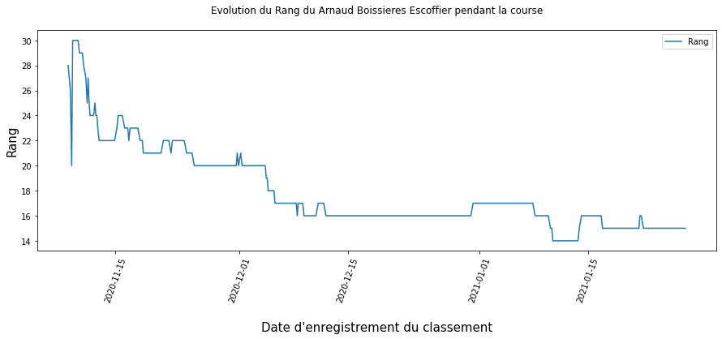

```python
# ARNAUD BOISSIERES

df_arnaud_boissieres2 = df_arnaud_boissieres.loc[df_arnaud_boissieres.Rang != 'RET']
df_arnaud_boissieres2 = df_arnaud_boissieres2.loc[df_arnaud_boissieres2.Rang != 'NL']

df_arnaud_boissieres2.index.tolist()

arnaud_boissieres2 = df_arnaud_boissieres.loc[df_arnaud_boissieres.Rang != 'RET']
arnaud_boissieres2 = arnaud_boissieres2.loc[arnaud_boissieres2.Rang != 'NL']
arnaud_boissieres2

y = arnaud_boissieres2.loc[:, 'Rang'].astype(int)
y = np.array(y)

x = df_arnaud_boissieres2.loc[:, 'date_excel_datetime']

plt.figure(figsize=(15,5))
plt.title("Evolution du Rang du Arnaud Boissieres Escoffier pendant la course\n")
plt.plot(x,y, label="Rang")
plt.xticks(rotation=70)
plt.xlabel("\nDate d'enregistrement du classement", fontsize=15)
plt.ylabel("Rang", fontsize=15)
plt.legend()
plt.show()
```

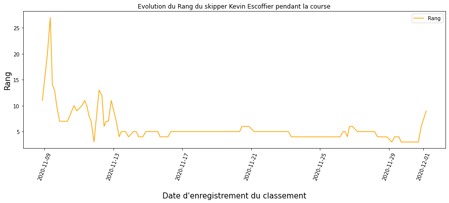

```python
# KEVIN EXCOFFIER

df_kevin_escoffier2 = df_kevin_escoffier.loc[df_kevin_escoffier.Rang != 'RET']
df_kevin_escoffier2 = df_kevin_escoffier2.loc[df_kevin_escoffier2.Rang != 'NL']

df_kevin_escoffier2.index.tolist()

kevin_escoffier2 = df_kevin_escoffier.loc[df_kevin_escoffier.Rang != 'RET']
kevin_escoffier2 = kevin_escoffier2.loc[kevin_escoffier2.Rang != 'NL']
kevin_escoffier2

y = kevin_escoffier2.loc[:, 'Rang'].astype(int)
y = np.array(y)

x = df_kevin_escoffier2.loc[:, 'date_excel_datetime']

plt.figure(figsize=(15,5))
plt.title("Evolution du Rang du skipper Kevin Escoffier pendant la course")
plt.plot(x,y, label="Rang", color="orange")
plt.xticks(rotation=70)
plt.xlabel("\nDate d'enregistrement du classement", fontsize=15)
plt.ylabel("Rang", fontsize=15)
plt.legend()
```

## Analyse de série temporelle

### Application du modèle ARIMA

```python
df_kevin_escoffier2 = df_kevin_escoffier.loc[df_kevin_escoffier.Rang != 'RET']
df_kevin_escoffier2 = df_kevin_escoffier2.loc[df_kevin_escoffier2.Rang != 'NL']

df_kevin_escoffier2.index.tolist()

kevin_escoffier2 = df_kevin_escoffier.loc[df_kevin_escoffier.Rang != 'RET']
kevin_escoffier2 = kevin_escoffier2.loc[kevin_escoffier2.Rang != 'NL']
kevin_escoffier2

y = kevin_escoffier2.loc[:, 'Rang'].astype(int)
y = np.array(y)

x = df_kevin_escoffier2.loc[:, 'date_excel_datetime']

y_rang = kevin_escoffier2.loc[:, 'Rang'].astype(int)

x_date = df_kevin_escoffier2.loc[:, 'date_excel_datetime']
```

#### On applique le modèle ARIMA

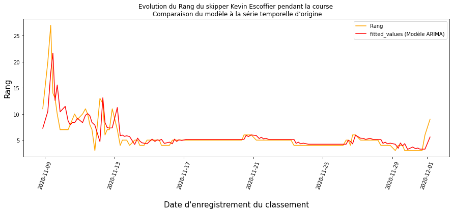

```python
boat_excoffier = pd.DataFrame({'date':x_date, 'rang':y_rang})
boat_excoffier.set_index("date", inplace = True)
boat_excoffier

from statsmodels.tsa.arima_model import ARIMA

model_excoffier = ARIMA(boat_excoffier, order=(5,0,0))
model_fit_excoffier = model_excoffier.fit(disp=0)
plt.figure(figsize=(15,5))
plt.title("Evolution du Rang du skipper Kevin Escoffier pendant la course \n Comparaison du modèle à la série temporelle d’origine")
plt.plot(x,y, label="Rang", color="orange")
plt.xticks(rotation=70)
plt.xlabel("\nDate d'enregistrement du classement", fontsize=15)
plt.ylabel("Rang", fontsize=15)
plt.plot(model_fit_excoffier.fittedvalues, color='red', label="fitted_values (Modèle ARIMA)")
plt.legend()
```

#### On visualise le rang predit par le modèle (environ 80 jour après le départ)

```
Rang =  7
```

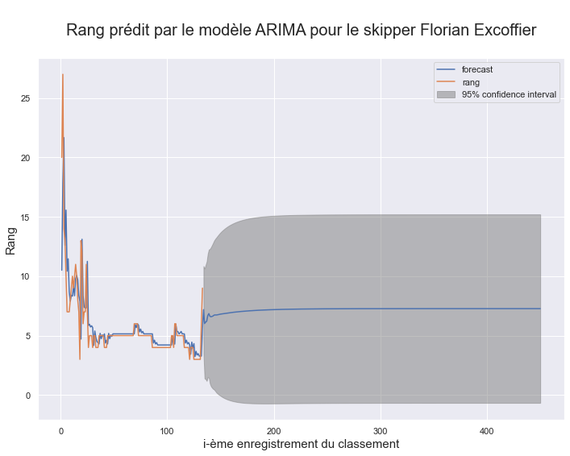

```python
fig = model_fit_excoffier.plot_predict(1,450) # environ 80 jour après le départ
plt.title("\nRang prédit par le modèle ARIMA pour le skipper Florian Excoffier\n", fontsize=20)
plt.xlabel("i-ème enregistrement du classement", fontsize=15)
plt.ylabel("Rang", fontsize=15)
print("Rang = ", int(model_fit_excoffier.predict(1,180).iloc[-1]))
```

### Conclusion

#### Avec l'aide du modèle ARIMA nous essayons de prédire le rang final du gagnant de la course Yannick Bestaven cela permettra de juger la précision du modèle dans les prédictions que ce dernier génère

```python
df_yannick_bestaven
```

|  | Rang | Numero_voile | Nat_Voile | Skipper_Bateau | Heure_Enregistrement_Classement | Latitude_Enregistrement_Classement | Longitude_Enregistrement_Classement | DP_30_min_Cap_degre | DP_30_min_Vitesse_kts | DP_30_min_VMG_kts | ... | DP_Dernier_Classement_Distance_nm | DP_24H_Cap_degre | DP_24H_Vitesse_kts | DP_24H_VMG_kts | DP_24H_Distance_nm | Distance_To_Finish_nm | Distance_To_Leader_nm | Skipper | date_excel | date_excel_datetime |
| --- | --- | --- | --- | --- | --- | --- | --- | --- | --- | --- | --- | --- | --- | --- | --- | --- | --- | --- | --- | --- | --- |
| 0 | 14 | 17 | FRA | Yannick Bestaven Maître Coq IV | 22:30:00 | 46.192222 | -4.584444 | 273.0 | 8.1 | 5.8 | ... | 58.6 | 260.0 | 5.0 | 4.7 | 117.3 | 24192.7 | 13.9 | yannick bestaven | 20201108_210000 | 2020-11-08 21:00:00 |
| 1 | 7 | 17 | FRA | Yannick Bestaven Maître Coq IV | 05:30:00 | 46.255556 | -6.654444 | 276.0 | 13.6 | 5.8 | ... | 86.0 | 264.0 | 8.6 | 7.9 | 202.0 | 24139.4 | 6.3 | yannick bestaven | 20201109_040000 | 2020-11-09 04:00:00 |
| 2 | 9 | 17 | FRA | Yannick Bestaven Maître Coq IV | 09:00:00 | 46.451389 | -7.633611 | 292.0 | 10.2 | 0.2 | ... | 42.5 | 267.0 | 10.1 | 5.5 | 241.6 | 24132.4 | 21.4 | yannick bestaven | 20201109_080000 | 2020-11-09 08:00:00 |
| 3 | 12 | 17 | FRA | Yannick Bestaven Maître Coq IV | 12:00:00 | 46.417778 | -8.080556 | 201.0 | 8.9 | 8.9 | ... | 18.4 | 268.0 | 10.8 | 5.9 | 260.1 | 24123.1 | 27.8 | yannick bestaven | 20201109_110000 | 2020-11-09 11:00:00 |
| 4 | 11 | 17 | FRA | Yannick Bestaven Maître Coq IV | 15:00:00 | 46.005556 | -8.301111 | 199.0 | 8.5 | 8.4 | ... | 26.1 | 262.0 | 11.4 | 7.1 | 273.1 | 24097.0 | 26.5 | yannick bestaven | 20201109_140000 | 2020-11-09 14:00:00 |
| ... | ... | ... | ... | ... | ... | ... | ... | ... | ... | ... | ... | ... | ... | ... | ... | ... | ... | ... | ... | ... | ... |
| 474 | 5 | 17 | FRA | Yannick Bestaven Maître Coq IV | 21:30:00 | 47.595833 | -15.841667 | 84.0 | 19.6 | 19.4 | ... | 70.9 | 57.0 | 15.1 | 14.5 | 361.8 | 578.2 | 240.3 | yannick bestaven | 20210126_210000 | 2021-01-26 21:00:00 |
| 475 | 5 | 17 | FRA | Yannick Bestaven Maître Coq IV | 04:30:00 | 47.878889 | -12.467222 | 87.0 | 21.0 | 20.6 | ... | 136.9 | 81.0 | 18.9 | 18.9 | 453.0 | 443.9 | 182.8 | yannick bestaven | 20210127_040000 | 2021-01-27 04:00:00 |
| 476 | 5 | 17 | FRA | Yannick Bestaven Maître Coq IV | 08:30:00 | 47.893611 | -10.553056 | 87.0 | 18.9 | 18.4 | ... | 77.1 | 83.0 | 19.1 | 19.1 | 457.9 | 367.8 | 182.9 | yannick bestaven | 20210127_080000 | 2021-01-27 08:00:00 |
| 477 | 5 | 17 | FRA | Yannick Bestaven Maître Coq IV | 11:30:00 | 47.850278 | -9.317500 | 95.0 | 19.4 | 19.3 | ... | 49.8 | 87.0 | 18.9 | 18.9 | 453.1 | 318.4 | 189.6 | yannick bestaven | 20210127_110000 | 2021-01-27 11:00:00 |
| 478 | 5 | 17 | FRA | Yannick Bestaven Maître Coq IV | 14:30:00 | 47.727222 | -7.989167 | 98.0 | 18.4 | 18.3 | ... | 54.4 | 91.0 | 18.6 | 18.6 | 447.2 | 264.3 | 183.7 | yannick bestaven | 20210127_140000 | 2021-01-27 14:00:00 |

479 rows × 23 columns

### On sélectionne volontairement les 350 premières lignes du DataFrame qui en comporte 479. Cela permet de comparer la prédiction du modèle par rapport à la série temporelle d'origine

```python
df_yannick_bestaven2 = df_yannick_bestaven.loc[df_yannick_bestaven.Rang != 'RET']
df_yannick_bestaven2 = df_yannick_bestaven2.loc[df_yannick_bestaven2.Rang != 'NL']

df_yannick_bestaven2.index.tolist()

yannick_bestaven2 = df_yannick_bestaven.loc[df_yannick_bestaven.Rang != 'RET']
yannick_bestaven2 = yannick_bestaven2.loc[yannick_bestaven2.Rang != 'NL']
yannick_bestaven2

y = yannick_bestaven2.loc[:350, 'Rang'].astype(int)
y = np.array(y)

x = df_yannick_bestaven2.loc[:350, 'date_excel_datetime']

y_rang = yannick_bestaven2.loc[:350, 'Rang'].astype(int)

x_date = df_yannick_bestaven2.loc[:350, 'date_excel_datetime']
```

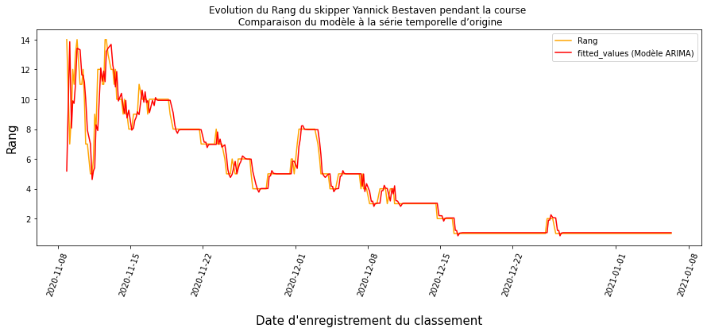

```python
boat_bestaven = pd.DataFrame({'date':x_date, 'rang':y_rang})
boat_bestaven.set_index("date", inplace = True)
boat_bestaven

from statsmodels.tsa.arima_model import ARIMA

model_bestaven = ARIMA(boat_bestaven, order=(5,0,0))
model_fit_bestaven = model_bestaven.fit(disp=0)
plt.figure(figsize=(15,5))
plt.title("Evolution du Rang du skipper Yannick Bestaven pendant la course \n Comparaison du modèle à la série temporelle d’origine")
plt.plot(x,y, label="Rang", color="orange")
plt.xticks(rotation=70)
plt.xlabel("\nDate d'enregistrement du classement", fontsize=15)
plt.ylabel("Rang", fontsize=15)
plt.plot(model_fit_bestaven.fittedvalues, color='red', label="fitted_values (Modèle ARIMA)")
plt.legend()
```

```
Rang =  4
```

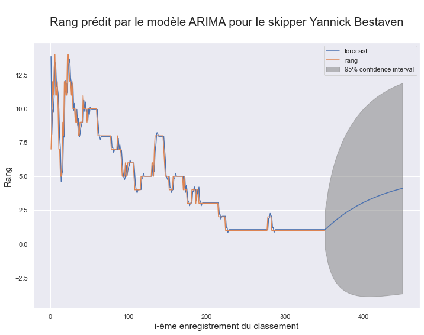

```python
fig = model_fit_bestaven.plot_predict(1,450) # environ 80 jour après le départ
plt.title("\nRang prédit par le modèle ARIMA pour le skipper Yannick Bestaven\n", fontsize=20)
plt.xlabel("i-ème enregistrement du classement", fontsize=15)
plt.ylabel("Rang", fontsize=15)
print("Rang = ", int(model_fit_bestaven.predict(1,450).iloc[-1]))
```

### Conclusion

**Le modèle prédit un Rang = 4 pour le skipper Yannick Bestaven** **La prédiction du modèle est pas très bonne car en réalité, le skipper est arrive en 1ère position** **Toutefois les prédictions du modèle ARIMA pour les 2 skippers ne slembent pas très précises au regard de l'intervalle de confiance qui est plutôt large. Cela peut s'expliquer par le fait que les signaux ne dispose d'aucune périodicité.**

### Visualisation du trajet du skipper Arnaud Boissieres pendant la course du Vendée Globle

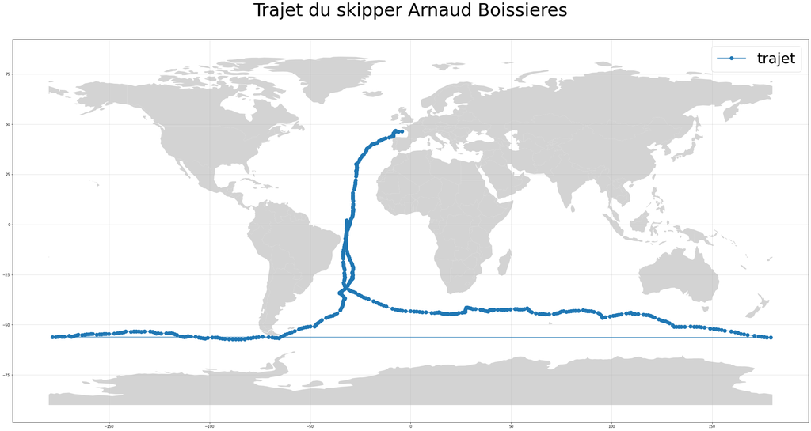

```python
long = df_arnaud_boissieres.loc[:, "Longitude_Enregistrement_Classement"].tolist()

lat = df_arnaud_boissieres.loc[:, "Latitude_Enregistrement_Classement"].tolist()


countries = gpd.read_file(gpd.datasets.get_path("naturalearth_lowres"))

# initialize an axis
fig, ax = plt.subplots(figsize=(40,30))
# plot map on axis
countries = gpd.read_file(
     gpd.datasets.get_path("naturalearth_lowres"))
countries.plot(color="lightgrey", ax=ax)

ax.plot(long, lat, marker="o",  markersize=10, label="trajet")
plt.title("Trajet du skipper Arnaud Boissieres\n", fontsize=50)
plt.legend(prop={'size': 40})
ax.grid(b=True, alpha=0.5)
plt.show()
```

##### Note : Le trajet de Arnaud Boissieresn'est pas complet car ce dernier n'avait pas fini la course avant la date du dernier classement prise en compte dans cette analyse (27 janvier 2021)

### Visualisation du trajet du skipper Kevin Excoffier pendant la course du Vendée Globle

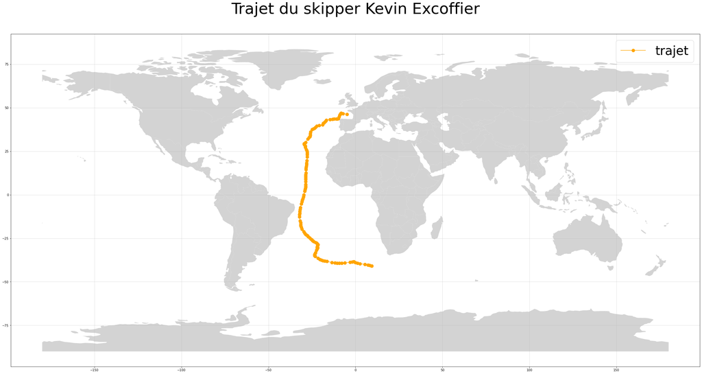

```python
long = df_kevin_escoffier.loc[:, "Longitude_Enregistrement_Classement"].tolist()

lat = df_kevin_escoffier.loc[:, "Latitude_Enregistrement_Classement"].tolist()


countries = gpd.read_file(gpd.datasets.get_path("naturalearth_lowres"))

# initialize an axis
fig, ax = plt.subplots(figsize=(40,30))
# plot map on axis
countries = gpd.read_file(
     gpd.datasets.get_path("naturalearth_lowres"))
countries.plot(color="lightgrey", ax=ax)

ax.plot(long, lat, marker="o",  markersize=10, label="trajet", color="orange")
plt.title("Trajet du skipper Kevin Excoffier\n", fontsize=50)
plt.legend(prop={'size': 40})
ax.grid(b=True, alpha=0.5)
plt.show()
```

Avec cette visualisation on peut voir que la trajet de Kevin Excoffier s'arrête dans océan atlantique. Ceci s'explique par le fait que Kevin Excoffier a abandonné la course avant la fin du Vendée Globle

### Analyse du rang en fonction de la vitesse moyenne "vmg''

Pour ce faire nous allons faire un regression linéaire simple.

```python
dfc_select = df_merge_boat_carac_last_classement_cleaned.loc[df_merge_boat_carac_last_classement_cleaned.Last_Rang != 'RET', ['Skipper','Last_Rang']]
dfc_select.Last_Rang = dfc_select.Last_Rang.astype(int)
dfc_select
```

|  | Skipper | Last_Rang |
| --- | --- | --- |
| 1 | romain attanasio | 14 |
| 2 | alexia barrier | 24 |
| 3 | yannick bestaven | 1 |
| 4 | jeremie beyou | 13 |
| 5 | arnaud boissieres | 15 |
| 6 | louis burton | 3 |
| 7 | didac costa | 20 |
| 8 | manuel cousin | 23 |
| 9 | clarisse cremer | 12 |
| 10 | charlie dalin | 2 |
| 13 | benjamin dutreux | 9 |
| 15 | clement giraud | 21 |
| 16 | pip hare | 19 |
| 17 | boris herrmann | 5 |
| 18 | ari huusela | 25 |
| 20 | jean le cam | 4 |
| 21 | stephane le diraison | 18 |
| 22 | miranda merron | 22 |
| 23 | giancarlo pedote | 8 |
| 24 | alan roura | 17 |
| 25 | thomas ruyant | 6 |
| 26 | damien seguin | 7 |
| 27 | kojiro shiraishi | 16 |
| 29 | maxime sorel | 10 |
| 31 | armel tripon | 11 |

#### On calcule la vmg moyen de chaque bâteau

```python
liste_df_sk = [df_louis_burton, df_boris_herrmann, df_jeremie_beyou ,df_thomas_ruyant, df_maxime_sorel, df_fabrice_amedeo, df_jean_le, df_alex_thomson, df_sebastien_destremau, df_pip_hare, df_kevin_escoffier, df_stephane_le, df_romain_attanasio,  df_damien_seguin, df_clement_giraud, df_samantha_davies, df_yannick_bestaven, df_giancarlo_pedote, df_kojiro_shiraishi, df_nicolas_troussel, df_manuel_cousin, df_clarisse_cremer, df_alan_roura, df_didac_costa, df_benjamin_dutreux, df_armel_tripon, df_alexia_barrier,df_isabelle_joschke,df_sebastien_simon,df_miranda_merron ,df_ari_huusela,df_charlie_dalin,df_arnaud_boissieres]
liste_nm_sk = ['louis burton', 'boris herrmann', 'jeremie beyou' , 'thomas ruyant', 'maxime sorel', 'fabrice amedeo', 'jean le cam', 'alex thomson', 'sebastien destremau', 'pip hare', 'kevin escoffier', 'stephane le diraison', 'romain attanasio', 'damien seguin', 'clement giraud', 'samantha davies', 'yannick bestaven', 'giancarlo pedote', 'kojiro shiraishi', 'nicolas troussel', 'manuel cousin', 'clarisse cremer', 'alan roura', 'didac costa', 'benjamin dutreux', 'armel tripon', 'alexia barrier', 'isabelle joschke', 'sebastien simon', 'miranda merron' , 'ari huusela', 'charlie dalin', 'arnaud boissieres']

for i in range(33):
    dfc_select.loc[dfc_select.Skipper == liste_nm_sk[i], 'mean_vmg_kts'] = round(np.mean(liste_df_sk[i]['DP_30_min_VMG_kts']), 3)
dfc_select
```

|  | Skipper | Last_Rang | mean_vmg_kts |
| --- | --- | --- | --- |
| 1 | romain attanasio | 14 | 11.362 |
| 2 | alexia barrier | 24 | 9.454 |
| 3 | yannick bestaven | 1 | 12.706 |
| 4 | jeremie beyou | 13 | 11.225 |
| 5 | arnaud boissieres | 15 | 11.085 |
| 6 | louis burton | 3 | 12.693 |
| 7 | didac costa | 20 | 10.793 |
| 8 | manuel cousin | 23 | 10.331 |
| 9 | clarisse cremer | 12 | 11.942 |
| 10 | charlie dalin | 2 | 12.657 |
| 13 | benjamin dutreux | 9 | 12.354 |
| 15 | clement giraud | 21 | 10.252 |
| 16 | pip hare | 19 | 10.825 |
| 17 | boris herrmann | 5 | 12.668 |
| 18 | ari huusela | 25 | 9.378 |
| 20 | jean le cam | 4 | 12.398 |
| 21 | stephane le diraison | 18 | 10.965 |
| 22 | miranda merron | 22 | 10.214 |
| 23 | giancarlo pedote | 8 | 12.728 |
| 24 | alan roura | 17 | 11.109 |
| 25 | thomas ruyant | 6 | 12.624 |
| 26 | damien seguin | 7 | 12.607 |
| 27 | kojiro shiraishi | 16 | 11.027 |
| 29 | maxime sorel | 10 | 12.295 |
| 31 | armel tripon | 11 | 12.206 |

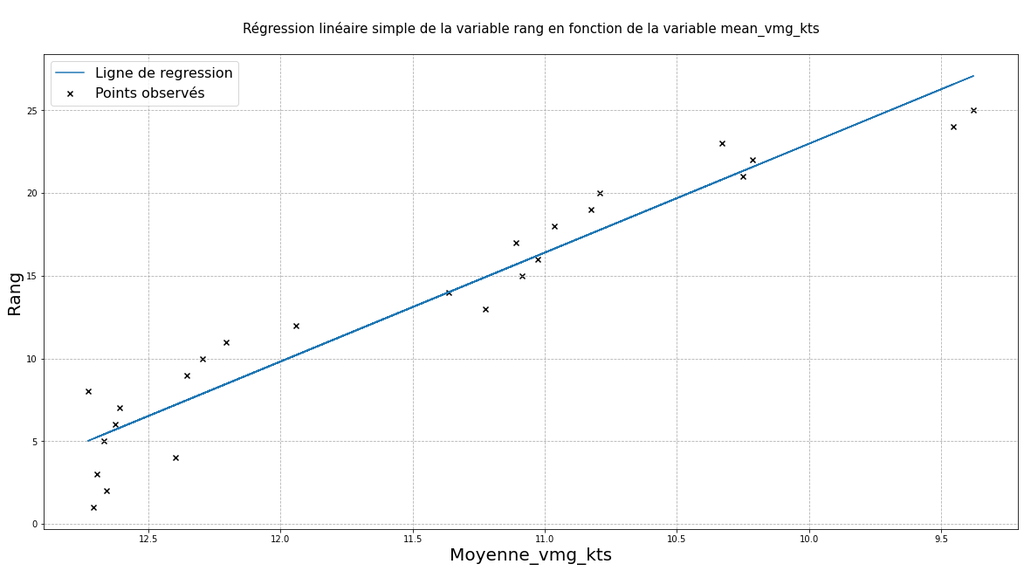

```python
x = dfc_select.mean_vmg_kts
y = dfc_select.Last_Rang

model = smf.ols('Last_Rang ~ mean_vmg_kts', dfc_select)
results = model.fit()

alpha = .05

predictions = results.get_prediction(dfc_select).summary_frame(alpha)

plt.figure(figsize=(20,10))

plt.scatter(x, y, label='Points observés', marker='x', color='black')
plt.plot(x, predictions['mean'], label='Ligne de regression')
plt.xlabel('Moyenne_vmg_kts', fontsize=20)
plt.ylabel('Rang', fontsize=20)

plt.grid(True,which="both", linestyle='--')

plt.title("\nRégression linéaire simple de la variable rang en fonction de la variable mean_vmg_kts\n", loc='center', fontsize = 15)
plt.legend(fontsize=16)

plt.gca().invert_xaxis() # permet d'inversé l'axe des x

plt.show()
```

## Analyse entre le gagnant du vendée globle (Yannick Bestaven) et le dernier (Ari Huusela)

#### 1 ère Visualisation : Distance To Finish des 2 skippers tout le long de la course

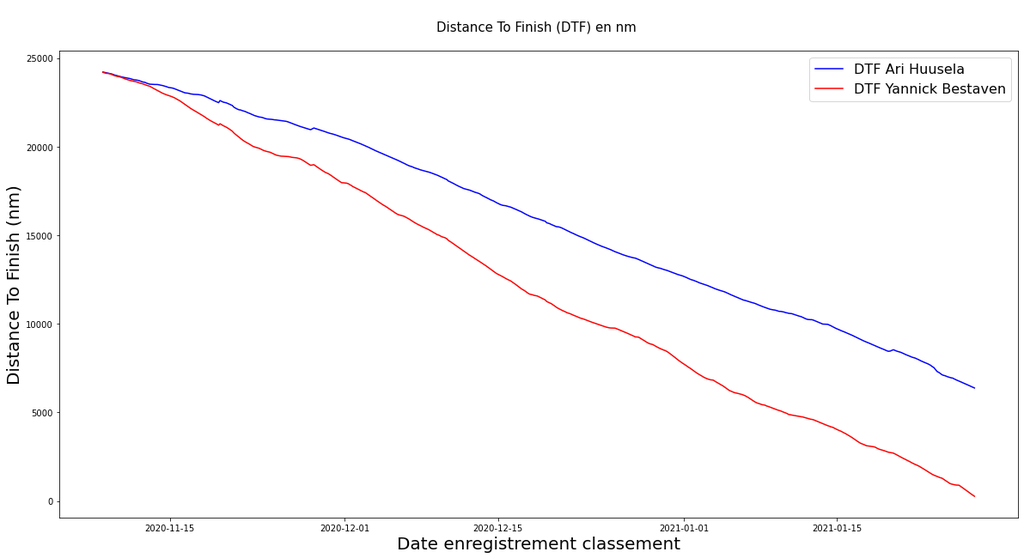

```python
plt.figure(figsize=(20,10))

plt.plot(df_ari_huusela.date_excel_datetime,df_ari_huusela['Distance_To_Finish_nm'], label="DTF Ari Huusela", color="blue")

plt.plot(df_yannick_bestaven.date_excel_datetime,df_yannick_bestaven['Distance_To_Finish_nm'], label="DTF Yannick Bestaven", color="red")

plt.xlabel('Date enregistrement classement', fontsize=20)
plt.ylabel('Distance To Finish (nm)', fontsize=20)
plt.title("\nDistance To Finish (DTF) en nm \n", loc='center', fontsize = 15)
plt.legend(fontsize=16)
```

#### 2 ème Visualisation : Trajet des deux skippers

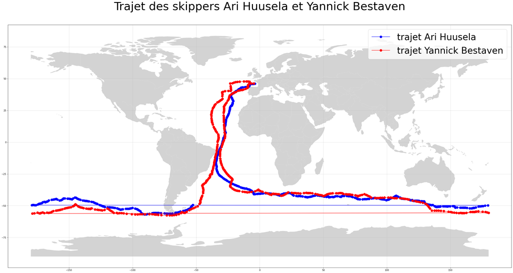

```python
long_ari_huusela = df_ari_huusela.loc[:, "Longitude_Enregistrement_Classement"].tolist()
lat_ari_huusela = df_ari_huusela.loc[:, "Latitude_Enregistrement_Classement"].tolist()

long_yannick_bestaven = df_yannick_bestaven.loc[:, "Longitude_Enregistrement_Classement"].tolist()
lat_yannick_bestaven = df_yannick_bestaven.loc[:, "Latitude_Enregistrement_Classement"].tolist()



countries = gpd.read_file(gpd.datasets.get_path("naturalearth_lowres"))

# initialize an axis
fig, ax = plt.subplots(figsize=(40,30))
# plot map on axis
countries = gpd.read_file(
     gpd.datasets.get_path("naturalearth_lowres"))
countries.plot(color="lightgrey", ax=ax)

ax.plot(long_ari_huusela, lat_ari_huusela, marker="o",  markersize=10, label="trajet Ari Huusela", color="blue")
ax.plot(long_yannick_bestaven, lat_yannick_bestaven, marker="o",  markersize=10, label="trajet Yannick Bestaven", color="red")
plt.title("Trajet des skippers Ari Huusela et Yannick Bestaven\n", fontsize=50)
plt.legend(prop={'size': 40})
ax.grid(b=True, alpha=0.5)
plt.show()
```

##### Note : Le trajet de Ari Huusela n'est pas complet car à la date du dernier classement pris en compte dans cette étude (27 janvier 2021) Ari Huusela n'avait pas encore atteint l'arrivé de la course contrairement à Yannick Bestaven qui a été bien plus rapide que Ari Huusela pour finir la course

#### 3 ème Visualisation : Visualisation de la vitesse utile (VMG) entre les 2 deux skippers

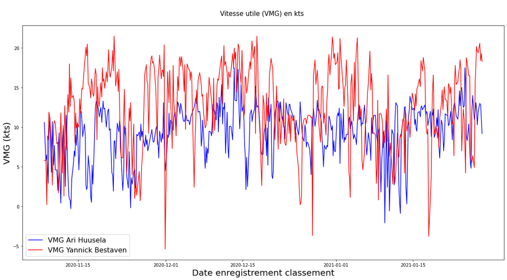

```python
plt.figure(figsize=(20,10))

plt.plot(df_ari_huusela.date_excel_datetime,df_ari_huusela['DP_30_min_VMG_kts'], label="VMG Ari Huusela", color="blue")

plt.plot(df_yannick_bestaven.date_excel_datetime,df_yannick_bestaven['DP_30_min_VMG_kts'], label="VMG Yannick Bestaven", color="red")

plt.xlabel('Date enregistrement classement', fontsize=20)
plt.ylabel('VMG (kts)', fontsize=20)
plt.title("\nVitesse utile (VMG) en kts \n", loc='center', fontsize = 15)
plt.legend(fontsize=16)
```

### Analyse de l'influence de la présence d'un foils sur la VMG des skippers

```python
dfc_select1 = df_merge_boat_carac_last_classement_cleaned.loc[df_merge_boat_carac_last_classement_cleaned.Last_Rang != 'RET', ['Skipper','Last_Rang', 'Presence_foils']]
dfc_select1.Last_Rang = dfc_select.Last_Rang.astype(int)
dfc_select1
```

|  | Skipper | Last_Rang | Presence_foils |
| --- | --- | --- | --- |
| 1 | romain attanasio | 14 | 0 |
| 2 | alexia barrier | 24 | 0 |
| 3 | yannick bestaven | 1 | 1 |
| 4 | jeremie beyou | 13 | 1 |
| 5 | arnaud boissieres | 15 | 1 |
| 6 | louis burton | 3 | 1 |
| 7 | didac costa | 20 | 0 |
| 8 | manuel cousin | 23 | 0 |
| 9 | clarisse cremer | 12 | 0 |
| 10 | charlie dalin | 2 | 1 |
| 13 | benjamin dutreux | 9 | 0 |
| 15 | clement giraud | 21 | 0 |
| 16 | pip hare | 19 | 0 |
| 17 | boris herrmann | 5 | 1 |
| 18 | ari huusela | 25 | 0 |
| 20 | jean le cam | 4 | 0 |
| 21 | stephane le diraison | 18 | 1 |
| 22 | miranda merron | 22 | 0 |
| 23 | giancarlo pedote | 8 | 1 |
| 24 | alan roura | 17 | 1 |
| 25 | thomas ruyant | 6 | 1 |
| 26 | damien seguin | 7 | 0 |
| 27 | kojiro shiraishi | 16 | 1 |
| 29 | maxime sorel | 10 | 0 |
| 31 | armel tripon | 11 | 1 |

```python
liste_df_sk = [df_louis_burton, df_boris_herrmann, df_jeremie_beyou ,df_thomas_ruyant, df_maxime_sorel, df_fabrice_amedeo, df_jean_le, df_alex_thomson, df_sebastien_destremau, df_pip_hare, df_kevin_escoffier, df_stephane_le, df_romain_attanasio,  df_damien_seguin, df_clement_giraud, df_samantha_davies, df_yannick_bestaven, df_giancarlo_pedote, df_kojiro_shiraishi, df_nicolas_troussel, df_manuel_cousin, df_clarisse_cremer, df_alan_roura, df_didac_costa, df_benjamin_dutreux, df_armel_tripon, df_alexia_barrier,df_isabelle_joschke,df_sebastien_simon,df_miranda_merron ,df_ari_huusela,df_charlie_dalin,df_arnaud_boissieres]
liste_nm_sk = ['louis burton', 'boris herrmann', 'jeremie beyou' , 'thomas ruyant', 'maxime sorel', 'fabrice amedeo', 'jean le cam', 'alex thomson', 'sebastien destremau', 'pip hare', 'kevin escoffier', 'stephane le diraison', 'romain attanasio', 'damien seguin', 'clement giraud', 'samantha davies', 'yannick bestaven', 'giancarlo pedote', 'kojiro shiraishi', 'nicolas troussel', 'manuel cousin', 'clarisse cremer', 'alan roura', 'didac costa', 'benjamin dutreux', 'armel tripon', 'alexia barrier', 'isabelle joschke', 'sebastien simon', 'miranda merron' , 'ari huusela', 'charlie dalin', 'arnaud boissieres']

for i in range(33):
    dfc_select1.loc[dfc_select1.Skipper == liste_nm_sk[i], 'mean_vmg_kts'] = round(np.mean(liste_df_sk[i]['DP_30_min_VMG_kts']), 3)
dfc_select1
```

|  | Skipper | Last_Rang | Presence_foils | mean_vmg_kts |
| --- | --- | --- | --- | --- |
| 1 | romain attanasio | 14 | 0 | 11.362 |
| 2 | alexia barrier | 24 | 0 | 9.454 |
| 3 | yannick bestaven | 1 | 1 | 12.706 |
| 4 | jeremie beyou | 13 | 1 | 11.225 |
| 5 | arnaud boissieres | 15 | 1 | 11.085 |
| 6 | louis burton | 3 | 1 | 12.693 |
| 7 | didac costa | 20 | 0 | 10.793 |
| 8 | manuel cousin | 23 | 0 | 10.331 |
| 9 | clarisse cremer | 12 | 0 | 11.942 |
| 10 | charlie dalin | 2 | 1 | 12.657 |
| 13 | benjamin dutreux | 9 | 0 | 12.354 |
| 15 | clement giraud | 21 | 0 | 10.252 |
| 16 | pip hare | 19 | 0 | 10.825 |
| 17 | boris herrmann | 5 | 1 | 12.668 |
| 18 | ari huusela | 25 | 0 | 9.378 |
| 20 | jean le cam | 4 | 0 | 12.398 |
| 21 | stephane le diraison | 18 | 1 | 10.965 |
| 22 | miranda merron | 22 | 0 | 10.214 |
| 23 | giancarlo pedote | 8 | 1 | 12.728 |
| 24 | alan roura | 17 | 1 | 11.109 |
| 25 | thomas ruyant | 6 | 1 | 12.624 |
| 26 | damien seguin | 7 | 0 | 12.607 |
| 27 | kojiro shiraishi | 16 | 1 | 11.027 |
| 29 | maxime sorel | 10 | 0 | 12.295 |
| 31 | armel tripon | 11 | 1 | 12.206 |

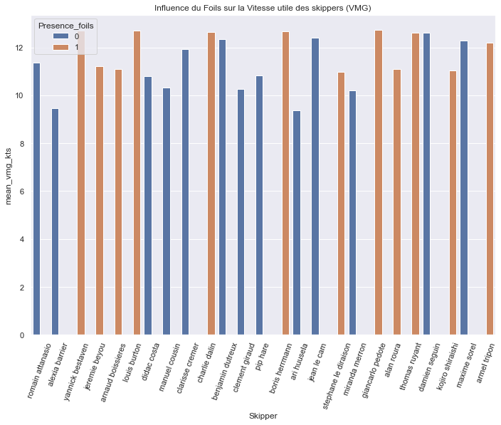

```python
sns.set(rc={'figure.figsize':(11.7,8.27)})
plt.xticks(rotation=70)
ax = sns.barplot(x="Skipper", y="mean_vmg_kts", hue="Presence_foils", data=dfc_select1).set_title("Influence du Foils sur la Vitesse utile des skippers (VMG)")
```

#### Note :

- 1 = présence du foils
- 0 = non présence du foils

### Analyse de l'influence de la présence d'un foils sur le rang des skippers

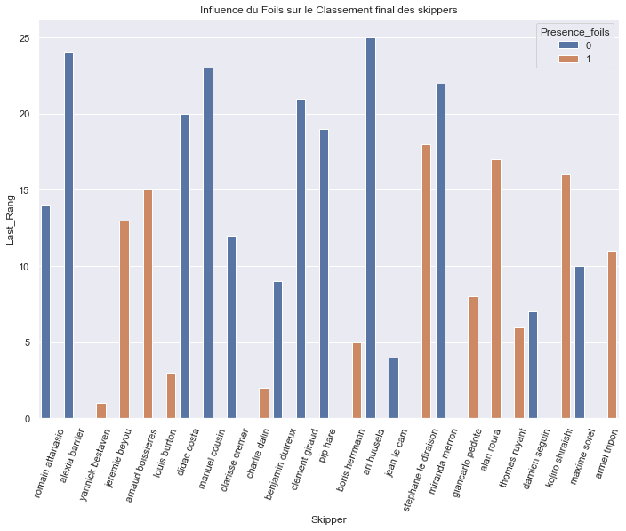

```python
sns.set(rc={'figure.figsize':(11.7,8.27)})
plt.xticks(rotation=70)
ax = sns.barplot(x="Skipper", y="Last_Rang", hue="Presence_foils", data=dfc_select1).set_title("Influence du Foils sur le Classement final des skippers")
```

#### Note :

- 1 = présence du foils
- 0 = non présence du foils

#### Interprétation :

**On constate sur le graphe que les bâteaux disposant d'un foils occupe les meilleures places. En effet les 3 bâteaux arrivés en premiers disposent d'un foils. De plus les 7 bâteaux qui sont arrivés en dernier sont des bâteaux ne disposant pas de foils**

```python
dfc_select1
```

|  | Skipper | Last_Rang | Presence_foils | mean_vmg_kts |
| --- | --- | --- | --- | --- |
| 1 | romain attanasio | 14 | 0 | 11.362 |
| 2 | alexia barrier | 24 | 0 | 9.454 |
| 3 | yannick bestaven | 1 | 1 | 12.706 |
| 4 | jeremie beyou | 13 | 1 | 11.225 |
| 5 | arnaud boissieres | 15 | 1 | 11.085 |
| 6 | louis burton | 3 | 1 | 12.693 |
| 7 | didac costa | 20 | 0 | 10.793 |
| 8 | manuel cousin | 23 | 0 | 10.331 |
| 9 | clarisse cremer | 12 | 0 | 11.942 |
| 10 | charlie dalin | 2 | 1 | 12.657 |
| 13 | benjamin dutreux | 9 | 0 | 12.354 |
| 15 | clement giraud | 21 | 0 | 10.252 |
| 16 | pip hare | 19 | 0 | 10.825 |
| 17 | boris herrmann | 5 | 1 | 12.668 |
| 18 | ari huusela | 25 | 0 | 9.378 |
| 20 | jean le cam | 4 | 0 | 12.398 |
| 21 | stephane le diraison | 18 | 1 | 10.965 |
| 22 | miranda merron | 22 | 0 | 10.214 |
| 23 | giancarlo pedote | 8 | 1 | 12.728 |
| 24 | alan roura | 17 | 1 | 11.109 |
| 25 | thomas ruyant | 6 | 1 | 12.624 |
| 26 | damien seguin | 7 | 0 | 12.607 |
| 27 | kojiro shiraishi | 16 | 1 | 11.027 |
| 29 | maxime sorel | 10 | 0 | 12.295 |
| 31 | armel tripon | 11 | 1 | 12.206 |

### Test de significativité de la présence d'un "foils" et de la "vmg" sur le classement final des skippers de la course

**Pour ce faire nous allons réaliser une regression linéaire multiple**

#### $\hat{y} =\hat\theta_{0}+\hat\theta_{1} \times MeanVMG +\hat\theta_{2} \times PresenceFoils$

```python
Y = dfc_select1['Last_Rang']

Mean_vmg_kts_X1 = dfc_select1['mean_vmg_kts'].tolist()
Presence_foils_X2 = dfc_select1['Presence_foils'].tolist()

X=[Mean_vmg_kts_X1, Presence_foils_X2]

def reg_m(y, x):
    ones = np.ones(len(x[0]))
    X = sm.add_constant(np.column_stack((x[0], ones)))
    for ele in x[1:]:
        X = sm.add_constant(np.column_stack((ele, X)))
    results = sm.OLS(y, X).fit()
    return results

reg_m(Y, X).summary()
```

OLS Regression Results

| Dep. Variable: | Last_Rang | R-squared: | 0.924 |
| --- | --- | --- | --- |
| Model: | OLS | Adj. R-squared: | 0.917 |
| Method: | Least Squares | F-statistic: | 133.9 |
| Date: | Sun, 07 Nov 2021 | Prob (F-statistic): | 4.83e-13 |
| Time: | 11:50:11 | Log-Likelihood: | -52.639 |
| No. Observations: | 25 | AIC: | 111.3 |
| Df Residuals: | 22 | BIC: | 114.9 |
| Df Model: | 2 |  |  |
| Covariance Type: | nonrobust |  |  |

|  | coef | std err | t | P>\|t\| | [0.025 | 0.975] |
| --- | --- | --- | --- | --- | --- | --- |
| x1 | -0.9252 | 0.934 | -0.991 | 0.333 | -2.862 | 1.012 |
| x2 | -6.4026 | 0.444 | -14.412 | 0.000 | -7.324 | -5.481 |
| const | 87.1756 | 4.963 | 17.566 | 0.000 | 76.884 | 97.468 |

| Omnibus: | 1.671 | Durbin-Watson: | 1.371 |
| --- | --- | --- | --- |
| Prob(Omnibus): | 0.434 | Jarque-Bera (JB): | 1.449 |
| Skew: | -0.461 | Prob(JB): | 0.485 |
| Kurtosis: | 2.264 | Cond. No. | 137. |

Warnings:  
[1] Standard Errors assume that the covariance matrix of the errors is correctly specified.

### Le coefficient de détermination de la regression est de :

$R^2 = 0.924$

### Pour un risque $\alpha = 5\%$ (avec $\alpha = 0.05$)

### Si nous passons par la $p-valeur$ nous obtenons :

### - $p_{\hat\theta_{2}} = 0.33 $ . Puisque $p_{\hat\theta_{2}}>\alpha$ donc le coéfficient associé à *foils* n'est pas significatif

### En revanche avec le résultat retourné (i.e 0.0) par le modèle OLS de la librairie statsmodel nous ne pouvons rien conclure sur la significativité de la variable mean_vmg*kts. Pour connaître la réel p-valeur de $p*{\hat\theta*{1}}$ il faut calculer cela à "la main". Toutefois, la librairie retourne 0.0 car il s'avère que cette valeur est très très petite et se rapproche de 0. On en déduit donc $p*{\hat\theta*{2}}$ est très inférieur à $\alpha$, ainsi puisque $p*{\hat\theta_{2}} <<\alpha$ donc le coéfficient associé à mean_vmg_kts est significatif.

### La conclusion est alors la suivante : Le foils n'a que peu d'influence sur le classement final tandis que la vmg moyenne de chaque bâteau à une forte influence sur le classement. Un bâteau avec une vitesse utile vmg très élevé se trouvera logiquement dans les meilleurs du classement final de la course

### Visualisation du temps de course de chaque skipper

Pour cela on s'appuie sur les résulats du dernier classement (classement final de la course)

```python
# On sélectionne uniquement les skippers qui n'ont pas abandonné la course

dfclassement_select = boat_last_classement.loc[boat_last_classement.Last_Rang != 'RET', ['Skipper', 'Last_Rang','Temps_Course_s', 'Fond_Distance_nm']]
dfclassement_select
```

|  | Skipper | Last_Rang | Temps_Course_s | Fond_Distance_nm |
| --- | --- | --- | --- | --- |
| 1 | yannick bestaven | 1 | 6925486.0 | 28583.8 |
| 2 | charlie dalin | 2 | 6934547.0 | 29135.0 |
| 3 | louis burton | 3 | 6949512.0 | 28650.0 |
| 4 | jean le | 4 | 6961495.0 | 27501.5 |
| 5 | boris herrmann | 5 | 6965985.0 | 28448.5 |
| 6 | thomas ruyant | 6 | 6967321.0 | 29175.5 |
| 7 | damien seguin | 7 | 6991100.0 | 27512.3 |
| 8 | giancarlo pedote | 8 | 6993740.0 | 28489.9 |
| 9 | benjamin dutreux | 9 | 7069520.0 | 27832.5 |
| 10 | maxime sorel | 10 | 7137015.0 | 27346.9 |
| 11 | armel tripon | 11 | 7326470.0 | 28315.2 |
| 12 | clarisse cremer | 12 | 7525465.0 | 27697.1 |
| 13 | jeremie beyou | 13 | 7757758.0 | 29728.5 |
| 14 | romain attanasio | 14 | 7785962.0 | 27597.0 |
| 15 | arnaud boissieres | 15 | 8188566.0 | 28456.7 |
| 16 | kojiro shiraishi | 16 | 8199176.0 | 29067.7 |
| 17 | alan roura | 17 | 8230196.0 | 28603.3 |
| 18 | stephane le | 18 | 8237760.0 | 28663.5 |
| 19 | pip hare | 19 | 8249850.0 | 27976.9 |
| 20 | didac costa | 20 | 8404023.0 | 28172.7 |
| 21 | clement giraud | 21 | 8626111.0 | 28137.8 |
| 22 | miranda merron | 22 | 8758611.0 | 27656.2 |
| 23 | manuel cousin | 23 | 8964940.0 | 29115.7 |
| 24 | alexia barrier | 24 | 9651824.0 | 28170.7 |
| 25 | ari huusela | 25 | 10088146.0 | 29122.0 |

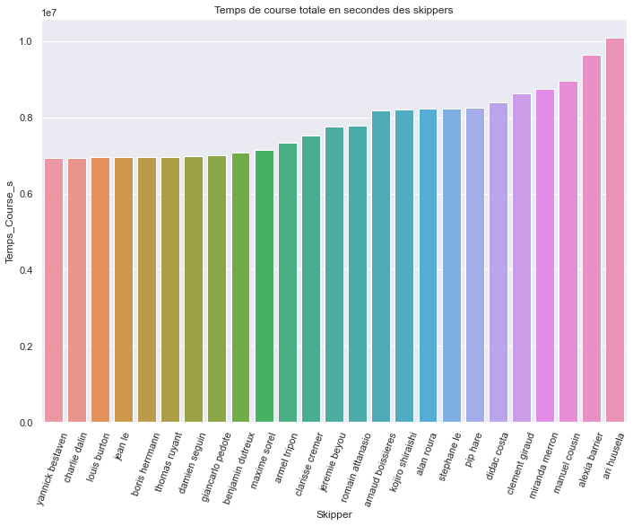

```python
sns.set(rc={'figure.figsize':(11.7,8.27)})
plt.xticks(rotation=70)
ax = sns.barplot(x="Skipper", y="Temps_Course_s", data=dfclassement_select).set_title("Temps de course totale en secondes des skippers")
```

### Visualisation de la distance totale de course de chaque skipper

Pour cela on s'appuie sur les résulats du dernier classement (classement final de la course)

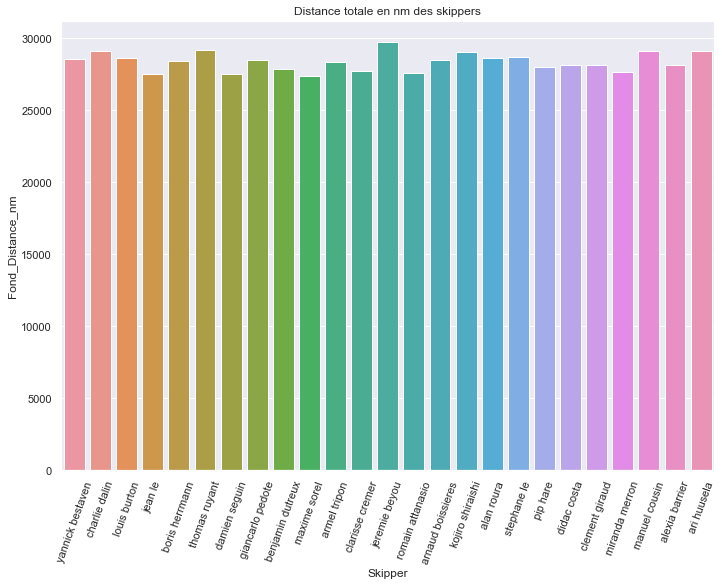

```python
sns.set(rc={'figure.figsize':(11.7,8.27)})
plt.xticks(rotation=70)
ax = sns.barplot(x="Skipper", y="Fond_Distance_nm", data=dfclassement_select).set_title("Distance totale en nm des skippers")
```

### Visualisation de la distance totale de course en fonction du rang de chaque skipper

Pour cela on s'appuie sur les résulats du dernier classement (classement final de la course)

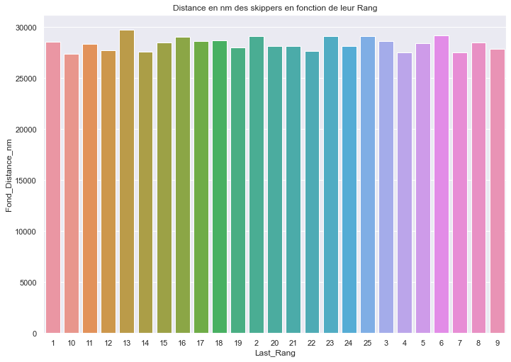

```python
sns.set(rc={'figure.figsize':(11.7,8.27)})
ax = sns.barplot(x="Last_Rang", y="Fond_Distance_nm", data=dfclassement_select).set_title("Distance en nm des skippers en fonction de leur Rang")
```

### Analyse des caractéristiques des bâteaux

#### On cherche à observer s'il existe des bâteaux qui ont une conception similaire en analysant les caractéristiques techniques de chaque bâteaux

Pour ce faire nous allons réaliser un K-means pour visualiser des clusters de bâteaux ayant des caractéristiques techniques similaires

```python
df_boat_select = boat_carac[["Longueur_m", "Largeur_m", "Tirant_eau_m", "Deplacement_poids_tonnes", "Presence_foils", "Hauteur_mat_m", "Voile_quille", "Surface_voiles_au_pres_m2", "Surface_voiles_au_portant_m2"]]
df_boat_select.reset_index(drop=True, inplace=True)
df_boat_select
```

| Nom Bateau | Longueur_m | Largeur_m | Tirant_eau_m | Deplacement_poids_tonnes | Presence_foils | Hauteur_mat_m | Voile_quille | Surface_voiles_au_pres_m2 | Surface_voiles_au_portant_m2 |
| --- | --- | --- | --- | --- | --- | --- | --- | --- | --- |
| 0 | 18.28 | 5.85 | 4.5 | 7.0 | 1 | 29.0 | monotype | 320.0 | 570.0 |
| 1 | 18.28 | 5.80 | 4.5 | 9.0 | 0 | 28.0 | acier | 280.0 | 560.0 |
| 2 | 18.28 | 5.54 | 4.5 | 9.0 | 0 | 29.0 | acier | 260.0 | 580.0 |
| 3 | 18.28 | 5.80 | 4.5 | 8.0 | 1 | 29.0 | acier | 310.0 | 550.0 |
| 4 | 18.28 | 5.85 | 4.5 | 8.0 | 1 | 29.0 | acier | 320.0 | 600.0 |
| 5 | 18.28 | 5.65 | 4.5 | 7.9 | 1 | 29.0 | basculante avec vérin | 300.0 | 610.0 |
| 6 | 18.28 | 5.80 | 4.5 | 7.6 | 1 | 28.0 | acier | 300.0 | 600.0 |
| 7 | 18.28 | 5.30 | 4.5 | 8.9 | 0 | 26.0 | acier | 240.0 | 470.0 |
| 8 | 18.28 | 5.80 | 4.5 | 9.0 | 0 | 28.5 | basculante avec vérin | 270.0 | 560.0 |
| 9 | 18.28 | 5.70 | 4.5 | 7.7 | 0 | 29.0 | acier | 340.0 | 570.0 |
| 10 | 18.28 | 5.85 | 4.5 | 8.0 | 1 | 29.0 | acier | 350.0 | 560.0 |
| 11 | 18.28 | 5.70 | 4.5 | 7.8 | 1 | 27.0 | acier | 300.0 | 600.0 |
| 12 | 18.28 | 5.60 | 4.5 | 8.5 | 0 | 29.0 | acier | 250.0 | 650.0 |
| 13 | 18.28 | 5.85 | 4.5 | 8.0 | 0 | 29.0 | acier | 300.0 | 700.0 |
| 14 | 18.28 | 5.50 | 4.5 | 8.1 | 1 | 27.4 | acier | 300.0 | 600.0 |
| 15 | 18.28 | 5.75 | 4.5 | 8.5 | 0 | 29.0 | acier | 300.0 | 620.0 |
| 16 | 18.28 | 5.70 | 4.5 | 9.0 | 0 | 29.0 | carbone | 300.0 | 580.0 |
| 17 | 18.28 | 5.70 | 4.5 | 7.6 | 1 | 29.0 | acier | 290.0 | 490.0 |
| 18 | 18.28 | 5.80 | 4.5 | 8.5 | 0 | 28.0 | acier | 270.0 | 580.0 |
| 19 | 18.28 | 5.60 | 4.5 | 7.7 | 1 | 27.0 | acier | 300.0 | 650.0 |
| 20 | 18.28 | 5.90 | 4.5 | 8.0 | 0 | 28.0 | acier | 300.0 | 620.0 |
| 21 | 18.28 | 5.84 | 4.5 | 8.5 | 1 | 28.0 | monotype | 300.0 | 550.0 |
| 22 | 18.28 | 5.50 | 4.5 | 8.5 | 0 | 28.0 | carbone | 330.0 | 600.0 |
| 23 | 18.28 | 5.80 | 4.5 | 8.0 | 1 | 29.0 | acier | 300.0 | 600.0 |
| 24 | 18.28 | 5.90 | 4.5 | 8.5 | 1 | 27.0 | carbone | 290.0 | 580.0 |
| 25 | 18.28 | 5.85 | 4.5 | 8.0 | 1 | 29.0 | acier | 350.0 | 560.0 |
| 26 | 18.28 | 5.85 | 4.5 | 8.5 | 0 | 29.0 | acier | 350.0 | 610.0 |
| 27 | 18.28 | 5.85 | 4.5 | 8.0 | 1 | 29.0 | acier | 320.0 | 580.0 |
| 28 | 18.28 | 5.70 | 4.5 | 8.0 | 0 | 29.0 | Inox usiné | 260.0 | 600.0 |
| 29 | 18.28 | 5.50 | 4.5 | 7.7 | 0 | 29.0 | acier | 365.0 | 700.0 |
| 30 | 18.28 | 5.40 | 4.5 | 7.7 | 1 | 29.0 | acier | 330.0 | 630.0 |
| 31 | 18.28 | 5.50 | 4.5 | 7.8 | 1 | 28.0 | acier | 270.0 | 535.0 |
| 32 | 18.28 | 5.70 | 4.5 | 7.9 | 1 | 27.3 | carbone | 270.0 | 535.0 |

### One hot encoding de la variable Voile_quille

```python
voile_quille_encoded = pd.get_dummies(df_boat_select.Voile_quille, prefix='Voile_quille')

# Get one hot encoding of columns "Voile_quille"
voile_quille_encoded = pd.get_dummies(df_boat_select.Voile_quille, prefix='Voile_quille')

# Drop column Voile_quille as it is now encoded
df_boat_select = df_boat_select.drop('Voile_quille', axis = 1)

# Join the encoded df
df_boat_select = df_boat_select.join(voile_quille_encoded)
df_boat_select
```

|  | Longueur_m | Largeur_m | Tirant_eau_m | Deplacement_poids_tonnes | Presence_foils | Hauteur_mat_m | Surface_voiles_au_pres_m2 | Surface_voiles_au_portant_m2 | Voile_quille_Inox usiné | Voile_quille_acier | Voile_quille_basculante avec vérin | Voile_quille_carbone | Voile_quille_monotype |
| --- | --- | --- | --- | --- | --- | --- | --- | --- | --- | --- | --- | --- | --- |
| 0 | 18.28 | 5.85 | 4.5 | 7.0 | 1 | 29.0 | 320.0 | 570.0 | 0 | 0 | 0 | 0 | 1 |
| 1 | 18.28 | 5.80 | 4.5 | 9.0 | 0 | 28.0 | 280.0 | 560.0 | 0 | 1 | 0 | 0 | 0 |
| 2 | 18.28 | 5.54 | 4.5 | 9.0 | 0 | 29.0 | 260.0 | 580.0 | 0 | 1 | 0 | 0 | 0 |
| 3 | 18.28 | 5.80 | 4.5 | 8.0 | 1 | 29.0 | 310.0 | 550.0 | 0 | 1 | 0 | 0 | 0 |
| 4 | 18.28 | 5.85 | 4.5 | 8.0 | 1 | 29.0 | 320.0 | 600.0 | 0 | 1 | 0 | 0 | 0 |
| 5 | 18.28 | 5.65 | 4.5 | 7.9 | 1 | 29.0 | 300.0 | 610.0 | 0 | 0 | 1 | 0 | 0 |
| 6 | 18.28 | 5.80 | 4.5 | 7.6 | 1 | 28.0 | 300.0 | 600.0 | 0 | 1 | 0 | 0 | 0 |
| 7 | 18.28 | 5.30 | 4.5 | 8.9 | 0 | 26.0 | 240.0 | 470.0 | 0 | 1 | 0 | 0 | 0 |
| 8 | 18.28 | 5.80 | 4.5 | 9.0 | 0 | 28.5 | 270.0 | 560.0 | 0 | 0 | 1 | 0 | 0 |
| 9 | 18.28 | 5.70 | 4.5 | 7.7 | 0 | 29.0 | 340.0 | 570.0 | 0 | 1 | 0 | 0 | 0 |
| 10 | 18.28 | 5.85 | 4.5 | 8.0 | 1 | 29.0 | 350.0 | 560.0 | 0 | 1 | 0 | 0 | 0 |
| 11 | 18.28 | 5.70 | 4.5 | 7.8 | 1 | 27.0 | 300.0 | 600.0 | 0 | 1 | 0 | 0 | 0 |
| 12 | 18.28 | 5.60 | 4.5 | 8.5 | 0 | 29.0 | 250.0 | 650.0 | 0 | 1 | 0 | 0 | 0 |
| 13 | 18.28 | 5.85 | 4.5 | 8.0 | 0 | 29.0 | 300.0 | 700.0 | 0 | 1 | 0 | 0 | 0 |
| 14 | 18.28 | 5.50 | 4.5 | 8.1 | 1 | 27.4 | 300.0 | 600.0 | 0 | 1 | 0 | 0 | 0 |
| 15 | 18.28 | 5.75 | 4.5 | 8.5 | 0 | 29.0 | 300.0 | 620.0 | 0 | 1 | 0 | 0 | 0 |
| 16 | 18.28 | 5.70 | 4.5 | 9.0 | 0 | 29.0 | 300.0 | 580.0 | 0 | 0 | 0 | 1 | 0 |
| 17 | 18.28 | 5.70 | 4.5 | 7.6 | 1 | 29.0 | 290.0 | 490.0 | 0 | 1 | 0 | 0 | 0 |
| 18 | 18.28 | 5.80 | 4.5 | 8.5 | 0 | 28.0 | 270.0 | 580.0 | 0 | 1 | 0 | 0 | 0 |
| 19 | 18.28 | 5.60 | 4.5 | 7.7 | 1 | 27.0 | 300.0 | 650.0 | 0 | 1 | 0 | 0 | 0 |
| 20 | 18.28 | 5.90 | 4.5 | 8.0 | 0 | 28.0 | 300.0 | 620.0 | 0 | 1 | 0 | 0 | 0 |
| 21 | 18.28 | 5.84 | 4.5 | 8.5 | 1 | 28.0 | 300.0 | 550.0 | 0 | 0 | 0 | 0 | 1 |
| 22 | 18.28 | 5.50 | 4.5 | 8.5 | 0 | 28.0 | 330.0 | 600.0 | 0 | 0 | 0 | 1 | 0 |
| 23 | 18.28 | 5.80 | 4.5 | 8.0 | 1 | 29.0 | 300.0 | 600.0 | 0 | 1 | 0 | 0 | 0 |
| 24 | 18.28 | 5.90 | 4.5 | 8.5 | 1 | 27.0 | 290.0 | 580.0 | 0 | 0 | 0 | 1 | 0 |
| 25 | 18.28 | 5.85 | 4.5 | 8.0 | 1 | 29.0 | 350.0 | 560.0 | 0 | 1 | 0 | 0 | 0 |
| 26 | 18.28 | 5.85 | 4.5 | 8.5 | 0 | 29.0 | 350.0 | 610.0 | 0 | 1 | 0 | 0 | 0 |
| 27 | 18.28 | 5.85 | 4.5 | 8.0 | 1 | 29.0 | 320.0 | 580.0 | 0 | 1 | 0 | 0 | 0 |
| 28 | 18.28 | 5.70 | 4.5 | 8.0 | 0 | 29.0 | 260.0 | 600.0 | 1 | 0 | 0 | 0 | 0 |
| 29 | 18.28 | 5.50 | 4.5 | 7.7 | 0 | 29.0 | 365.0 | 700.0 | 0 | 1 | 0 | 0 | 0 |
| 30 | 18.28 | 5.40 | 4.5 | 7.7 | 1 | 29.0 | 330.0 | 630.0 | 0 | 1 | 0 | 0 | 0 |
| 31 | 18.28 | 5.50 | 4.5 | 7.8 | 1 | 28.0 | 270.0 | 535.0 | 0 | 1 | 0 | 0 | 0 |
| 32 | 18.28 | 5.70 | 4.5 | 7.9 | 1 | 27.3 | 270.0 | 535.0 | 0 | 0 | 0 | 1 | 0 |

### Application de l'algorithme Kmeans avec la librairie sklearn

**On prendra comme paramètre d'initialisation du nombre de cluster n = 3**

```python
kmeans_algo = cluster.KMeans(n_clusters=3)
kmeans_algo.fit_transform(df_boat_select)
y_kmeans = kmeans_algo.predict(df_boat_select)
```

##### On affiche les centroïdes des clusters

```python
centroids = kmeans_algo.cluster_centers_
centroids
```

```
array([[1.82800000e+01, 5.63750000e+00, 4.50000000e+00, 7.97500000e+00,
        2.50000000e-01, 2.85000000e+01, 3.03750000e+02, 6.75000000e+02,
        0.00000000e+00, 1.00000000e+00, 0.00000000e+00, 0.00000000e+00,
        0.00000000e+00],
       [1.82800000e+01, 5.74210526e+00, 4.50000000e+00, 8.04210526e+00,
        6.31578947e-01, 2.85473684e+01, 3.13684211e+02, 5.94210526e+02,
        5.26315789e-02, 6.84210526e-01, 5.26315789e-02, 1.57894737e-01,
        5.26315789e-02],
       [1.82800000e+01, 5.67800000e+00, 4.50000000e+00, 8.42000000e+00,
        5.00000000e-01, 2.80800000e+01, 2.76000000e+02, 5.41000000e+02,
        3.46944695e-18, 7.00000000e-01, 1.00000000e-01, 1.00000000e-01,
        1.00000000e-01]])
```

##### On affiche les labels des clusters

```python
labels = kmeans_algo.labels_
labels
```

```
array([1, 2, 2, 2, 1, 1, 1, 2, 2, 1, 1, 1, 0, 0, 1, 1, 1, 2, 2, 0, 1, 2,
       1, 1, 1, 1, 1, 1, 1, 0, 1, 2, 2])
```

##### On visualise les clusters et le centres des clusters

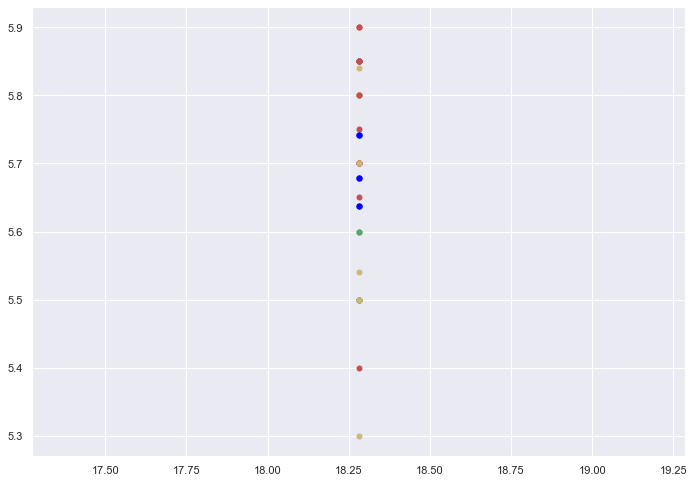

```python
# Liste des coleurs
colors = ["g.","r.", "y."]

# Grphique du nuage de points attribués au cluster correspondant
for i in range(len(df_boat_select)):
    plt.plot(df_boat_select.iloc[i,0], df_boat_select.iloc[i,1], colors[labels[i]], markersize = 10)

# Graphique des centroïdes
plt.scatter(centroids[:, 0],centroids[:, 1], marker = "o", color = "blue",s=30, linewidths = 1, zorder = 10)
plt.show()
```

#### Note :

**On constate que les centroïdes des 3 clusters sont très proches. On peut en déduire que les bâteaux ont des conceptions très similaires**

##### On évalue le modèle pour trouver le nombre optimal de cluster avec la méthode du coude (Elbow method)

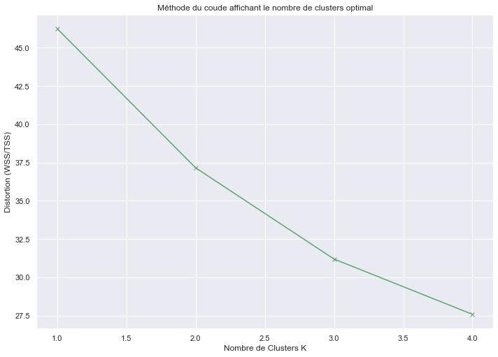

```python
# Importation de la fonction cdist du package scipy.spatial.distance
from scipy.spatial.distance import cdist

# Liste des nombre de clusters
#range_n_clusters = [2, 3, 4, 5, 6]
range_n_clusters = [1, 2, 3, 4]

# Initialisation de la liste de distortions
distortions = []

# Calcul des distortions pour les différents modèles
for n_clusters in range_n_clusters:

    # Initialisation d'un cluster ayant un pour nombre de clusters n_clusters
    cluster = KMeans(n_clusters = n_clusters)

    # Apprentissage des données suivant le cluster construit ci-dessus
    cluster.fit(df_boat_select)

    # Ajout de la nouvelle distortion à la liste des données
    distortions.append(sum(np.min(cdist(df_boat_select, cluster.cluster_centers_, 'euclidean'), axis=1)) / np.size(df_boat_select, axis = 0))


plt.plot(range_n_clusters, distortions, 'gx-')
plt.xlabel('Nombre de Clusters K')
plt.ylabel('Distortion (WSS/TSS)')
plt.title('Méthode du coude affichant le nombre de clusters optimal')
plt.show()
```

##### Au regard du résultat fournit par la méthode du coude on peut visualiser que le nombre cluster optimal est de 2 mais cela n'est pas flagrant.

#### On relance l'algorithme Kmeans avec comme paramètre n = 2

```python
kmeans_algo = KMeans(n_clusters=2)
kmeans_algo.fit_transform(df_boat_select)
y_kmeans = kmeans_algo.predict(df_boat_select)
```

```python
centroids = kmeans_algo.cluster_centers_
centroids
```

```
array([[1.82800000e+01, 5.73411765e+00, 4.50000000e+00, 8.25882353e+00,
        5.88235294e-01, 2.83411765e+01, 2.95882353e+02, 5.53529412e+02,
        1.38777878e-17, 6.47058824e-01, 5.88235294e-02, 1.76470588e-01,
        1.17647059e-01],
       [1.82800000e+01, 5.68437500e+00, 4.50000000e+00, 8.03125000e+00,
        5.00000000e-01, 2.84625000e+01, 3.06562500e+02, 6.24375000e+02,
        6.25000000e-02, 8.12500000e-01, 6.25000000e-02, 6.25000000e-02,
        2.77555756e-17]])
```

```python
labels = kmeans_algo.labels_
labels
```

```
array([0, 0, 0, 0, 1, 1, 1, 0, 0, 0, 0, 1, 1, 1, 1, 1, 0, 0, 0, 1, 1, 0,
       1, 1, 0, 0, 1, 0, 1, 1, 1, 0, 0])
```

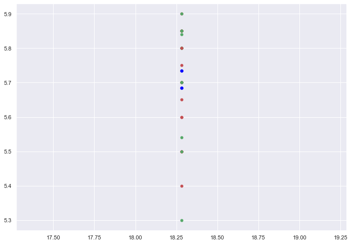

```python
# Liste des coleurs
colors = ["g.","r."]

# Grphique du nuage de points attribués au cluster correspondant
for i in range(len(df_boat_select)):
    plt.plot(df_boat_select.iloc[i,0], df_boat_select.iloc[i,1], colors[labels[i]], markersize = 10)

# Graphique des centroïdes
plt.scatter(centroids[:, 0],centroids[:, 1], marker = "o", color = "blue",s=30, linewidths = 1, zorder = 10)
plt.show()
```

### Application de l'algorithme Regression logistique

#### On souhaite connaitre quels sont les caractéristiques techniques du bâteau qui permettent à un bâteau d'arriver dans les 5 premiers de la course. Ainsi la regression logistique va donner un coefficient pour chacune des spécifités techniques du bâteau

**Note : On prendra comme variable cible la présence ou non du skipper dans les 5 premiers du classement final (Last_Rang_bin)**

```python
dfc_select_reg_log = df_merge_boat_carac_last_classement_cleaned.loc[df_merge_boat_carac_last_classement_cleaned.Last_Rang != 'RET', ['Last_Rang', 'Presence_foils', 'Longueur_m', 'Largeur_m', 'Tirant_eau_m', 'Deplacement_poids_tonnes', 'Hauteur_mat_m', 'Voile_quille', 'Surface_voiles_au_pres_m2', 'Surface_voiles_au_portant_m2']]
dfc_select_reg_log.Last_Rang = dfc_select.Last_Rang.astype(int)
dfc_select_reg_log
```

|  | Last_Rang | Presence_foils | Longueur_m | Largeur_m | Tirant_eau_m | Deplacement_poids_tonnes | Hauteur_mat_m | Voile_quille | Surface_voiles_au_pres_m2 | Surface_voiles_au_portant_m2 |
| --- | --- | --- | --- | --- | --- | --- | --- | --- | --- | --- |
| 1 | 14 | 0 | 18.28 | 5.80 | 4.5 | 9.0 | 28.0 | acier | 280.0 | 560.0 |
| 2 | 24 | 0 | 18.28 | 5.54 | 4.5 | 9.0 | 29.0 | acier | 260.0 | 580.0 |
| 3 | 1 | 1 | 18.28 | 5.80 | 4.5 | 8.0 | 29.0 | acier | 310.0 | 550.0 |
| 4 | 13 | 1 | 18.28 | 5.85 | 4.5 | 8.0 | 29.0 | acier | 320.0 | 600.0 |
| 5 | 15 | 1 | 18.28 | 5.65 | 4.5 | 7.9 | 29.0 | basculante avec vérin | 300.0 | 610.0 |
| 6 | 3 | 1 | 18.28 | 5.80 | 4.5 | 7.6 | 28.0 | acier | 300.0 | 600.0 |
| 7 | 20 | 0 | 18.28 | 5.30 | 4.5 | 8.9 | 26.0 | acier | 240.0 | 470.0 |
| 8 | 23 | 0 | 18.28 | 5.80 | 4.5 | 9.0 | 28.5 | basculante avec vérin | 270.0 | 560.0 |
| 9 | 12 | 0 | 18.28 | 5.70 | 4.5 | 7.7 | 29.0 | acier | 340.0 | 570.0 |
| 10 | 2 | 1 | 18.28 | 5.85 | 4.5 | 8.0 | 29.0 | acier | 350.0 | 560.0 |
| 13 | 9 | 0 | 18.28 | 5.85 | 4.5 | 8.0 | 29.0 | acier | 300.0 | 700.0 |
| 15 | 21 | 0 | 18.28 | 5.75 | 4.5 | 8.5 | 29.0 | acier | 300.0 | 620.0 |
| 16 | 19 | 0 | 18.28 | 5.70 | 4.5 | 9.0 | 29.0 | carbone | 300.0 | 580.0 |
| 17 | 5 | 1 | 18.28 | 5.70 | 4.5 | 7.6 | 29.0 | acier | 290.0 | 490.0 |
| 18 | 25 | 0 | 18.28 | 5.80 | 4.5 | 8.5 | 28.0 | acier | 270.0 | 580.0 |
| 20 | 4 | 0 | 18.28 | 5.90 | 4.5 | 8.0 | 28.0 | acier | 300.0 | 620.0 |
| 21 | 18 | 1 | 18.28 | 5.84 | 4.5 | 8.5 | 28.0 | monotype | 300.0 | 550.0 |
| 22 | 22 | 0 | 18.28 | 5.50 | 4.5 | 8.5 | 28.0 | carbone | 330.0 | 600.0 |
| 23 | 8 | 1 | 18.28 | 5.80 | 4.5 | 8.0 | 29.0 | acier | 300.0 | 600.0 |
| 24 | 17 | 1 | 18.28 | 5.90 | 4.5 | 8.5 | 27.0 | carbone | 290.0 | 580.0 |
| 25 | 6 | 1 | 18.28 | 5.85 | 4.5 | 8.0 | 29.0 | acier | 350.0 | 560.0 |
| 26 | 7 | 0 | 18.28 | 5.85 | 4.5 | 8.5 | 29.0 | acier | 350.0 | 610.0 |
| 27 | 16 | 1 | 18.28 | 5.85 | 4.5 | 8.0 | 29.0 | acier | 320.0 | 580.0 |
| 29 | 10 | 0 | 18.28 | 5.50 | 4.5 | 7.7 | 29.0 | acier | 365.0 | 700.0 |
| 31 | 11 | 1 | 18.28 | 5.50 | 4.5 | 7.8 | 28.0 | acier | 270.0 | 535.0 |

### One hot encoding de la variable Voile_quille

```python
# Get one hot encoding of columns "Voile_quille"
voile_quille_encoded = pd.get_dummies(dfc_select_reg_log.Voile_quille, prefix='Voile_quille')

# Drop column Voile_quille as it is now encoded
dfc_select_reg_log = dfc_select_reg_log.drop('Voile_quille', axis = 1)

# Join the encoded df
dfc_select_reg_log = dfc_select_reg_log.join(voile_quille_encoded)
dfc_select_reg_log
```

|  | Last_Rang | Presence_foils | Longueur_m | Largeur_m | Tirant_eau_m | Deplacement_poids_tonnes | Hauteur_mat_m | Surface_voiles_au_pres_m2 | Surface_voiles_au_portant_m2 | Voile_quille_acier | Voile_quille_basculante avec vérin | Voile_quille_carbone | Voile_quille_monotype |
| --- | --- | --- | --- | --- | --- | --- | --- | --- | --- | --- | --- | --- | --- |
| 1 | 14 | 0 | 18.28 | 5.80 | 4.5 | 9.0 | 28.0 | 280.0 | 560.0 | 1 | 0 | 0 | 0 |
| 2 | 24 | 0 | 18.28 | 5.54 | 4.5 | 9.0 | 29.0 | 260.0 | 580.0 | 1 | 0 | 0 | 0 |
| 3 | 1 | 1 | 18.28 | 5.80 | 4.5 | 8.0 | 29.0 | 310.0 | 550.0 | 1 | 0 | 0 | 0 |
| 4 | 13 | 1 | 18.28 | 5.85 | 4.5 | 8.0 | 29.0 | 320.0 | 600.0 | 1 | 0 | 0 | 0 |
| 5 | 15 | 1 | 18.28 | 5.65 | 4.5 | 7.9 | 29.0 | 300.0 | 610.0 | 0 | 1 | 0 | 0 |
| 6 | 3 | 1 | 18.28 | 5.80 | 4.5 | 7.6 | 28.0 | 300.0 | 600.0 | 1 | 0 | 0 | 0 |
| 7 | 20 | 0 | 18.28 | 5.30 | 4.5 | 8.9 | 26.0 | 240.0 | 470.0 | 1 | 0 | 0 | 0 |
| 8 | 23 | 0 | 18.28 | 5.80 | 4.5 | 9.0 | 28.5 | 270.0 | 560.0 | 0 | 1 | 0 | 0 |
| 9 | 12 | 0 | 18.28 | 5.70 | 4.5 | 7.7 | 29.0 | 340.0 | 570.0 | 1 | 0 | 0 | 0 |
| 10 | 2 | 1 | 18.28 | 5.85 | 4.5 | 8.0 | 29.0 | 350.0 | 560.0 | 1 | 0 | 0 | 0 |
| 13 | 9 | 0 | 18.28 | 5.85 | 4.5 | 8.0 | 29.0 | 300.0 | 700.0 | 1 | 0 | 0 | 0 |
| 15 | 21 | 0 | 18.28 | 5.75 | 4.5 | 8.5 | 29.0 | 300.0 | 620.0 | 1 | 0 | 0 | 0 |
| 16 | 19 | 0 | 18.28 | 5.70 | 4.5 | 9.0 | 29.0 | 300.0 | 580.0 | 0 | 0 | 1 | 0 |
| 17 | 5 | 1 | 18.28 | 5.70 | 4.5 | 7.6 | 29.0 | 290.0 | 490.0 | 1 | 0 | 0 | 0 |
| 18 | 25 | 0 | 18.28 | 5.80 | 4.5 | 8.5 | 28.0 | 270.0 | 580.0 | 1 | 0 | 0 | 0 |
| 20 | 4 | 0 | 18.28 | 5.90 | 4.5 | 8.0 | 28.0 | 300.0 | 620.0 | 1 | 0 | 0 | 0 |
| 21 | 18 | 1 | 18.28 | 5.84 | 4.5 | 8.5 | 28.0 | 300.0 | 550.0 | 0 | 0 | 0 | 1 |
| 22 | 22 | 0 | 18.28 | 5.50 | 4.5 | 8.5 | 28.0 | 330.0 | 600.0 | 0 | 0 | 1 | 0 |
| 23 | 8 | 1 | 18.28 | 5.80 | 4.5 | 8.0 | 29.0 | 300.0 | 600.0 | 1 | 0 | 0 | 0 |
| 24 | 17 | 1 | 18.28 | 5.90 | 4.5 | 8.5 | 27.0 | 290.0 | 580.0 | 0 | 0 | 1 | 0 |
| 25 | 6 | 1 | 18.28 | 5.85 | 4.5 | 8.0 | 29.0 | 350.0 | 560.0 | 1 | 0 | 0 | 0 |
| 26 | 7 | 0 | 18.28 | 5.85 | 4.5 | 8.5 | 29.0 | 350.0 | 610.0 | 1 | 0 | 0 | 0 |
| 27 | 16 | 1 | 18.28 | 5.85 | 4.5 | 8.0 | 29.0 | 320.0 | 580.0 | 1 | 0 | 0 | 0 |
| 29 | 10 | 0 | 18.28 | 5.50 | 4.5 | 7.7 | 29.0 | 365.0 | 700.0 | 1 | 0 | 0 | 0 |
| 31 | 11 | 1 | 18.28 | 5.50 | 4.5 | 7.8 | 28.0 | 270.0 | 535.0 | 1 | 0 | 0 | 0 |

### Ré-encodage de la variable "Last_Rang" en variable binaire

- Si le rang est strictement inférieur à 6 => "Last_Rang" = 1
- Sinon "Last_Rang = 0"
- On construit le DataFrame pour la regression logistique en sélectionnant les bonnes variables

```python
dfc_select_reg_log.loc[dfc_select_reg_log['Last_Rang'] < 6 , 'Last_Rang_bin'] = 1
dfc_select_reg_log.loc[dfc_select_reg_log['Last_Rang'] >= 6 , 'Last_Rang_bin'] = 0
dfc_select_reg_log['Last_Rang_bin'] = dfc_select_reg_log['Last_Rang_bin'].astype(int)
dfc_select_reg_log.drop("Last_Rang", axis=1, inplace=True)
dfc_select_reg_log
```

|  | Presence_foils | Longueur_m | Largeur_m | Tirant_eau_m | Deplacement_poids_tonnes | Hauteur_mat_m | Surface_voiles_au_pres_m2 | Surface_voiles_au_portant_m2 | Voile_quille_acier | Voile_quille_basculante avec vérin | Voile_quille_carbone | Voile_quille_monotype | Last_Rang_bin |
| --- | --- | --- | --- | --- | --- | --- | --- | --- | --- | --- | --- | --- | --- |
| 1 | 0 | 18.28 | 5.80 | 4.5 | 9.0 | 28.0 | 280.0 | 560.0 | 1 | 0 | 0 | 0 | 0 |
| 2 | 0 | 18.28 | 5.54 | 4.5 | 9.0 | 29.0 | 260.0 | 580.0 | 1 | 0 | 0 | 0 | 0 |
| 3 | 1 | 18.28 | 5.80 | 4.5 | 8.0 | 29.0 | 310.0 | 550.0 | 1 | 0 | 0 | 0 | 1 |
| 4 | 1 | 18.28 | 5.85 | 4.5 | 8.0 | 29.0 | 320.0 | 600.0 | 1 | 0 | 0 | 0 | 0 |
| 5 | 1 | 18.28 | 5.65 | 4.5 | 7.9 | 29.0 | 300.0 | 610.0 | 0 | 1 | 0 | 0 | 0 |
| 6 | 1 | 18.28 | 5.80 | 4.5 | 7.6 | 28.0 | 300.0 | 600.0 | 1 | 0 | 0 | 0 | 1 |
| 7 | 0 | 18.28 | 5.30 | 4.5 | 8.9 | 26.0 | 240.0 | 470.0 | 1 | 0 | 0 | 0 | 0 |
| 8 | 0 | 18.28 | 5.80 | 4.5 | 9.0 | 28.5 | 270.0 | 560.0 | 0 | 1 | 0 | 0 | 0 |
| 9 | 0 | 18.28 | 5.70 | 4.5 | 7.7 | 29.0 | 340.0 | 570.0 | 1 | 0 | 0 | 0 | 0 |
| 10 | 1 | 18.28 | 5.85 | 4.5 | 8.0 | 29.0 | 350.0 | 560.0 | 1 | 0 | 0 | 0 | 1 |
| 13 | 0 | 18.28 | 5.85 | 4.5 | 8.0 | 29.0 | 300.0 | 700.0 | 1 | 0 | 0 | 0 | 0 |
| 15 | 0 | 18.28 | 5.75 | 4.5 | 8.5 | 29.0 | 300.0 | 620.0 | 1 | 0 | 0 | 0 | 0 |
| 16 | 0 | 18.28 | 5.70 | 4.5 | 9.0 | 29.0 | 300.0 | 580.0 | 0 | 0 | 1 | 0 | 0 |
| 17 | 1 | 18.28 | 5.70 | 4.5 | 7.6 | 29.0 | 290.0 | 490.0 | 1 | 0 | 0 | 0 | 1 |
| 18 | 0 | 18.28 | 5.80 | 4.5 | 8.5 | 28.0 | 270.0 | 580.0 | 1 | 0 | 0 | 0 | 0 |
| 20 | 0 | 18.28 | 5.90 | 4.5 | 8.0 | 28.0 | 300.0 | 620.0 | 1 | 0 | 0 | 0 | 1 |
| 21 | 1 | 18.28 | 5.84 | 4.5 | 8.5 | 28.0 | 300.0 | 550.0 | 0 | 0 | 0 | 1 | 0 |
| 22 | 0 | 18.28 | 5.50 | 4.5 | 8.5 | 28.0 | 330.0 | 600.0 | 0 | 0 | 1 | 0 | 0 |
| 23 | 1 | 18.28 | 5.80 | 4.5 | 8.0 | 29.0 | 300.0 | 600.0 | 1 | 0 | 0 | 0 | 0 |
| 24 | 1 | 18.28 | 5.90 | 4.5 | 8.5 | 27.0 | 290.0 | 580.0 | 0 | 0 | 1 | 0 | 0 |
| 25 | 1 | 18.28 | 5.85 | 4.5 | 8.0 | 29.0 | 350.0 | 560.0 | 1 | 0 | 0 | 0 | 0 |
| 26 | 0 | 18.28 | 5.85 | 4.5 | 8.5 | 29.0 | 350.0 | 610.0 | 1 | 0 | 0 | 0 | 0 |
| 27 | 1 | 18.28 | 5.85 | 4.5 | 8.0 | 29.0 | 320.0 | 580.0 | 1 | 0 | 0 | 0 | 0 |
| 29 | 0 | 18.28 | 5.50 | 4.5 | 7.7 | 29.0 | 365.0 | 700.0 | 1 | 0 | 0 | 0 | 0 |
| 31 | 1 | 18.28 | 5.50 | 4.5 | 7.8 | 28.0 | 270.0 | 535.0 | 1 | 0 | 0 | 0 | 0 |

#### On standardise les variables continues car elles ont toutes des unités différentes

```python
columns = ["Longueur_m", "Largeur_m", "Tirant_eau_m", "Deplacement_poids_tonnes", "Hauteur_mat_m", "Surface_voiles_au_pres_m2", "Surface_voiles_au_portant_m2"]
for col in columns:
    dfc_select_reg_log[col] = (dfc_select_reg_log[col] - dfc_select_reg_log[col].mean())/dfc_select_reg_log[col].std()

dfc_select_reg_log
```

|  | Presence_foils | Longueur_m | Largeur_m | Tirant_eau_m | Deplacement_poids_tonnes | Hauteur_mat_m | Surface_voiles_au_pres_m2 | Surface_voiles_au_portant_m2 | Voile_quille_acier | Voile_quille_basculante avec vérin | Voile_quille_carbone | Voile_quille_monotype | Last_Rang_bin |
| --- | --- | --- | --- | --- | --- | --- | --- | --- | --- | --- | --- | --- | --- |
| 1 | 0 | 0.979796 | 0.418929 | NaN | 1.596871 | -0.654654 | -0.778622 | -0.448442 | 1 | 0 | 0 | 0 | 0 |
| 2 | 0 | 0.979796 | -1.261958 | NaN | 1.596871 | 0.654654 | -1.422112 | -0.051591 | 1 | 0 | 0 | 0 | 0 |
| 3 | 1 | 0.979796 | 0.418929 | NaN | -0.526628 | 0.654654 | 0.186612 | -0.646867 | 1 | 0 | 0 | 0 | 1 |
| 4 | 1 | 0.979796 | 0.742176 | NaN | -0.526628 | 0.654654 | 0.508357 | 0.345260 | 1 | 0 | 0 | 0 | 0 |
| 5 | 1 | 0.979796 | -0.550813 | NaN | -0.738977 | 0.654654 | -0.135133 | 0.543686 | 0 | 1 | 0 | 0 | 0 |
| 6 | 1 | 0.979796 | 0.418929 | NaN | -1.376027 | -0.654654 | -0.135133 | 0.345260 | 1 | 0 | 0 | 0 | 1 |
| 7 | 0 | 0.979796 | -2.813545 | NaN | 1.384521 | -3.273268 | -2.065601 | -2.234271 | 1 | 0 | 0 | 0 | 0 |
| 8 | 0 | 0.979796 | 0.418929 | NaN | 1.596871 | 0.000000 | -1.100367 | -0.448442 | 0 | 1 | 0 | 0 | 0 |
| 9 | 0 | 0.979796 | -0.227566 | NaN | -1.163677 | 0.654654 | 1.151846 | -0.250016 | 1 | 0 | 0 | 0 | 0 |
| 10 | 1 | 0.979796 | 0.742176 | NaN | -0.526628 | 0.654654 | 1.473591 | -0.448442 | 1 | 0 | 0 | 0 | 1 |
| 13 | 0 | 0.979796 | 0.742176 | NaN | -0.526628 | 0.654654 | -0.135133 | 2.329515 | 1 | 0 | 0 | 0 | 0 |
| 15 | 0 | 0.979796 | 0.095681 | NaN | 0.535122 | 0.654654 | -0.135133 | 0.742111 | 1 | 0 | 0 | 0 | 0 |
| 16 | 0 | 0.979796 | -0.227566 | NaN | 1.596871 | 0.654654 | -0.135133 | -0.051591 | 0 | 0 | 1 | 0 | 0 |
| 17 | 1 | 0.979796 | -0.227566 | NaN | -1.376027 | 0.654654 | -0.456878 | -1.837420 | 1 | 0 | 0 | 0 | 1 |
| 18 | 0 | 0.979796 | 0.418929 | NaN | 0.535122 | -0.654654 | -1.100367 | -0.051591 | 1 | 0 | 0 | 0 | 0 |
| 20 | 0 | 0.979796 | 1.065423 | NaN | -0.526628 | -0.654654 | -0.135133 | 0.742111 | 1 | 0 | 0 | 0 | 1 |
| 21 | 1 | 0.979796 | 0.677526 | NaN | 0.535122 | -0.654654 | -0.135133 | -0.646867 | 0 | 0 | 0 | 1 | 0 |
| 22 | 0 | 0.979796 | -1.520555 | NaN | 0.535122 | -0.654654 | 0.830101 | 0.345260 | 0 | 0 | 1 | 0 | 0 |
| 23 | 1 | 0.979796 | 0.418929 | NaN | -0.526628 | 0.654654 | -0.135133 | 0.345260 | 1 | 0 | 0 | 0 | 0 |
| 24 | 1 | 0.979796 | 1.065423 | NaN | 0.535122 | -1.963961 | -0.456878 | -0.051591 | 0 | 0 | 1 | 0 | 0 |
| 25 | 1 | 0.979796 | 0.742176 | NaN | -0.526628 | 0.654654 | 1.473591 | -0.448442 | 1 | 0 | 0 | 0 | 0 |
| 26 | 0 | 0.979796 | 0.742176 | NaN | 0.535122 | 0.654654 | 1.473591 | 0.543686 | 1 | 0 | 0 | 0 | 0 |
| 27 | 1 | 0.979796 | 0.742176 | NaN | -0.526628 | 0.654654 | 0.508357 | -0.051591 | 1 | 0 | 0 | 0 | 0 |
| 29 | 0 | 0.979796 | -1.520555 | NaN | -1.163677 | 0.654654 | 1.956208 | 2.329515 | 1 | 0 | 0 | 0 | 0 |
| 31 | 1 | 0.979796 | -1.520555 | NaN | -0.951327 | -0.654654 | -1.100367 | -0.944505 | 1 | 0 | 0 | 0 | 0 |

```python
# On retire les colonnes dont les valeurs sont NaN ou identiques
dfc_select_reg_log.drop("Longueur_m", axis=1, inplace=True)
dfc_select_reg_log.drop("Tirant_eau_m", axis=1, inplace=True)
```

```python
y = dfc_select_reg_log.iloc[:,-1]

# On drop la variable cible du DataFrame
dfc_select_reg_log.drop("Last_Rang_bin", axis=1, inplace=True)

X = dfc_select_reg_log
X
```

|  | Presence_foils | Largeur_m | Deplacement_poids_tonnes | Hauteur_mat_m | Surface_voiles_au_pres_m2 | Surface_voiles_au_portant_m2 | Voile_quille_acier | Voile_quille_basculante avec vérin | Voile_quille_carbone | Voile_quille_monotype |
| --- | --- | --- | --- | --- | --- | --- | --- | --- | --- | --- |
| 1 | 0 | 0.418929 | 1.596871 | -0.654654 | -0.778622 | -0.448442 | 1 | 0 | 0 | 0 |
| 2 | 0 | -1.261958 | 1.596871 | 0.654654 | -1.422112 | -0.051591 | 1 | 0 | 0 | 0 |
| 3 | 1 | 0.418929 | -0.526628 | 0.654654 | 0.186612 | -0.646867 | 1 | 0 | 0 | 0 |
| 4 | 1 | 0.742176 | -0.526628 | 0.654654 | 0.508357 | 0.345260 | 1 | 0 | 0 | 0 |
| 5 | 1 | -0.550813 | -0.738977 | 0.654654 | -0.135133 | 0.543686 | 0 | 1 | 0 | 0 |
| 6 | 1 | 0.418929 | -1.376027 | -0.654654 | -0.135133 | 0.345260 | 1 | 0 | 0 | 0 |
| 7 | 0 | -2.813545 | 1.384521 | -3.273268 | -2.065601 | -2.234271 | 1 | 0 | 0 | 0 |
| 8 | 0 | 0.418929 | 1.596871 | 0.000000 | -1.100367 | -0.448442 | 0 | 1 | 0 | 0 |
| 9 | 0 | -0.227566 | -1.163677 | 0.654654 | 1.151846 | -0.250016 | 1 | 0 | 0 | 0 |
| 10 | 1 | 0.742176 | -0.526628 | 0.654654 | 1.473591 | -0.448442 | 1 | 0 | 0 | 0 |
| 13 | 0 | 0.742176 | -0.526628 | 0.654654 | -0.135133 | 2.329515 | 1 | 0 | 0 | 0 |
| 15 | 0 | 0.095681 | 0.535122 | 0.654654 | -0.135133 | 0.742111 | 1 | 0 | 0 | 0 |
| 16 | 0 | -0.227566 | 1.596871 | 0.654654 | -0.135133 | -0.051591 | 0 | 0 | 1 | 0 |
| 17 | 1 | -0.227566 | -1.376027 | 0.654654 | -0.456878 | -1.837420 | 1 | 0 | 0 | 0 |
| 18 | 0 | 0.418929 | 0.535122 | -0.654654 | -1.100367 | -0.051591 | 1 | 0 | 0 | 0 |
| 20 | 0 | 1.065423 | -0.526628 | -0.654654 | -0.135133 | 0.742111 | 1 | 0 | 0 | 0 |
| 21 | 1 | 0.677526 | 0.535122 | -0.654654 | -0.135133 | -0.646867 | 0 | 0 | 0 | 1 |
| 22 | 0 | -1.520555 | 0.535122 | -0.654654 | 0.830101 | 0.345260 | 0 | 0 | 1 | 0 |
| 23 | 1 | 0.418929 | -0.526628 | 0.654654 | -0.135133 | 0.345260 | 1 | 0 | 0 | 0 |
| 24 | 1 | 1.065423 | 0.535122 | -1.963961 | -0.456878 | -0.051591 | 0 | 0 | 1 | 0 |
| 25 | 1 | 0.742176 | -0.526628 | 0.654654 | 1.473591 | -0.448442 | 1 | 0 | 0 | 0 |
| 26 | 0 | 0.742176 | 0.535122 | 0.654654 | 1.473591 | 0.543686 | 1 | 0 | 0 | 0 |
| 27 | 1 | 0.742176 | -0.526628 | 0.654654 | 0.508357 | -0.051591 | 1 | 0 | 0 | 0 |
| 29 | 0 | -1.520555 | -1.163677 | 0.654654 | 1.956208 | 2.329515 | 1 | 0 | 0 | 0 |
| 31 | 1 | -1.520555 | -0.951327 | -0.654654 | -1.100367 | -0.944505 | 1 | 0 | 0 | 0 |

### Application de la regression logistique avec la libraire sklearn

```python
from sklearn.model_selection import train_test_split



X_train, X_test, y_train, y_test = train_test_split(X, y)

modele_logit = LogisticRegression(penalty='none',solver='newton-cg')
modele_logit.fit(X_train, y_train)

pd.DataFrame(np.concatenate([modele_logit.intercept_.reshape(-1,1),
                             modele_logit.coef_],axis=1),
             index = ["coef"],
             columns = ["constante"]+list(X.columns)).T
```

|  | coef |
| --- | --- |
| constante | -27.084133 |
| Presence_foils | -12.562140 |
| Largeur_m | 30.567219 |
| Deplacement_poids_tonnes | -17.979867 |
| Hauteur_mat_m | -13.455106 |
| Surface_voiles_au_pres_m2 | 2.111426 |
| Surface_voiles_au_portant_m2 | -21.695530 |
| Voile_quille_acier | 3.459208 |
| Voile_quille_basculante avec vérin | -0.931381 |
| Voile_quille_carbone | -22.158921 |
| Voile_quille_monotype | -7.453039 |

#### Selon les résultats de la regression logistique, les coefficient des variables "Largeur_m", "Surface_voiles_au_pres_m2" et "Voile_quille_acier" sont positifs. Cela signifie que ces 3 paramètres possèdent une influence positive sur le fait d'être dans les 5 premiers du classement. On en déduit donc que les caractéristiques techniques "Largeur_m", "Surface_voiles_au_pres_m2" et "Voile_quille_acier", sont deux paramètres auxquels il est nécéssaire d'apporter un attention particulière lors de la conception du bâteau car si ces paramètres sont bien optimisés il permettront au skipper d'accrocher plus facilement les 5 premières places du classement ainsi obtenir un avantage par rapport aux bâteaux concurrents. Cependant, on remarque que la largeur du bâteau à une plus grande influence sur le fait d'être dans les 5 premiers du classement que les 2 autres paramètres dont le coefficient est positif. De plus, la regression logistique semble confirmer les résultats obtenu par le modèle de regression linéaire et le test de significativé sur la présence du foils car ici encore le coefficient de la variable "Presence_foils" et négatif ce qui signifie qu'il à un influence négative sur la variable cible (finir dans les 5 premiers). Ainsi cette caractéristique technique ne semble pas avoir d'influence sur l'obtention d'un bon classement.

### Evaluation du modèle de regression logistique

#### On affiche la matrice de confusion

```python
from sklearn.metrics import confusion_matrix
conf = confusion_matrix(y_test, modele_logit.predict(X_test))
conf
```

```
array([[5, 0],
       [1, 1]], dtype=int64)
```

```python
cf = pd.DataFrame(conf, columns=['prédit ' + str(_) for _ in modele_logit.classes_])
cf.index = ['vrai ' + str(_) for _ in modele_logit.classes_]
cf
```

|  | prédit 0 | prédit 1 |
| --- | --- | --- |
| vrai 0 | 5 | 0 |
| vrai 1 | 1 | 1 |

```python
score = modele_logit.decision_function(X_test)
dfsc = pd.DataFrame(score, columns=['score'])
dfsc['5 premiers'] = y_test.values
dfsc
```

|  | score | 5 premiers |
| --- | --- | --- |
| 0 | 2.391699 | 1 |
| 1 | -51.103797 | 0 |
| 2 | -38.584851 | 0 |
| 3 | -8.293187 | 1 |
| 4 | -55.515883 | 0 |
| 5 | -30.497255 | 0 |
| 6 | -22.637356 | 0 |